# I-SPY2 Radiogenomic Analysis

Exploring Molecular and Radiological Features of Treatment Response in Breast Cancer

## Study Rationale & Analysis Framework

This analysis integrates multi-modal data from the I-SPY2 trial to investigate molecular and radiological features associated with neoadjuvant treatment response in breast cancer, following the radiogenomic framework proposed by [Sun et al. (PMID: 30120041)](https://pubmed.ncbi.nlm.nih.gov/30120041/).

### Data Modalities

- **Genomics:** Microarray expression profiling (Agilent 44K) for 987 patients
- **Radiomics:** MRI-derived tumor features from 985 patients using DCE-MRI across four timepoints (T0–T3)
- **Matched cohort:** 982 patients with both genomic and radiomic data

### Analysis Pipeline

**Phase 1: Genomics (Complete)**

1. Preprocess expression data, filter to 17,547 protein-coding genes
2. Differential expression analysis (R vs NR) — full cohort and per treatment
3. Pathway enrichment (GSEA + ORA) using Hallmark and KEGG gene sets
4. Gene–response correlation (DE hits, PredictIO signatures, immune/luminal markers)
5. Stratified signature analysis by treatment arm

**Key Genomic Findings:**

- **IO+Chemo (69 patients, 47 DE genes):**
  - Responders: immune-hot — LAMP3, CCL13, IDO1, CRABP1, CHI3L2, CXCL13, CXCL9, MARCO, UBD, KRT5
  - Non-responders: hormone-driven — CA12, AGR2, FOXA1, AR, ACOX2, GATA3, TFF1, TFF3, SCUBE2, MSMB
  - Pathways up in responders: interferon gamma, allograft rejection, interferon alpha, IL6/JAK/STAT3, E2F, G2M
  - Pathways up in non-responders: estrogen response early/late, EMT, myogenesis
- **Targeted (52 patients, 3 DE genes):**
  - Responders: GRB7, MNX1, PNMT (GRB7 is HER2-associated, co-amplified with ERBB2)
  - Pathways up in responders: mTORC1 signaling, interferon gamma, inflammatory response, glycolysis, hypoxia
  - Pathways up in non-responders: estrogen response early/late, WNT/beta-catenin, EMT
- **Chemo (179 patients):** 0 DE genes — no signal
- **Chemo+Targeted (687 patients):** 4,152 FDR significant genes but only 1 with high fold change: AGR3
- **Across all arms:** Estrogen-driven tumors resist treatment regardless of type

**Phase 2: Radiomics (In Progress)**

**Phase 3: Radiogenomic Integration (Planned)**

Following [Sun et al. (PMID: 30120041)](https://pubmed.ncbi.nlm.nih.gov/30120041/), who linked CT radiomic features to CD8 cell infiltration using machine learning, we extend this approach to breast cancer MRI with multi-arm treatment stratification and longitudinal imaging.

1. **Correlation analysis:** radiomic features vs gene expression features, subset by feature class and treatment/receptor
2. **Unsupervised linking:** explore whether MRI features can distinguish immune-hot vs immune-cold tumors
3. **Predictive signatures:** build combined radiogenomic signature, test if it predicts treatment response
4. **Optional — FMCIB:** deep learning radiomics feature extraction

### Key Question

Can radiomics predict tumor shrinkage or immune phenotype better than genomics alone — or does combining both improve prediction?

## Overview

### Dataset Summary

- **Study Reference**: [PMID: 35623341](https://pubmed.ncbi.nlm.nih.gov/35623341/)
- **Clinical Trial**: [ISPY2/NCT01042379](https://clinicaltrials.gov/study/NCT01042379)
- **Data Source**: [GEO: GSE194040](https://www.ncbi.nlm.nih.gov/geo/query/acc.cgi?acc=GSE194040)
- **Study Population**:
  - **Genomics Data**: 987 patients (mRNA & RPPA profiling)
  - **Radiomics Data**: 985 patients (MRI scans)
- **Platforms Used**:
  - **Genomics**: Agilent 44K arrays
  - **Radiomics**: MRI (DCE-MRI)

#### Treatment Details

- **Total Patients (Microarray)**: 987
- **Total Patients (MRI)**: 985 (719 I-SPY2 cases, 266 ACRIN-6698 cases)
- **Treatment Groups**:
  - **IO + Chemo**: 69 patients
  - **Chemo + Targeted Therapy**: 687 patients
  - **Chemo Alone**: 179 patients
  - **Targeted Therapy Alone**: 52 patients
- **Key Treatment Arms**:
  - Paclitaxel ± Trastuzumab
  - Veliparib + Carboplatin
  - AMG-386 (Trebananib) ± Trastuzumab
  - Neratinib, Ganetespib, Ganitumab, Pembrolizumab, Pertuzumab, T-DM1

#### Additional Information

- **Batch Correction**:
  - **ComBat** was applied to correct batch effects in gene expression data.
  - Adjusted ~800 patients; linear adjustments applied to remaining cases.
- **Radiomics Data**:
  - MRI dataset includes **4 serial DCE-MRI scans per patient**.
  - Performed **before and during neoadjuvant chemotherapy** to track tumor volume changes and response.
- **Data Availability**:
  - Genomics: Available in [GEO: GSE194040](https://www.ncbi.nlm.nih.gov/geo/query/acc.cgi?acc=GSE194040).
  - Imaging: MRI datasets accessible via [The Cancer Imaging Archive (ISPY2 Collection)](https://www.cancerimagingarchive.net/collection/ispy2/).
- **Key Reference**:
  - Wolf DM et al., *Cancer Cell*, 2022. [PMID: 35623341](https://pubmed.ncbi.nlm.nih.gov/35623341).

## Section 1: Data Processing

### Load Libraries

```r
library(here)
library(MultiAssayExperiment)
library(knitr)
library(readxl)
library(ggplot2)
library(dplyr)
library(tidyr)
library(ggvenn)
library(kableExtra)
library(limma)
library(EnhancedVolcano)
library(msigdbr)
library(fgsea)
library(patchwork)
library(stringr)
library(pheatmap)
library(stringr)
```

### Load Genomics Data

Load MultiAssayExperiment `.rds` File. This step extracts **clinical, expression (Microarray quantile normalized), and annotation data** for further analysis.

```r
# Define base directory
input_dir <- file.path(here(), "data/rawdata/genomics")
output_dir <- file.path(here(), "data/results/genomics")
dir.create(file.path(output_dir, "DEG_analysis"), recursive = TRUE, showWarnings = FALSE)
dir.create(file.path(output_dir, "pathway_analysis"), recursive = TRUE, showWarnings = FALSE)
dir.create(file.path(here(), "data/results/radiogenomics"), recursive = TRUE, showWarnings = FALSE)

# Load dataset
mae <- readRDS(file.path(input_dir, "ICB_Wolf.rds"))

# Extract clinical, expression, and annotation data
clin <- data.frame(colData(mae))
expr <- assays(mae)[["expr"]] # dim 18348 x 987
annot <- data.frame(rowData(mae@ExperimentList$expr))

# Create a named vector to map gene_id to gene_name
gene_map <- setNames(annot$gene_name, annot$gene_id)
rownames(expr) <- gene_map[rownames(expr)]
rownames(annot) <- annot$gene_name
```

#### Clinical Data

Display first 50 rows of Clinical Data.

```r
kable(head(clin, 50), caption = "Genomics Clinical Data") %>%
  kable_styling(bootstrap_options = c("striped", "hover", "condensed"), full_width = FALSE) %>%
  scroll_box(height = "400px")
```

Genomics Clinical Data

|  | patientid | sex | age | cancer_type | histo | tissueid | stage | response.other.info | recist | response | treatment | dna | rna | survival_time_pfs | event_occurred_pfs | survival_time_os | event_occurred_os | survival_unit | survival_type | TMB_raw | nsTMB_raw | indel_TMB_raw | indel_nsTMB_raw | TMB_perMb | nsTMB_perMb | indel_TMB_perMb | indel_nsTMB_perMb | CIN | CNA_tot | … |
| --- | --- | --- | --- | --- | --- | --- | --- | --- | --- | --- | --- | --- | --- | --- | --- | --- | --- | --- | --- | --- | --- | --- | --- | --- | --- | --- | --- | --- | --- | --- |
| X100899 | X100899 | F | NA | Breast | NA | Breast | NA | NR | NA | NR | chemo+targeted | NA | microarray | NA | NA | NA | NA | NA | None | NA | NA | NA | NA | NA | NA | NA | NA | NA | NA | … |
| X102011 | X102011 | F | NA | Breast | NA | Breast | NA | NR | NA | NR | chemo+targeted | NA | microarray | NA | NA | NA | NA | NA | None | NA | NA | NA | NA | NA | NA | NA | NA | NA | NA | … |
| X102212 | X102212 | F | NA | Breast | NA | Breast | NA | NR | NA | NR | chemo+targeted | NA | microarray | NA | NA | NA | NA | NA | None | NA | NA | NA | NA | NA | NA | NA | NA | NA | NA | … |
| X103693 | X103693 | F | NA | Breast | NA | Breast | NA | NR | NA | NR | IO+chemo | NA | microarray | NA | NA | NA | NA | NA | None | NA | NA | NA | NA | NA | NA | NA | NA | NA | NA | … |
| X103939 | X103939 | F | NA | Breast | NA | Breast | NA | NR | NA | NR | chemo | NA | microarray | NA | NA | NA | NA | NA | None | NA | NA | NA | NA | NA | NA | NA | NA | NA | NA | … |
| X104268 | X104268 | F | NA | Breast | NA | Breast | NA | NR | NA | NR | chemo | NA | microarray | NA | NA | NA | NA | NA | None | NA | NA | NA | NA | NA | NA | NA | NA | NA | NA | … |
| X104384 | X104384 | F | NA | Breast | NA | Breast | NA | NR | NA | NR | IO+chemo | NA | microarray | NA | NA | NA | NA | NA | None | NA | NA | NA | NA | NA | NA | NA | NA | NA | NA | … |
| X105286 | X105286 | F | NA | Breast | NA | Breast | NA | NR | NA | NR | chemo+targeted | NA | microarray | NA | NA | NA | NA | NA | None | NA | NA | NA | NA | NA | NA | NA | NA | NA | NA | … |
| X105513 | X105513 | F | NA | Breast | NA | Breast | NA | R | NA | R | chemo+targeted | NA | microarray | NA | NA | NA | NA | NA | None | NA | NA | NA | NA | NA | NA | NA | NA | NA | NA | … |
| X107700 | X107700 | F | NA | Breast | NA | Breast | NA | NR | NA | NR | chemo+targeted | NA | microarray | NA | NA | NA | NA | NA | None | NA | NA | NA | NA | NA | NA | NA | NA | NA | NA | … |
| X108939 | X108939 | F | NA | Breast | NA | Breast | NA | R | NA | R | chemo+targeted | NA | microarray | NA | NA | NA | NA | NA | None | NA | NA | NA | NA | NA | NA | NA | NA | NA | NA | … |
| X108969 | X108969 | F | NA | Breast | NA | Breast | NA | R | NA | R | chemo+targeted | NA | microarray | NA | NA | NA | NA | NA | None | NA | NA | NA | NA | NA | NA | NA | NA | NA | NA | … |
| X109623 | X109623 | F | NA | Breast | NA | Breast | NA | NR | NA | NR | chemo+targeted | NA | microarray | NA | NA | NA | NA | NA | None | NA | NA | NA | NA | NA | NA | NA | NA | NA | NA | … |
| X109874 | X109874 | F | NA | Breast | NA | Breast | NA | R | NA | R | chemo+targeted | NA | microarray | NA | NA | NA | NA | NA | None | NA | NA | NA | NA | NA | NA | NA | NA | NA | NA | … |
| X109980 | X109980 | F | NA | Breast | NA | Breast | NA | R | NA | R | chemo+targeted | NA | microarray | NA | NA | NA | NA | NA | None | NA | NA | NA | NA | NA | NA | NA | NA | NA | NA | … |
| X111004 | X111004 | F | NA | Breast | NA | Breast | NA | NR | NA | NR | IO+chemo | NA | microarray | NA | NA | NA | NA | NA | None | NA | NA | NA | NA | NA | NA | NA | NA | NA | NA | … |
| X111038 | X111038 | F | NA | Breast | NA | Breast | NA | NR | NA | NR | chemo+targeted | NA | microarray | NA | NA | NA | NA | NA | None | NA | NA | NA | NA | NA | NA | NA | NA | NA | NA | … |
| X111344 | X111344 | F | NA | Breast | NA | Breast | NA | NR | NA | NR | chemo+targeted | NA | microarray | NA | NA | NA | NA | NA | None | NA | NA | NA | NA | NA | NA | NA | NA | NA | NA | … |
| X111646 | X111646 | F | NA | Breast | NA | Breast | NA | NR | NA | NR | chemo+targeted | NA | microarray | NA | NA | NA | NA | NA | None | NA | NA | NA | NA | NA | NA | NA | NA | NA | NA | … |
| X111674 | X111674 | F | NA | Breast | NA | Breast | NA | R | NA | R | chemo+targeted | NA | microarray | NA | NA | NA | NA | NA | None | NA | NA | NA | NA | NA | NA | NA | NA | NA | NA | … |
| X111881 | X111881 | F | NA | Breast | NA | Breast | NA | R | NA | R | chemo+targeted | NA | microarray | NA | NA | NA | NA | NA | None | NA | NA | NA | NA | NA | NA | NA | NA | NA | NA | … |
| X112606 | X112606 | F | NA | Breast | NA | Breast | NA | NR | NA | NR | chemo+targeted | NA | microarray | NA | NA | NA | NA | NA | None | NA | NA | NA | NA | NA | NA | NA | NA | NA | NA | … |
| X114087 | X114087 | F | NA | Breast | NA | Breast | NA | NR | NA | NR | IO+chemo | NA | microarray | NA | NA | NA | NA | NA | None | NA | NA | NA | NA | NA | NA | NA | NA | NA | NA | … |
| X115638 | X115638 | F | NA | Breast | NA | Breast | NA | NR | NA | NR | chemo+targeted | NA | microarray | NA | NA | NA | NA | NA | None | NA | NA | NA | NA | NA | NA | NA | NA | NA | NA | … |
| X115987 | X115987 | F | NA | Breast | NA | Breast | NA | NR | NA | NR | chemo+targeted | NA | microarray | NA | NA | NA | NA | NA | None | NA | NA | NA | NA | NA | NA | NA | NA | NA | NA | … |
| X116165 | X116165 | F | NA | Breast | NA | Breast | NA | NR | NA | NR | IO+chemo | NA | microarray | NA | NA | NA | NA | NA | None | NA | NA | NA | NA | NA | NA | NA | NA | NA | NA | … |
| X116603 | X116603 | F | NA | Breast | NA | Breast | NA | NR | NA | NR | chemo | NA | microarray | NA | NA | NA | NA | NA | None | NA | NA | NA | NA | NA | NA | NA | NA | NA | NA | … |
| X117424 | X117424 | F | NA | Breast | NA | Breast | NA | R | NA | R | chemo+targeted | NA | microarray | NA | NA | NA | NA | NA | None | NA | NA | NA | NA | NA | NA | NA | NA | NA | NA | … |
| X117707 | X117707 | F | NA | Breast | NA | Breast | NA | R | NA | R | chemo+targeted | NA | microarray | NA | NA | NA | NA | NA | None | NA | NA | NA | NA | NA | NA | NA | NA | NA | NA | … |
| X118307 | X118307 | F | NA | Breast | NA | Breast | NA | NR | NA | NR | chemo+targeted | NA | microarray | NA | NA | NA | NA | NA | None | NA | NA | NA | NA | NA | NA | NA | NA | NA | NA | … |
| X119928 | X119928 | F | NA | Breast | NA | Breast | NA | NR | NA | NR | chemo+targeted | NA | microarray | NA | NA | NA | NA | NA | None | NA | NA | NA | NA | NA | NA | NA | NA | NA | NA | … |
| X120001 | X120001 | F | NA | Breast | NA | Breast | NA | NR | NA | NR | chemo+targeted | NA | microarray | NA | NA | NA | NA | NA | None | NA | NA | NA | NA | NA | NA | NA | NA | NA | NA | … |
| X120422 | X120422 | F | NA | Breast | NA | Breast | NA | R | NA | R | chemo+targeted | NA | microarray | NA | NA | NA | NA | NA | None | NA | NA | NA | NA | NA | NA | NA | NA | NA | NA | … |
| X122287 | X122287 | F | NA | Breast | NA | Breast | NA | R | NA | R | targeted | NA | microarray | NA | NA | NA | NA | NA | None | NA | NA | NA | NA | NA | NA | NA | NA | NA | NA | … |
| X122579 | X122579 | F | NA | Breast | NA | Breast | NA | NR | NA | NR | chemo | NA | microarray | NA | NA | NA | NA | NA | None | NA | NA | NA | NA | NA | NA | NA | NA | NA | NA | … |
| X122795 | X122795 | F | NA | Breast | NA | Breast | NA | NR | NA | NR | chemo+targeted | NA | microarray | NA | NA | NA | NA | NA | None | NA | NA | NA | NA | NA | NA | NA | NA | NA | NA | … |
| X123660 | X123660 | F | NA | Breast | NA | Breast | NA | NR | NA | NR | chemo+targeted | NA | microarray | NA | NA | NA | NA | NA | None | NA | NA | NA | NA | NA | NA | NA | NA | NA | NA | … |
| X125130 | X125130 | F | NA | Breast | NA | Breast | NA | R | NA | R | targeted | NA | microarray | NA | NA | NA | NA | NA | None | NA | NA | NA | NA | NA | NA | NA | NA | NA | NA | … |
| X125385 | X125385 | F | NA | Breast | NA | Breast | NA | NR | NA | NR | chemo+targeted | NA | microarray | NA | NA | NA | NA | NA | None | NA | NA | NA | NA | NA | NA | NA | NA | NA | NA | … |
| X125418 | X125418 | F | NA | Breast | NA | Breast | NA | NR | NA | NR | chemo+targeted | NA | microarray | NA | NA | NA | NA | NA | None | NA | NA | NA | NA | NA | NA | NA | NA | NA | NA | … |
| X127675 | X127675 | F | NA | Breast | NA | Breast | NA | NR | NA | NR | chemo+targeted | NA | microarray | NA | NA | NA | NA | NA | None | NA | NA | NA | NA | NA | NA | NA | NA | NA | NA | … |
| X127791 | X127791 | F | NA | Breast | NA | Breast | NA | NR | NA | NR | chemo+targeted | NA | microarray | NA | NA | NA | NA | NA | None | NA | NA | NA | NA | NA | NA | NA | NA | NA | NA | … |
| X128051 | X128051 | F | NA | Breast | NA | Breast | NA | NR | NA | NR | targeted | NA | microarray | NA | NA | NA | NA | NA | None | NA | NA | NA | NA | NA | NA | NA | NA | NA | NA | … |
| X128675 | X128675 | F | NA | Breast | NA | Breast | NA | R | NA | R | chemo | NA | microarray | NA | NA | NA | NA | NA | None | NA | NA | NA | NA | NA | NA | NA | NA | NA | NA | … |
| X129837 | X129837 | F | NA | Breast | NA | Breast | NA | NR | NA | NR | chemo+targeted | NA | microarray | NA | NA | NA | NA | NA | None | NA | NA | NA | NA | NA | NA | NA | NA | NA | NA | … |
| X129973 | X129973 | F | NA | Breast | NA | Breast | NA | R | NA | R | chemo+targeted | NA | microarray | NA | NA | NA | NA | NA | None | NA | NA | NA | NA | NA | NA | NA | NA | NA | NA | … |
| X130580 | X130580 | F | NA | Breast | NA | Breast | NA | R | NA | R | chemo+targeted | NA | microarray | NA | NA | NA | NA | NA | None | NA | NA | NA | NA | NA | NA | NA | NA | NA | NA | … |
| X130892 | X130892 | F | NA | Breast | NA | Breast | NA | R | NA | R | chemo+targeted | NA | microarray | NA | NA | NA | NA | NA | None | NA | NA | NA | NA | NA | NA | NA | NA | NA | NA | … |
| X131595 | X131595 | F | NA | Breast | NA | Breast | NA | NR | NA | NR | chemo+targeted | NA | microarray | NA | NA | NA | NA | NA | None | NA | NA | NA | NA | NA | NA | NA | NA | NA | NA | … |
| X131961 | X131961 | F | NA | Breast | NA | Breast | NA | R | NA | R | targeted | NA | microarray | NA | NA | NA | NA | NA | None | NA | NA | NA | NA | NA | NA | NA | NA | NA | NA | … |

#### Microarray Expression Data

Display first 20 rows of quantile-normalized Microarray data.

```r
kable(head(expr, 20), caption = "Expression Data - Microarray") %>%
  kable_styling(bootstrap_options = c("striped", "hover", "condensed"), full_width = FALSE) %>%
  scroll_box(height = "400px")
```

Expression Data - Microarray

|  | X756412 | X111881 | X451816 | X243836 | X402265 | X611662 | X139137 | X685753 | X627981 | X108939 | X629210 | X809037 | X107700 | X373672 | X615873 | X607047 | X155171 | X815421 | X605713 | X246134 | X373346 | X349225 | X208265 | X395076 | X637752 | X331192 | X327133 | X541165 | X802778 | … |
| --- | --- | --- | --- | --- | --- | --- | --- | --- | --- | --- | --- | --- | --- | --- | --- | --- | --- | --- | --- | --- | --- | --- | --- | --- | --- | --- | --- | --- | --- | --- |
| TSPAN6 | 9.2058 | 7.5586 | 7.0909 | 8.8402 | 8.7008 | 8.3078 | 8.8128 | 9.2206 | 9.1506 | 8.9980 | 8.2162 | 10.2200 | 9.5105 | 10.2290 | 10.4370 | 7.4639 | 7.6933 | 9.8551 | 8.2288 | 8.3604 | 9.0722 | 9.4142 | 10.5580 | 9.1585 | 10.4630 | 8.8212 | 9.6225 | 10.0520 | 10.1200 | … |
| TNMD | 4.6488 | 4.2792 | 5.0983 | 5.0612 | 5.4898 | 6.0632 | 5.2203 | 4.8097 | 5.3536 | 5.7317 | 6.4832 | 5.5584 | 5.7346 | 6.1384 | 4.8078 | 5.3155 | 5.0107 | 6.2699 | 5.2936 | 6.1975 | 6.0003 | 5.6974 | 6.0879 | 5.2412 | 5.2831 | 5.6022 | 7.5804 | 5.2450 | 7.4099 | … |
| DPM1 | 12.2580 | 12.8160 | 12.7220 | 12.9750 | 12.5100 | 12.2510 | 13.2410 | 13.0880 | 12.4680 | 12.7430 | 12.6220 | 12.4200 | 13.1130 | 12.5510 | 13.6830 | 13.3890 | 12.6320 | 12.7200 | 11.9500 | 14.6470 | 12.1190 | 13.2860 | 12.4690 | 13.5980 | 12.4700 | 12.6610 | 13.7830 | 12.8110 | 12.7600 | … |
| SCYL3 | 9.9888 | 9.1309 | 8.7602 | 8.7112 | 9.0070 | 9.1536 | 9.4303 | 8.9822 | 9.1918 | 9.6543 | 10.0240 | 9.0751 | 9.5598 | 8.9032 | 9.8458 | 9.1004 | 9.6791 | 8.7184 | 8.5140 | 9.0307 | 9.9165 | 9.8148 | 10.2560 | 9.0963 | 8.8500 | 9.5748 | 10.0600 | 8.6079 | 9.9578 | … |
| C1orf112 | 9.2978 | 8.5738 | 8.7915 | 9.1821 | 9.3634 | 8.7342 | 10.3220 | 8.5519 | 8.8915 | 9.0009 | 8.7092 | 9.3957 | 9.3717 | 9.2186 | 10.1070 | 8.4748 | 9.1571 | 8.7675 | 8.0634 | 9.3009 | 9.1832 | 10.4880 | 10.2870 | 10.2980 | 9.1519 | 10.7220 | 10.8870 | 9.2676 | 9.5905 | … |
| FGR | 7.5326 | 8.0202 | 8.0026 | 8.5236 | 9.4199 | 10.9400 | 9.6857 | 9.0358 | 9.6069 | 9.2721 | 9.4824 | 8.6305 | 9.4001 | 10.2890 | 8.2569 | 8.2340 | 8.0743 | 10.0870 | 8.9420 | 9.2602 | 8.6353 | 9.1871 | 9.4652 | 8.5363 | 7.9555 | 10.6620 | 8.9812 | 9.2474 | 10.0090 | … |
| CFH | 8.7210 | 8.3135 | 8.3359 | 9.2180 | 9.9531 | 9.8552 | 8.0946 | 10.3120 | 9.7288 | 9.8100 | 9.2622 | 10.0230 | 9.3781 | 9.4571 | 8.8261 | 9.8697 | 7.1231 | 9.9766 | 8.6246 | 9.7201 | 9.8368 | 9.5647 | 8.6015 | 9.1959 | 9.1383 | 8.6105 | 9.3390 | 8.5232 | 9.9726 | … |
| FUCA2 | 7.6301 | 8.9642 | 8.6309 | 8.8627 | 9.2936 | 8.2908 | 8.3179 | 8.7120 | 8.9429 | 9.1071 | 9.8461 | 8.9072 | 9.5534 | 8.8337 | 8.7893 | 8.3913 | 9.4626 | 9.0298 | 9.4713 | 8.9584 | 9.2984 | 8.5613 | 9.1216 | 8.5536 | 9.0762 | 8.9033 | 10.1280 | 9.1390 | 8.2937 | … |
| GCLC | 8.8570 | 8.6128 | 8.5548 | 7.7268 | 8.5620 | 8.8988 | 8.7354 | 9.7240 | 8.8308 | 9.2774 | 9.0616 | 9.1999 | 9.5483 | 9.4987 | 8.6351 | 8.3284 | 8.6568 | 9.1302 | 9.1084 | 9.4045 | 8.6038 | 8.8519 | 9.3850 | 9.1129 | 8.6373 | 9.2417 | 8.7020 | 8.4115 | 9.3030 | … |
| NFYA | 7.5652 | 7.6406 | 8.0892 | 8.5125 | 8.2673 | 8.0805 | 7.7398 | 7.5644 | 8.2209 | 7.9051 | 8.3292 | 7.8130 | 8.4661 | 8.1605 | 7.2901 | 7.6342 | 7.8300 | 8.6415 | 8.2575 | 7.9968 | 8.1488 | 8.7864 | 8.5363 | 8.8060 | 8.1496 | 8.4612 | 9.4255 | 8.5087 | 8.5495 | … |
| STPG1 | 8.2748 | 8.0578 | 8.0821 | 7.6324 | 8.0831 | 8.0889 | 6.2686 | 7.6557 | 7.1719 | 7.6888 | 8.2680 | 8.5717 | 8.4325 | 8.4316 | 8.0286 | 7.5983 | 8.5591 | 8.4549 | 8.2164 | 8.5493 | 8.1016 | 8.7090 | 8.9465 | 8.8472 | 7.8718 | 9.1694 | 7.7054 | 8.5902 | 8.9631 | … |
| NIPAL3 | 6.9615 | 7.3208 | 7.5856 | 7.2215 | 7.8767 | 7.9375 | 6.9534 | 7.0362 | 7.8405 | 7.3266 | 8.6462 | 7.9910 | 7.9778 | 8.4041 | 6.9260 | 7.4698 | 7.9111 | 7.9884 | 8.2441 | 8.1137 | 7.6105 | 8.0565 | 7.4878 | 7.6852 | 8.0628 | 8.3920 | 7.3266 | 7.8123 | 8.7718 | … |
| LAS1L | 12.4860 | 12.4020 | 12.1390 | 12.2450 | 12.2250 | 12.3380 | 12.1710 | 11.7540 | 12.3760 | 11.9090 | 12.7520 | 12.3670 | 11.9690 | 12.0230 | 12.0800 | 12.3010 | 12.1020 | 11.5150 | 12.1520 | 13.7310 | 12.7810 | 12.2580 | 12.4800 | 11.9000 | 12.2130 | 13.2720 | 12.0220 | 12.3520 | 12.6880 | … |
| ENPP4 | 9.9619 | 8.2837 | 10.3630 | 9.0396 | 9.3834 | 9.5861 | 11.5330 | 8.5668 | 8.2330 | 8.4611 | 8.6374 | 10.7920 | 8.6836 | 9.4660 | 9.1542 | 10.1580 | 11.2050 | 10.1970 | 9.5509 | 9.8792 | 9.4958 | 9.5244 | 9.6544 | 10.9470 | 9.4969 | 9.4054 | 10.6100 | 9.1057 | 10.0640 | … |
| SEMA3F | 8.2284 | 7.3826 | 9.6703 | 7.2874 | 8.5348 | 6.7404 | 7.9285 | 7.0881 | 7.7268 | 7.6107 | 8.0332 | 7.5197 | 7.8423 | 7.4957 | 6.7541 | 6.9762 | 8.4864 | 7.2402 | 8.8658 | 7.8243 | 7.8196 | 6.6183 | 7.3359 | 6.0772 | 6.6213 | 6.9529 | 6.5375 | 8.0488 | 8.4911 | … |
| CFTR | 4.0713 | 4.0962 | 4.8268 | 4.9354 | 5.3265 | 5.6654 | 5.1613 | 4.6548 | 5.3867 | 6.0285 | 6.8503 | 5.7076 | 5.4804 | 6.5983 | 6.3916 | 4.3960 | 4.8982 | 6.2166 | 5.2842 | 6.1477 | 5.9788 | 5.7926 | 6.0577 | 5.3842 | 4.9025 | 5.6765 | 5.5462 | 5.2197 | 7.4009 | … |
| ANKIB1 | 7.9097 | 7.9659 | 8.8805 | 8.9959 | 8.3236 | 8.0768 | 8.2322 | 8.7116 | 8.5584 | 7.9947 | 8.7798 | 9.0457 | 8.2037 | 8.8229 | 7.8828 | 8.3584 | 8.2547 | 8.4082 | 8.1865 | 8.2652 | 8.5127 | 8.1479 | 8.1839 | 9.0873 | 8.8401 | 8.4270 | 9.3637 | 8.1663 | 8.7719 | … |
| CYP51A1 | 9.9704 | 9.9086 | 10.3710 | 10.8150 | 9.5464 | 9.2960 | 11.0760 | 10.7000 | 11.4010 | 9.5541 | 10.5390 | 10.2800 | 10.1020 | 10.3940 | 9.4959 | 10.0950 | 10.3890 | 10.7610 | 10.6260 | 9.9818 | 10.1660 | 10.9120 | 11.4850 | 10.8260 | 9.8355 | 9.7623 | 10.6810 | 10.9060 | 9.8669 | … |
| KRIT1 | 5.5416 | 5.1471 | 5.9670 | 5.6125 | 5.8544 | 6.1310 | 5.9321 | 5.6955 | 6.0890 | 5.8235 | 6.6173 | 6.2715 | 5.7987 | 6.5255 | 5.3326 | 5.5211 | 5.7116 | 6.2849 | 5.6747 | 6.2244 | 6.1885 | 6.0352 | 5.9220 | 6.0823 | 5.9102 | 6.1710 | 6.3676 | 5.9653 | 7.0460 | … |
| RAD52 | 6.1560 | 5.7671 | 6.7864 | 6.4826 | 6.9222 | 6.8361 | 6.6163 | 6.2856 | 6.8538 | 6.9263 | 7.6998 | 7.1783 | 6.9699 | 7.5485 | 6.3882 | 6.2980 | 6.5977 | 7.5599 | 6.6122 | 7.0964 | 6.8382 | 6.5904 | 7.1503 | 7.0010 | 6.0761 | 7.7662 | 6.7677 | 6.5676 | 8.0762 | … |

#### Annotation Data

Displays gene annotation for the dataset.

```r
kable(head(annot, 20), caption = "Gene Annotation Data") %>%
  kable_styling(bootstrap_options = c("striped", "hover", "condensed"), full_width = FALSE) %>%
  scroll_box(height = "400px")
```

Gene Annotation Data

|  | source | type | score | phase | gene_id | gene_type | gene_name | level | havana_gene | tag | gene_id_no_ver | length |
| --- | --- | --- | --- | --- | --- | --- | --- | --- | --- | --- | --- | --- |
| TSPAN6 | HAVANA | gene | NA | NA | ENSG00000000003.10 | protein_coding | TSPAN6 | 2 | OTTHUMG00000022002.1 | NA | ENSG00000000003 | NA |
| TNMD | HAVANA | gene | NA | NA | ENSG00000000005.5 | protein_coding | TNMD | 2 | OTTHUMG00000022001.1 | NA | ENSG00000000005 | NA |
| DPM1 | HAVANA | gene | NA | NA | ENSG00000000419.8 | protein_coding | DPM1 | 2 | OTTHUMG00000032742.2 | NA | ENSG00000000419 | NA |
| SCYL3 | HAVANA | gene | NA | NA | ENSG00000000457.9 | protein_coding | SCYL3 | 2 | OTTHUMG00000035941.4 | NA | ENSG00000000457 | NA |
| C1orf112 | HAVANA | gene | NA | NA | ENSG00000000460.12 | protein_coding | C1orf112 | 2 | OTTHUMG00000035821.6 | NA | ENSG00000000460 | NA |
| FGR | HAVANA | gene | NA | NA | ENSG00000000938.8 | protein_coding | FGR | 2 | OTTHUMG00000003516.1 | NA | ENSG00000000938 | NA |
| CFH | HAVANA | gene | NA | NA | ENSG00000000971.11 | protein_coding | CFH | 1 | OTTHUMG00000035607.4 | NA | ENSG00000000971 | NA |
| FUCA2 | HAVANA | gene | NA | NA | ENSG00000001036.9 | protein_coding | FUCA2 | 2 | OTTHUMG00000015728.2 | NA | ENSG00000001036 | NA |
| GCLC | HAVANA | gene | NA | NA | ENSG00000001084.6 | protein_coding | GCLC | 2 | OTTHUMG00000160220.4 | NA | ENSG00000001084 | NA |
| NFYA | HAVANA | gene | NA | NA | ENSG00000001167.10 | protein_coding | NFYA | 2 | OTTHUMG00000014669.1 | NA | ENSG00000001167 | NA |
| STPG1 | HAVANA | gene | NA | NA | ENSG00000001460.13 | protein_coding | STPG1 | 2 | OTTHUMG00000003297.2 | NA | ENSG00000001460 | NA |
| NIPAL3 | HAVANA | gene | NA | NA | ENSG00000001461.12 | protein_coding | NIPAL3 | 2 | OTTHUMG00000003299.3 | NA | ENSG00000001461 | NA |
| LAS1L | HAVANA | gene | NA | NA | ENSG00000001497.12 | protein_coding | LAS1L | 2 | OTTHUMG00000021720.2 | NA | ENSG00000001497 | NA |
| ENPP4 | HAVANA | gene | NA | NA | ENSG00000001561.6 | protein_coding | ENPP4 | 2 | OTTHUMG00000014779.2 | NA | ENSG00000001561 | NA |
| SEMA3F | HAVANA | gene | NA | NA | ENSG00000001617.7 | protein_coding | SEMA3F | 2 | OTTHUMG00000156806.7 | ncRNA_host | ENSG00000001617 | NA |
| CFTR | HAVANA | gene | NA | NA | ENSG00000001626.10 | protein_coding | CFTR | 1 | OTTHUMG00000023076.10 | NA | ENSG00000001626 | NA |
| ANKIB1 | HAVANA | gene | NA | NA | ENSG00000001629.5 | protein_coding | ANKIB1 | 2 | OTTHUMG00000155859.1 | NA | ENSG00000001629 | NA |
| CYP51A1 | HAVANA | gene | NA | NA | ENSG00000001630.11 | protein_coding | CYP51A1 | 1 | OTTHUMG00000131131.5 | NA | ENSG00000001630 | NA |
| KRIT1 | HAVANA | gene | NA | NA | ENSG00000001631.10 | protein_coding | KRIT1 | 2 | OTTHUMG00000131187.7 | ncRNA_host | ENSG00000001631 | NA |
| RAD52 | HAVANA | gene | NA | NA | ENSG00000002016.12 | protein_coding | RAD52 | 2 | OTTHUMG00000090361.4 | NA | ENSG00000002016 | NA |

### Load Radiomics Data

The radiomics dataset includes dynamic contrast-enhanced MRI (**DCE-MRI**) scans used to monitor tumor response to treatment.

**Metadata Source:**

- **File:** `ISPY2-Imaging-Cohort-1-Clinical-Data.xlsx`
- **Access:** [The Cancer Imaging Archive – I-SPY2 Collection](https://www.cancerimagingarchive.net/collection/ispy2/)
- **Total Patients:** **985** (719 I-SPY2 cases, 266 [ACRIN-6698 cases](https://www.cancerimagingarchive.net/collection/ispy1/))

**Radiomics (MRI) Data:**

- Each patient has **4 MRI scans** (T0–T3)
- MRI features include: Functional Tumor Volume (**FTV**), Longest Tumor Diameter, Sphericity
- Data collected from **22+ clinical centers**

```r
Radiomics_clin <- read_excel(file.path(input_dir, "ISPY2-Imaging-Cohort-1-Clinical-Data.xlsx"))

kable(Radiomics_clin, caption = "Radiomics Clinical Data") %>%
  kable_styling(bootstrap_options = c("striped", "hover", "condensed"), full_width = FALSE) %>%
  scroll_box(height = "400px")
```

Radiomics Clinical Data

| Patient_ID | Arm | HR | HER2 | MP | pCR | Age_at_Screening | Race | menopausal_status | ethnicity |
| --- | --- | --- | --- | --- | --- | --- | --- | --- | --- |
| 100899 | Paclitaxel + Ganitumab | 0 | 0 | 1 | 0 | 53 | White | Postmenopausal (prior bilateral ovariectomy OR > 12 months since LMP with no prior hysterectomy) | Not Hispanic or Latino |
| 102011 | Paclitaxel + Ganetespib | 1 | 0 | 1 | 1 | 32 | Black or African American | Premenopausal(<6 months since LMP AND no prior bilateral ovariectomy AND not on estrogen replacement) | Not Hispanic or Latino |
| 102212 | Paclitaxel + MK-2206 | 0 | 0 | 0 | 0 | 26 | White | Premenopausal(<6 months since LMP AND no prior bilateral ovariectomy AND not on estrogen replacement) | Not Hispanic or Latino |
| 103693 | Paclitaxel + Pembrolizumab | 1 | 0 | 0 | 0 | 59 | White | Postmenopausal (prior bilateral ovariectomy OR > 12 months since LMP with no prior hysterectomy) | Not Hispanic or Latino |
| 103939 | Paclitaxel | 1 | 0 | 0 | 0 | 51 | White | Perimenopausal(6-12 months since LMP AND no prior bilateral ovariectomy AND not on estrogen replacement) | Not Hispanic or Latino |
| 104268 | Paclitaxel | 0 | 0 | 1 | 0 | 50 | Black or African American | Above categories not applicable AND Age > 50 | Not Hispanic or Latino |
| 104384 | Paclitaxel + Pembrolizumab | 1 | 0 | 1 | 0 | 42 | American Indian or Alaska Native | Premenopausal(<6 months since LMP AND no prior bilateral ovariectomy AND not on estrogen replacement) | Not Hispanic or Latino |
| 105286 | Paclitaxel + Ganitumab | 1 | 0 | 0 | 0 | 65 | White | NA | Not Hispanic or Latino |
| 105513 | Paclitaxel + AMG 386 | 1 | 0 | 1 | 1 | 48 | White | Premenopausal(< 6 months since LMP AND no prior bilateral ovariectomy AND not on estrogen replacement) | Not Hispanic or Latino |
| 107700 | Paclitaxel + MK-2206 + Trastuzumab | 1 | 1 | 0 | 0 | 68 | Asian | Postmenopausal (prior bilateral ovariectomy OR > 12 months since LMP with no prior hysterectomy) | Not Hispanic or Latino |
| 108939 | Paclitaxel + Neratinib | 1 | 1 | 0 | 1 | 34 | White | Premenopausal(< 6 months since LMP AND no prior bilateral ovariectomy AND not on estrogen replacement) | Not Hispanic or Latino |
| 108969 | Paclitaxel + Neratinib | 0 | 1 | 0 | 1 | 64 | White | Postmenopausal (prior bilateral ovariectomy OR > 12 months since LMP with no prior hysterectomy) | Not Hispanic or Latino |
| 109623 | Paclitaxel + Ganetespib | 1 | 0 | 0 | 0 | 44 | White | Premenopausal(<6 months since LMP AND no prior bilateral ovariectomy AND not on estrogen replacement) | Hispanic or Latino |
| 109874 | Paclitaxel + AMG 386 | 0 | 0 | 1 | 1 | 43 | Asian | Premenopausal(<6 months since LMP AND no prior bilateral ovariectomy AND not on estrogen replacement) | Not Hispanic or Latino |
| 109980 | Paclitaxel + Neratinib | 1 | 1 | 0 | 1 | 53 | White | Above categories not applicable AND Age > 50 | Not Hispanic or Latino |
| 111004 | Paclitaxel + Pembrolizumab | 1 | 0 | 0 | 0 | NA | NA | Premenopausal(<6 months since LMP AND no prior bilateral ovariectomy AND not on estrogen replacement) | Not Hispanic or Latino |
| 111038 | Paclitaxel + AMG 386 | 0 | 0 | 1 | 0 | 28 | White | Premenopausal(< 6 months since LMP AND no prior bilateral ovariectomy AND not on estrogen replacement) | Not Hispanic or Latino |
| 111344 | Paclitaxel + AMG 386 | 1 | 0 | 1 | 0 | 55 | White | Postmenopausal (prior bilateral ovariectomy OR > 12 months since LMP with no prior hysterectomy) | Not Hispanic or Latino |
| 111646 | Paclitaxel + Ganetespib | 1 | 0 | 0 | 0 | 66 | White | NA | Not Hispanic or Latino |
| 111674 | Paclitaxel + ABT 888 + Carboplatin | 0 | 0 | 0 | 1 | 30 | White | Premenopausal(< 6 months since LMP AND no prior bilateral ovariectomy AND not on estrogen replacement) | Not Hispanic or Latino |
| 111881 | Paclitaxel + Neratinib | 1 | 1 | 1 | 1 | 37 | White | Premenopausal(<6 months since LMP AND no prior bilateral ovariectomy AND not on estrogen replacement) | Not Hispanic or Latino |
| 112606 | Paclitaxel + Trastuzumab | 1 | 1 | 0 | 0 | 57 | White | Postmenopausal (prior bilateral ovariectomy OR > 12 months since LMP with no prior hysterectomy) | Not Hispanic or Latino |
| 114087 | Paclitaxel + Pembrolizumab | 1 | 0 | 0 | 0 | 46 | White | Premenopausal(<6 months since LMP AND no prior bilateral ovariectomy AND not on estrogen replacement) | Not Hispanic or Latino |
| 115638 | Paclitaxel + Ganitumab | 0 | 0 | 1 | 0 | 34 | White | Premenopausal(<6 months since LMP AND no prior bilateral ovariectomy AND not on estrogen replacement) | Not Hispanic or Latino |
| 115987 | Paclitaxel + Ganitumab | 0 | 0 | 1 | 0 | 42 | White | Above categories not applicable AND Age < 50 | Not Hispanic or Latino |
| 116165 | Paclitaxel + Pembrolizumab | 1 | 0 | 0 | 0 | 55 | White | Above categories not applicable AND Age > 50 | Not Hispanic or Latino |
| 116603 | Paclitaxel | 0 | 0 | 1 | 0 | 39 | White | Premenopausal(<6 months since LMP AND no prior bilateral ovariectomy AND not on estrogen replacement) | Not Hispanic or Latino |
| 117424 | Paclitaxel + Neratinib | 0 | 0 | 1 | 1 | 33 | White | Premenopausal(< 6 months since LMP AND no prior bilateral ovariectomy AND not on estrogen replacement) | Not Hispanic or Latino |
| 117707 | Paclitaxel + Ganetespib | 0 | 0 | 1 | 1 | 50 | Black or African American | Premenopausal(<6 months since LMP AND no prior bilateral ovariectomy AND not on estrogen replacement) | Not Hispanic or Latino |
| 118307 | Paclitaxel + AMG 386 | 0 | 0 | 1 | 0 | 44 | White | Perimenopausal(6-12 months since LMP AND no prior bilateral ovariectomy AND not on estrogen replacement) | Not Hispanic or Latino |

[output cut: 955 more lines]

### Match Patients: Genomics and Radiomics

Identify overlapping patients between genomics (gene expression) and radiomics (MRI scans) datasets.

```r
# Prepare genomic clinical data
Genomics_clin <- clin
Genomics_clin$patientid <- sub("^X", "", Genomics_clin$patientid)
rownames(Genomics_clin) <- Genomics_clin$patientid
colnames(expr) <- sub("^X", "", colnames(expr))

# Identify common patients
common_patients <- intersect(Genomics_clin$patientid, Radiomics_clin$Patient_ID)
cat("Patients with both microarray and MRI data:", length(common_patients), "\n")
```

Patients with both microarray and MRI data: 982

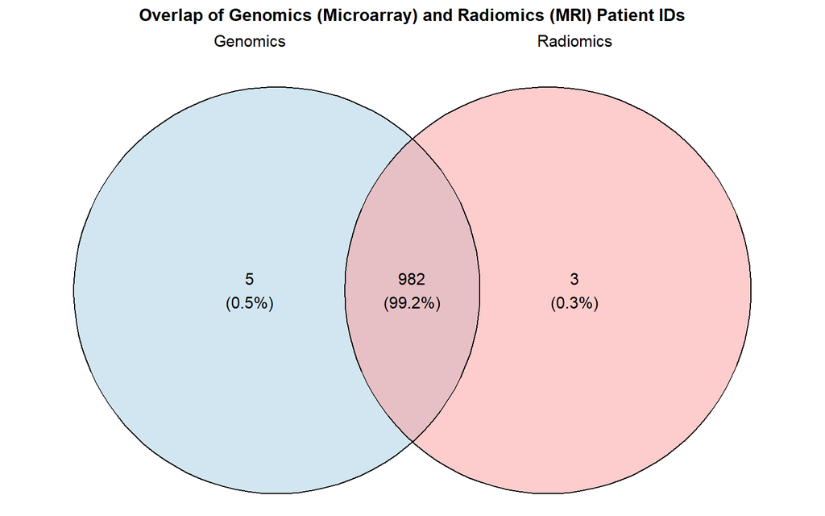

```r
# Venn diagram
venn_data <- list(Genomics = Genomics_clin$patientid, Radiomics = Radiomics_clin$Patient_ID)

ggvenn(venn_data, fill_color = c("#A6CEE3", "#FB9A99"), stroke_size = 0.5, set_name_size = 4) +
  ggtitle("Overlap of Genomics (Microarray) and Radiomics (MRI) Patient IDs") +
  theme(plot.title = element_text(hjust = 0.5, size = 12, face = "bold"),
        plot.background = element_rect(fill = "white"),
        panel.background = element_blank())
```

### Merge Genomics & Radiomics Data

Merging both datasets based on **common patient IDs**.

```r
# Add prefix to radiomics columns
colnames(Radiomics_clin)[-which(colnames(Radiomics_clin) == "Patient_ID")] <-
  paste0("Radiomics_", colnames(Radiomics_clin)[-which(colnames(Radiomics_clin) == "Patient_ID")])

# Merge datasets
merged_clin <- merge(Genomics_clin, Radiomics_clin, by.x = "patientid", by.y = "Patient_ID")
merged_clin <- merged_clin[order(merged_clin$patientid), ]

# Save dataset
write.csv(merged_clin,
          file = file.path(here(), "data/results/radiogenomics", "combined_clin_radiogenomic.csv"),
          row.names = FALSE)

kable(head(merged_clin, 50), caption = "Merged Clinical Data (Genomics & Radiomics)") %>%
  kable_styling(bootstrap_options = c("striped", "hover", "condensed"), full_width = FALSE) %>%
  scroll_box(height = "400px")
```

Merged Clinical Data (Genomics & Radiomics)

| patientid | sex | age | cancer_type | histo | tissueid | stage | response.other.info | recist | response | treatment | dna | rna | survival_time_pfs | event_occurred_pfs | survival_time_os | event_occurred_os | survival_unit | survival_type | TMB_raw | nsTMB_raw | indel_TMB_raw | indel_nsTMB_raw | TMB_perMb | nsTMB_perMb | indel_TMB_perMb | indel_nsTMB_perMb | CIN | CNA_tot | AMP | … |
| --- | --- | --- | --- | --- | --- | --- | --- | --- | --- | --- | --- | --- | --- | --- | --- | --- | --- | --- | --- | --- | --- | --- | --- | --- | --- | --- | --- | --- | --- | --- |
| 100899 | F | NA | Breast | NA | Breast | NA | NR | NA | NR | chemo+targeted | NA | microarray | NA | NA | NA | NA | NA | None | NA | NA | NA | NA | NA | NA | NA | NA | NA | NA | NA | … |
| 102011 | F | NA | Breast | NA | Breast | NA | NR | NA | NR | chemo+targeted | NA | microarray | NA | NA | NA | NA | NA | None | NA | NA | NA | NA | NA | NA | NA | NA | NA | NA | NA | … |
| 102212 | F | NA | Breast | NA | Breast | NA | NR | NA | NR | chemo+targeted | NA | microarray | NA | NA | NA | NA | NA | None | NA | NA | NA | NA | NA | NA | NA | NA | NA | NA | NA | … |
| 103693 | F | NA | Breast | NA | Breast | NA | NR | NA | NR | IO+chemo | NA | microarray | NA | NA | NA | NA | NA | None | NA | NA | NA | NA | NA | NA | NA | NA | NA | NA | NA | … |
| 103939 | F | NA | Breast | NA | Breast | NA | NR | NA | NR | chemo | NA | microarray | NA | NA | NA | NA | NA | None | NA | NA | NA | NA | NA | NA | NA | NA | NA | NA | NA | … |
| 104268 | F | NA | Breast | NA | Breast | NA | NR | NA | NR | chemo | NA | microarray | NA | NA | NA | NA | NA | None | NA | NA | NA | NA | NA | NA | NA | NA | NA | NA | NA | … |
| 104384 | F | NA | Breast | NA | Breast | NA | NR | NA | NR | IO+chemo | NA | microarray | NA | NA | NA | NA | NA | None | NA | NA | NA | NA | NA | NA | NA | NA | NA | NA | NA | … |
| 105286 | F | NA | Breast | NA | Breast | NA | NR | NA | NR | chemo+targeted | NA | microarray | NA | NA | NA | NA | NA | None | NA | NA | NA | NA | NA | NA | NA | NA | NA | NA | NA | … |
| 105513 | F | NA | Breast | NA | Breast | NA | R | NA | R | chemo+targeted | NA | microarray | NA | NA | NA | NA | NA | None | NA | NA | NA | NA | NA | NA | NA | NA | NA | NA | NA | … |
| 107700 | F | NA | Breast | NA | Breast | NA | NR | NA | NR | chemo+targeted | NA | microarray | NA | NA | NA | NA | NA | None | NA | NA | NA | NA | NA | NA | NA | NA | NA | NA | NA | … |
| 108939 | F | NA | Breast | NA | Breast | NA | R | NA | R | chemo+targeted | NA | microarray | NA | NA | NA | NA | NA | None | NA | NA | NA | NA | NA | NA | NA | NA | NA | NA | NA | … |
| 108969 | F | NA | Breast | NA | Breast | NA | R | NA | R | chemo+targeted | NA | microarray | NA | NA | NA | NA | NA | None | NA | NA | NA | NA | NA | NA | NA | NA | NA | NA | NA | … |
| 109623 | F | NA | Breast | NA | Breast | NA | NR | NA | NR | chemo+targeted | NA | microarray | NA | NA | NA | NA | NA | None | NA | NA | NA | NA | NA | NA | NA | NA | NA | NA | NA | … |
| 109874 | F | NA | Breast | NA | Breast | NA | R | NA | R | chemo+targeted | NA | microarray | NA | NA | NA | NA | NA | None | NA | NA | NA | NA | NA | NA | NA | NA | NA | NA | NA | … |
| 109980 | F | NA | Breast | NA | Breast | NA | R | NA | R | chemo+targeted | NA | microarray | NA | NA | NA | NA | NA | None | NA | NA | NA | NA | NA | NA | NA | NA | NA | NA | NA | … |
| 111004 | F | NA | Breast | NA | Breast | NA | NR | NA | NR | IO+chemo | NA | microarray | NA | NA | NA | NA | NA | None | NA | NA | NA | NA | NA | NA | NA | NA | NA | NA | NA | … |
| 111038 | F | NA | Breast | NA | Breast | NA | NR | NA | NR | chemo+targeted | NA | microarray | NA | NA | NA | NA | NA | None | NA | NA | NA | NA | NA | NA | NA | NA | NA | NA | NA | … |
| 111344 | F | NA | Breast | NA | Breast | NA | NR | NA | NR | chemo+targeted | NA | microarray | NA | NA | NA | NA | NA | None | NA | NA | NA | NA | NA | NA | NA | NA | NA | NA | NA | … |
| 111646 | F | NA | Breast | NA | Breast | NA | NR | NA | NR | chemo+targeted | NA | microarray | NA | NA | NA | NA | NA | None | NA | NA | NA | NA | NA | NA | NA | NA | NA | NA | NA | … |
| 111674 | F | NA | Breast | NA | Breast | NA | R | NA | R | chemo+targeted | NA | microarray | NA | NA | NA | NA | NA | None | NA | NA | NA | NA | NA | NA | NA | NA | NA | NA | NA | … |
| 111881 | F | NA | Breast | NA | Breast | NA | R | NA | R | chemo+targeted | NA | microarray | NA | NA | NA | NA | NA | None | NA | NA | NA | NA | NA | NA | NA | NA | NA | NA | NA | … |
| 112606 | F | NA | Breast | NA | Breast | NA | NR | NA | NR | chemo+targeted | NA | microarray | NA | NA | NA | NA | NA | None | NA | NA | NA | NA | NA | NA | NA | NA | NA | NA | NA | … |
| 114087 | F | NA | Breast | NA | Breast | NA | NR | NA | NR | IO+chemo | NA | microarray | NA | NA | NA | NA | NA | None | NA | NA | NA | NA | NA | NA | NA | NA | NA | NA | NA | … |
| 115638 | F | NA | Breast | NA | Breast | NA | NR | NA | NR | chemo+targeted | NA | microarray | NA | NA | NA | NA | NA | None | NA | NA | NA | NA | NA | NA | NA | NA | NA | NA | NA | … |
| 115987 | F | NA | Breast | NA | Breast | NA | NR | NA | NR | chemo+targeted | NA | microarray | NA | NA | NA | NA | NA | None | NA | NA | NA | NA | NA | NA | NA | NA | NA | NA | NA | … |
| 116165 | F | NA | Breast | NA | Breast | NA | NR | NA | NR | IO+chemo | NA | microarray | NA | NA | NA | NA | NA | None | NA | NA | NA | NA | NA | NA | NA | NA | NA | NA | NA | … |
| 116603 | F | NA | Breast | NA | Breast | NA | NR | NA | NR | chemo | NA | microarray | NA | NA | NA | NA | NA | None | NA | NA | NA | NA | NA | NA | NA | NA | NA | NA | NA | … |
| 117424 | F | NA | Breast | NA | Breast | NA | R | NA | R | chemo+targeted | NA | microarray | NA | NA | NA | NA | NA | None | NA | NA | NA | NA | NA | NA | NA | NA | NA | NA | NA | … |
| 117707 | F | NA | Breast | NA | Breast | NA | R | NA | R | chemo+targeted | NA | microarray | NA | NA | NA | NA | NA | None | NA | NA | NA | NA | NA | NA | NA | NA | NA | NA | NA | … |
| 118307 | F | NA | Breast | NA | Breast | NA | NR | NA | NR | chemo+targeted | NA | microarray | NA | NA | NA | NA | NA | None | NA | NA | NA | NA | NA | NA | NA | NA | NA | NA | NA | … |
| 119928 | F | NA | Breast | NA | Breast | NA | NR | NA | NR | chemo+targeted | NA | microarray | NA | NA | NA | NA | NA | None | NA | NA | NA | NA | NA | NA | NA | NA | NA | NA | NA | … |
| 120001 | F | NA | Breast | NA | Breast | NA | NR | NA | NR | chemo+targeted | NA | microarray | NA | NA | NA | NA | NA | None | NA | NA | NA | NA | NA | NA | NA | NA | NA | NA | NA | … |
| 120422 | F | NA | Breast | NA | Breast | NA | R | NA | R | chemo+targeted | NA | microarray | NA | NA | NA | NA | NA | None | NA | NA | NA | NA | NA | NA | NA | NA | NA | NA | NA | … |
| 122287 | F | NA | Breast | NA | Breast | NA | R | NA | R | targeted | NA | microarray | NA | NA | NA | NA | NA | None | NA | NA | NA | NA | NA | NA | NA | NA | NA | NA | NA | … |
| 122579 | F | NA | Breast | NA | Breast | NA | NR | NA | NR | chemo | NA | microarray | NA | NA | NA | NA | NA | None | NA | NA | NA | NA | NA | NA | NA | NA | NA | NA | NA | … |
| 122795 | F | NA | Breast | NA | Breast | NA | NR | NA | NR | chemo+targeted | NA | microarray | NA | NA | NA | NA | NA | None | NA | NA | NA | NA | NA | NA | NA | NA | NA | NA | NA | … |
| 123660 | F | NA | Breast | NA | Breast | NA | NR | NA | NR | chemo+targeted | NA | microarray | NA | NA | NA | NA | NA | None | NA | NA | NA | NA | NA | NA | NA | NA | NA | NA | NA | … |
| 125130 | F | NA | Breast | NA | Breast | NA | R | NA | R | targeted | NA | microarray | NA | NA | NA | NA | NA | None | NA | NA | NA | NA | NA | NA | NA | NA | NA | NA | NA | … |
| 125418 | F | NA | Breast | NA | Breast | NA | NR | NA | NR | chemo+targeted | NA | microarray | NA | NA | NA | NA | NA | None | NA | NA | NA | NA | NA | NA | NA | NA | NA | NA | NA | … |
| 127675 | F | NA | Breast | NA | Breast | NA | NR | NA | NR | chemo+targeted | NA | microarray | NA | NA | NA | NA | NA | None | NA | NA | NA | NA | NA | NA | NA | NA | NA | NA | NA | … |
| 127791 | F | NA | Breast | NA | Breast | NA | NR | NA | NR | chemo+targeted | NA | microarray | NA | NA | NA | NA | NA | None | NA | NA | NA | NA | NA | NA | NA | NA | NA | NA | NA | … |
| 128051 | F | NA | Breast | NA | Breast | NA | NR | NA | NR | targeted | NA | microarray | NA | NA | NA | NA | NA | None | NA | NA | NA | NA | NA | NA | NA | NA | NA | NA | NA | … |
| 128675 | F | NA | Breast | NA | Breast | NA | R | NA | R | chemo | NA | microarray | NA | NA | NA | NA | NA | None | NA | NA | NA | NA | NA | NA | NA | NA | NA | NA | NA | … |
| 129837 | F | NA | Breast | NA | Breast | NA | NR | NA | NR | chemo+targeted | NA | microarray | NA | NA | NA | NA | NA | None | NA | NA | NA | NA | NA | NA | NA | NA | NA | NA | NA | … |
| 129973 | F | NA | Breast | NA | Breast | NA | R | NA | R | chemo+targeted | NA | microarray | NA | NA | NA | NA | NA | None | NA | NA | NA | NA | NA | NA | NA | NA | NA | NA | NA | … |
| 130580 | F | NA | Breast | NA | Breast | NA | R | NA | R | chemo+targeted | NA | microarray | NA | NA | NA | NA | NA | None | NA | NA | NA | NA | NA | NA | NA | NA | NA | NA | NA | … |
| 130892 | F | NA | Breast | NA | Breast | NA | R | NA | R | chemo+targeted | NA | microarray | NA | NA | NA | NA | NA | None | NA | NA | NA | NA | NA | NA | NA | NA | NA | NA | NA | … |
| 131595 | F | NA | Breast | NA | Breast | NA | NR | NA | NR | chemo+targeted | NA | microarray | NA | NA | NA | NA | NA | None | NA | NA | NA | NA | NA | NA | NA | NA | NA | NA | NA | … |
| 131961 | F | NA | Breast | NA | Breast | NA | R | NA | R | targeted | NA | microarray | NA | NA | NA | NA | NA | None | NA | NA | NA | NA | NA | NA | NA | NA | NA | NA | NA | … |
| 132463 | F | NA | Breast | NA | Breast | NA | R | NA | R | chemo+targeted | NA | microarray | NA | NA | NA | NA | NA | None | NA | NA | NA | NA | NA | NA | NA | NA | NA | NA | NA | … |

### Segmentation Overview

We evaluated segmentation consistency by verifying that each patient had four **DCE-MRI** segmentation masks — one per time point — for reliable **Functional Tumor Volume (FTV)** analysis. Most patients met this requirement; those with fewer were flagged for review.

#### DCE-MRI Segmentation

Each scan undergoes multiple segmentation steps:

1. **Manual VOI (Volume of Interest):** A rectangular region around the enhancing tumor.
2. **Background Masking:** Removes noise and fat saturation artifacts.
3. **Percent Enhancement (PE) Threshold:** Filters non-enhancing tissue.
4. **Connectivity Filter:** Ensures 3D tumor voxel connectivity.
5. **OMIT Regions:** Manual exclusion of non-tumor areas.

Segmentation masks are stored as **2D DICOM images**, aligned with the original **DCE-MRI scans**.

> Download masks: [UCSF Box](https://ucsf.box.com/s/d09xetaatzgnz2p9bxlqh50rrzilgcoj)

#### Segmentation Metadata

##### ISPY1: MRI Metadata

Stored in `ispy1_dce_series_info.xlsx`, this file contains metadata for **221 patients**.

```r
ispy1_dce_series_info <- read_excel(
  path = file.path(input_dir, "ispy1_dce_series_info.xlsx"),
  sheet = "DCE Series, All 20160823"
)

ispy1_dce_series_info <- ispy1_dce_series_info %>%
  mutate(TIME_POINT = recode(TIME_POINT, "T1" = "T0","T2" = "T1","T3" = "T2","T4" = "T3"))

kable(head(ispy1_dce_series_info, 20), caption = "DCE MRI Series Information") %>%
  kable_styling(bootstrap_options = c("striped", "hover", "condensed"), full_width = FALSE) %>%
  scroll_box(height = "400px")
```

DCE MRI Series Information

| PATIENT_ID | SUBJECT_NO | TIME_POINT | VISIT | SERIES_DESC | SERIES_ID | SERIES_TYPE | SERIES_CAT | STUDY_UID | SERIES_UID | SERIES_PATH | PRIMARY_AIM | GOOD_VOLSER | VOLSER | ACQ_POST_PHASES | PRE_PHASE_INDEX | EARLY_PHASE_INDEX | LATE_PHASE_INDEX | OMIT_ROI_COUNT | BACKGROUND_PCT | BACKGROUND_THRESHOLD | PE_THRESHOLD | MIN_NEIGHBOR_COUNT | EARLY_DELAY | LATE_DELAY | VOI_CENTER_RL | VOI_CENTER_AP | VOI_CENTER_SI | VOI_HALF_WIDTH_RL | VOI_HALF_WIDTH_AP | … |
| --- | --- | --- | --- | --- | --- | --- | --- | --- | --- | --- | --- | --- | --- | --- | --- | --- | --- | --- | --- | --- | --- | --- | --- | --- | --- | --- | --- | --- | --- | --- |
| ISPY1_1001 | 1001 | T0 | 10 | Dynamic-3dfgre | 4 | dce/post | dce pre post | 1.3.6.1.4.1.14519.5.2.1.7695.1700.162588073261248159118785473116 | 1.3.6.1.4.1.14519.5.2.1.7695.1700.334491271566855314830260417024 | ISPY1/ISPY1_1001/1.3.6.1.4.1.14519.5.2.1.7695.1700.162588073261248159118785473116/1.3.6.1.4.1.14519.5.2.1.7695.1700.334491271566855314830260417024 | 1 | 1 | yes | 2 | 0 | 1 | 2 | NA | 60 | 57 | 70 | 4 | 142.908 | 471.909 | 82.89999 | -44.875000 | -12.7500000 | 0 | 39.84375 | … |
| ISPY1_1001 | 1001 | T1 | 20 | Dynamic-3dfgre | 3 | dce/post | dce pre post | 1.3.6.1.4.1.14519.5.2.1.7695.1700.251725059071532256976802593346 | 1.3.6.1.4.1.14519.5.2.1.7695.1700.284567351304426376226790714264 | ISPY1/ISPY1_1001/1.3.6.1.4.1.14519.5.2.1.7695.1700.251725059071532256976802593346/1.3.6.1.4.1.14519.5.2.1.7695.1700.284567351304426376226790714264 | 1 | 1 | yes | 2 | 0 | 1 | 2 | NA | 60 | 50 | 70 | 9 | 142.908 | 504.909 | 102.00000 | -46.503125 | -45.1562500 | 0 | 44.92188 | … |
| ISPY1_1001 | 1001 | T2 | 30 | Dynamic-3dfgre | 4 | dce/post | dce pre post | 1.3.6.1.4.1.14519.5.2.1.7695.1700.186130315530827043916665138479 | 1.3.6.1.4.1.14519.5.2.1.7695.1700.229054711046553504545787083659 | ISPY1/ISPY1_1001/1.3.6.1.4.1.14519.5.2.1.7695.1700.186130315530827043916665138479/1.3.6.1.4.1.14519.5.2.1.7695.1700.229054711046553504545787083659 | 1 | 1 | yes | 2 | 0 | 1 | 2 | NA | 60 | NA | 70 | 4 | 142.908 | 467.909 | 75.80000 | -35.546875 | 14.2031250 | 0 | 43.35938 | … |
| ISPY1_1001 | 1001 | T3 | 40 | Dynamic-3dfgre | 4 | dce/post | dce pre post | 1.3.6.1.4.1.14519.5.2.1.7695.1700.118757564401397374205631727107 | 1.3.6.1.4.1.14519.5.2.1.7695.1700.195983148423034180376334647727 | ISPY1/ISPY1_1001/1.3.6.1.4.1.14519.5.2.1.7695.1700.118757564401397374205631727107/1.3.6.1.4.1.14519.5.2.1.7695.1700.195983148423034180376334647727 | 1 | 1 | yes | 2 | 0 | 1 | 2 | NA | 60 | NA | 70 | 9 | 142.908 | 469.909 | 68.70000 | -47.659374 | 9.1562500 | 0 | 37.10938 | … |
| ISPY1_1002 | 1002 | T0 | 10 | Dynamic-3dfgre | 3 | dce/post | dce pre post | 1.3.6.1.4.1.14519.5.2.1.7695.1700.134976640792500085117907460097 | 1.3.6.1.4.1.14519.5.2.1.7695.1700.200978610610642152304681086604 | ISPY1/ISPY1_1002/1.3.6.1.4.1.14519.5.2.1.7695.1700.134976640792500085117907460097/1.3.6.1.4.1.14519.5.2.1.7695.1700.200978610610642152304681086604 | 1 | 1 | yes | 2 | 0 | 1 | 2 | NA | 60 | 47 | 70 | 4 | 142.908 | 487.909 | -120.10000 | -8.543750 | 2.0156250 | 0 | 24.21875 | … |
| ISPY1_1002 | 1002 | T1 | 20 | Dynamic-3dfgre | 3 | dce/post | dce pre post | 1.3.6.1.4.1.14519.5.2.1.7695.1700.213299857546682356325308543300 | 1.3.6.1.4.1.14519.5.2.1.7695.1700.217629313261264666455404162928 | ISPY1/ISPY1_1002/1.3.6.1.4.1.14519.5.2.1.7695.1700.213299857546682356325308543300/1.3.6.1.4.1.14519.5.2.1.7695.1700.217629313261264666455404162928 | 1 | 1 | yes | 2 | 0 | 1 | 2 | NA | 60 | 49 | 70 | 4 | 142.908 | 455.909 | -108.60000 | -15.184375 | 17.8125000 | 0 | 18.35938 | … |
| ISPY1_1002 | 1002 | T2 | 30 | Dynamic-3dfgre | 5 | dce/post | dce pre post | 1.3.6.1.4.1.14519.5.2.1.7695.1700.310641334810324025592282005680 | 1.3.6.1.4.1.14519.5.2.1.7695.1700.308304415889255945632238319959 | ISPY1/ISPY1_1002/1.3.6.1.4.1.14519.5.2.1.7695.1700.310641334810324025592282005680/1.3.6.1.4.1.14519.5.2.1.7695.1700.308304415889255945632238319959 | 1 | 1 | yes | 2 | 0 | 1 | 2 | NA | 60 | NA | 70 | 4 | 142.908 | 480.909 | -124.50000 | -9.768749 | -0.5000000 | 0 | 12.50000 | … |
| ISPY1_1002 | 1002 | T3 | 40 | Dynamic-3dfgre | 4 | dce/post | dce pre post | 1.3.6.1.4.1.14519.5.2.1.7695.1700.161260768808765067428187568337 | 1.3.6.1.4.1.14519.5.2.1.7695.1700.123719184220486274456682769238 | ISPY1/ISPY1_1002/1.3.6.1.4.1.14519.5.2.1.7695.1700.161260768808765067428187568337/1.3.6.1.4.1.14519.5.2.1.7695.1700.123719184220486274456682769238 | 1 | 1 | yes | 2 | 0 | 1 | 2 | NA | 60 | NA | 70 | 4 | 142.908 | 464.909 | -107.00000 | -10.784375 | -13.3906250 | 0 | 18.35938 | … |
| ISPY1_1003 | 1003 | T0 | 10 | Dynamic-3dfgre | 3 | dce/post | dce pre post | 1.3.6.1.4.1.14519.5.2.1.7695.1700.298080081174310898419212435677 | 1.3.6.1.4.1.14519.5.2.1.7695.1700.217966338988546791542147267475 | ISPY1/ISPY1_1003/1.3.6.1.4.1.14519.5.2.1.7695.1700.298080081174310898419212435677/1.3.6.1.4.1.14519.5.2.1.7695.1700.217966338988546791542147267475 | 1 | 1 | yes | 2 | 0 | 1 | 2 | NA | 60 | 41 | 70 | 4 | 142.908 | 464.909 | 80.00000 | -42.150000 | -38.9531250 | 0 | 39.84375 | … |
| ISPY1_1003 | 1003 | T1 | 20 | Dynamic-3dfgre | 4 | dce/post | dce pre post | 1.3.6.1.4.1.14519.5.2.1.7695.1700.138213557573473307011258165864 | 1.3.6.1.4.1.14519.5.2.1.7695.1700.299956820661297346246226539430 | ISPY1/ISPY1_1003/1.3.6.1.4.1.14519.5.2.1.7695.1700.138213557573473307011258165864/1.3.6.1.4.1.14519.5.2.1.7695.1700.299956820661297346246226539430 | 1 | 1 | yes | 2 | 0 | 1 | 2 | 1 | 60 | 49 | 70 | 4 | 142.908 | 448.909 | 85.89999 | -20.403125 | 23.5281260 | 0 | 33.98438 | … |
| ISPY1_1003 | 1003 | T2 | 30 | Dynamic-3dfgre | 4 | dce/post | dce pre post | 1.3.6.1.4.1.14519.5.2.1.7695.1700.266827030532815128632203224043 | 1.3.6.1.4.1.14519.5.2.1.7695.1700.160218149129103458523671303946 | ISPY1/ISPY1_1003/1.3.6.1.4.1.14519.5.2.1.7695.1700.266827030532815128632203224043/1.3.6.1.4.1.14519.5.2.1.7695.1700.160218149129103458523671303946 | 1 | 1 | yes | 2 | 0 | 1 | 2 | NA | 60 | NA | 70 | 4 | 142.908 | 467.909 | 84.89999 | -31.143750 | -10.5156250 | 0 | 30.46875 | … |
| ISPY1_1003 | 1003 | T3 | 40 | Dynamic-3dfgre | 4 | dce/post | dce pre post | 1.3.6.1.4.1.14519.5.2.1.7695.1700.268904421322788588680650702521 | 1.3.6.1.4.1.14519.5.2.1.7695.1700.333833341467598933118786229456 | ISPY1/ISPY1_1003/1.3.6.1.4.1.14519.5.2.1.7695.1700.268904421322788588680650702521/1.3.6.1.4.1.14519.5.2.1.7695.1700.333833341467598933118786229456 | 1 | 1 | yes | 2 | 0 | 1 | 2 | NA | 60 | NA | 70 | 9 | 142.908 | 477.909 | 82.40000 | -33.162500 | -23.6875000 | 0 | 26.56250 | … |
| ISPY1_1004 | 1004 | T0 | 10 | CTLMID,Sag,3D,SPGR,VBw, GRx, | 2 | dce/post | dce pre post | 1.3.6.1.4.1.14519.5.2.1.7695.1700.123666578177897342122858721875 | 1.3.6.1.4.1.14519.5.2.1.7695.1700.228597508795509915957044689330 | ISPY1/ISPY1_1004/1.3.6.1.4.1.14519.5.2.1.7695.1700.123666578177897342122858721875/1.3.6.1.4.1.14519.5.2.1.7695.1700.228597508795509915957044689330 | 1 | 1 | yes | 2 | 0 | 1 | 2 | NA | 65 | 72 | 90 | 13 | 204.500 | 613.500 | 78.75000 | -43.484375 | 19.2500000 | 0 | 36.91406 | … |
| ISPY1_1004 | 1004 | T1 | 20 | PELVIC,Sag,3D,SPGR,VBw, GRx, | 2 | dce/post | dce pre post | 1.3.6.1.4.1.14519.5.2.1.7695.1700.139210337184334513376946376405 | 1.3.6.1.4.1.14519.5.2.1.7695.1700.300426672774245107955438830162 | ISPY1/ISPY1_1004/1.3.6.1.4.1.14519.5.2.1.7695.1700.139210337184334513376946376405/1.3.6.1.4.1.14519.5.2.1.7695.1700.300426672774245107955438830162 | 1 | 1 | yes | 2 | 0 | 1 | 2 | NA | 65 | 90 | 90 | 13 | 182.000 | 546.000 | 77.55000 | -36.514069 | 1.5781250 | 0 | 35.85938 | … |
| ISPY1_1004 | 1004 | T2 | 30 | CTLMID,Sag,3D,SPGR,VBw, GRx, | 3 | dce/post | dce pre post | 1.3.6.1.4.1.14519.5.2.1.7695.1700.472960478717934840128915797201 | 1.3.6.1.4.1.14519.5.2.1.7695.1700.304375489738621951636388985164 | ISPY1/ISPY1_1004/1.3.6.1.4.1.14519.5.2.1.7695.1700.472960478717934840128915797201/1.3.6.1.4.1.14519.5.2.1.7695.1700.304375489738621951636388985164 | 1 | 1 | yes | 2 | 0 | 1 | 2 | NA | 65 | NA | 90 | 13 | 186.500 | 559.500 | 70.89999 | -39.962502 | 3.0312500 | 0 | 45.35156 | … |
| ISPY1_1004 | 1004 | T3 | 40 | CTLMID,Sag,3D,SPGR,VBw, GRx, | 3 | dce/post | dce pre post | 1.3.6.1.4.1.14519.5.2.1.7695.1700.293613141232081657976654600946 | 1.3.6.1.4.1.14519.5.2.1.7695.1700.794231212227579946078491333086 | ISPY1/ISPY1_1004/1.3.6.1.4.1.14519.5.2.1.7695.1700.293613141232081657976654600946/1.3.6.1.4.1.14519.5.2.1.7695.1700.794231212227579946078491333086 | 1 | 1 | yes | 2 | 0 | 1 | 2 | NA | 65 | NA | 90 | 13 | 200.000 | 600.000 | 76.90000 | -27.107811 | 5.4453125 | 0 | 18.98438 | … |
| ISPY1_1005 | 1005 | T0 | 10 | CTLMID,Sag,3D,SPGR,VBw, GRx, | 2 | dce/post | dce pre post | 1.3.6.1.4.1.14519.5.2.1.7695.1700.168682333761219918185990956754 | 1.3.6.1.4.1.14519.5.2.1.7695.1700.112512091674522544167508033512 | ISPY1/ISPY1_1005/1.3.6.1.4.1.14519.5.2.1.7695.1700.168682333761219918185990956754/1.3.6.1.4.1.14519.5.2.1.7695.1700.112512091674522544167508033512 | 1 | 1 | yes | 2 | 0 | 1 | 2 | NA | 65 | 73 | 90 | 13 | 175.500 | 526.500 | 79.90001 | -41.065628 | 39.2656250 | 0 | 46.05469 | … |
| ISPY1_1005 | 1005 | T1 | 20 | CTLMID,Sag,3D,SPGR,VBw, GRx, | 2 | dce/post | dce pre post | 1.3.6.1.4.1.14519.5.2.1.7695.1700.175394084652801531467726863292 | 1.3.6.1.4.1.14519.5.2.1.7695.1700.229410656917615455958078148940 | ISPY1/ISPY1_1005/1.3.6.1.4.1.14519.5.2.1.7695.1700.175394084652801531467726863292/1.3.6.1.4.1.14519.5.2.1.7695.1700.229410656917615455958078148940 | 0 | 0 | no | 1 | NA | NA | NA | NA | NA | NA | NA | NA | NA | NA | NA | NA | NA | NA | NA | … |
| ISPY1_1005 | 1005 | T2 | 30 | CTLMID,Sag,3D,SPGR,VBw, GRx, | 4 | dce/post | dce pre post | 1.3.6.1.4.1.14519.5.2.1.7695.1700.278680050483471060479946922896 | 1.3.6.1.4.1.14519.5.2.1.7695.1700.253971398051889701206388702985 | ISPY1/ISPY1_1005/1.3.6.1.4.1.14519.5.2.1.7695.1700.278680050483471060479946922896/1.3.6.1.4.1.14519.5.2.1.7695.1700.253971398051889701206388702985 | 0 | 1 | yes | 2 | 0 | 1 | 2 | NA | 65 | 70 | 90 | 13 | 206.500 | 619.500 | 72.40313 | -48.245316 | -0.1796875 | 0 | 46.05469 | … |
| ISPY1_1005 | 1005 | T3 | 40 | 3D | 5 | dce/post | dce pre post | 1.3.6.1.4.1.14519.5.2.1.7695.1700.315178405770722394134357255715 | 1.3.6.1.4.1.14519.5.2.1.7695.1700.244038849484388506230960714412 | ISPY1/ISPY1_1005/1.3.6.1.4.1.14519.5.2.1.7695.1700.315178405770722394134357255715/1.3.6.1.4.1.14519.5.2.1.7695.1700.244038849484388506230960714412 | 1 | 1 | yes | 2 | 0 | 1 | 2 | NA | 65 | NA | 90 | 13 | 146.369 | 621.369 | 86.80000 | -37.195313 | 31.5546880 | 0 | 39.02344 | … |

##### ISPY2: MRI Metadata

Metadata for ISPY2 was extracted from `series-data1741883133411.csv`, containing records for **719 patients**.

```r
ispy2_dce_series_info <- read.csv(file.path(input_dir, "series-data1741883133411.csv"))
colnames(ispy2_dce_series_info)[colnames(ispy2_dce_series_info) == "Subject.ID"] <- "PATIENT_ID"
ispy2_dce_series_info$TIME_POINT <- gsub(".*(T[0-9]+).*", "\\1", ispy2_dce_series_info$Study.Description)

kable(head(ispy2_dce_series_info, 20), caption = "ISPY2 DCE MRI Series Information") %>%
  kable_styling(bootstrap_options = c("striped", "hover", "condensed"), full_width = FALSE) %>%
  scroll_box(height = "400px")
```

ISPY2 DCE MRI Series Information

| PATIENT_ID | Study.UID | Study.Description | Study.Date | Series.ID | Series.Description | Number.of.images | File.Size..Bytes. | Collection.Name | Modality | Manufacturer | X3rd.Party.Analysis | Data.Description.URI | Series.Number | License.Name | License.URL | Date.Released | Series.Date | Protocol.Name | Body.Part.Examined | Annotations.Flag | Manufacturer.Model.Name | Software.Versions | TimeStamp | TIME_POINT |
| --- | --- | --- | --- | --- | --- | --- | --- | --- | --- | --- | --- | --- | --- | --- | --- | --- | --- | --- | --- | --- | --- | --- | --- | --- |
| ISPY2-100899 | 1.3.6.1.4.1.14519.5.2.1.191407311082200176460176232508943888595 | ISPY2_MRI_T0 | 2002-10-26 | 1.3.6.1.4.1.14519.5.2.1.313330782407390298344661311370946136238 | ISPY2: SCOUT ISPY2 | 51 | 6827686 | ISPY2 | MR | GE MEDICAL SYSTEMS | NO | https://doi.org/10.7937/TCIA.D8Z0-9T85 | 1 | Creative Commons Attribution 4.0 International License | https://creativecommons.org/licenses/by/4.0/ | 2022-05-02 | 2002-10-26 | NA |  | NA | Signa HDxt | 24 | 2022-05-02 00:00:00.0 | T0 |
| ISPY2-100899 | 1.3.6.1.4.1.14519.5.2.1.191407311082200176460176232508943888595 | ISPY2_MRI_T0 | 2002-10-26 | 1.3.6.1.4.1.14519.5.2.1.279614487823636499235940907104792611414 | ISPY2: WATER:IDEAL | 45 | 23737674 | ISPY2 | MR | GE MEDICAL SYSTEMS | NO | https://doi.org/10.7937/TCIA.D8Z0-9T85 | 3 | Creative Commons Attribution 4.0 International License | https://creativecommons.org/licenses/by/4.0/ | 2022-05-02 | 2002-10-26 | NA |  | NA | Signa HDxt | 24 | 2022-05-02 00:00:00.0 | T0 |
| ISPY2-100899 | 1.3.6.1.4.1.14519.5.2.1.191407311082200176460176232508943888595 | ISPY2_MRI_T0 | 2002-10-26 | 1.3.6.1.4.1.14519.5.2.1.2647355698869417812524932280893489028 | ISPY2: FAT:IDEAL | 45 | 23737582 | ISPY2 | MR | GE MEDICAL SYSTEMS | NO | https://doi.org/10.7937/TCIA.D8Z0-9T85 | 300 | Creative Commons Attribution 4.0 International License | https://creativecommons.org/licenses/by/4.0/ | 2022-05-02 | 2002-10-26 | NA |  | NA | Signa HDxt | 24 | 2022-05-02 00:00:00.0 | T0 |
| ISPY2-100899 | 1.3.6.1.4.1.14519.5.2.1.191407311082200176460176232508943888595 | ISPY2_MRI_T0 | 2002-10-26 | 1.3.6.1.4.1.14519.5.2.1.206199927301215764245278347773827952523 | ISPY2: AX VIBRANT-SERIES | 106 | 55919746 | ISPY2 | MR | GE MEDICAL SYSTEMS | NO | https://doi.org/10.7937/TCIA.D8Z0-9T85 | 500 | Creative Commons Attribution 4.0 International License | https://creativecommons.org/licenses/by/4.0/ | 2022-05-02 | 2002-10-26 | NA |  | NA | Signa HDxt | 24 | 2022-05-02 00:00:00.0 | T0 |
| ISPY2-100899 | 1.3.6.1.4.1.14519.5.2.1.191407311082200176460176232508943888595 | ISPY2_MRI_T0 | 2002-10-26 | 1.3.6.1.4.1.14519.5.2.1.266124567498488197926988477469957203969 | ISPY2: Ph1/AX VIBRANT-SERIES | 106 | 55924242 | ISPY2 | MR | GE MEDICAL SYSTEMS | NO | https://doi.org/10.7937/TCIA.D8Z0-9T85 | 501 | Creative Commons Attribution 4.0 International License | https://creativecommons.org/licenses/by/4.0/ | 2022-05-02 | 2002-10-26 | NA |  | NA | Signa HDxt | 24 | 2022-05-02 00:00:00.0 | T0 |
| ISPY2-100899 | 1.3.6.1.4.1.14519.5.2.1.191407311082200176460176232508943888595 | ISPY2_MRI_T0 | 2002-10-26 | 1.3.6.1.4.1.14519.5.2.1.16099171300378572953268398707957231139 | ISPY2: Ph2/AX VIBRANT-SERIES | 106 | 55925922 | ISPY2 | MR | GE MEDICAL SYSTEMS | NO | https://doi.org/10.7937/TCIA.D8Z0-9T85 | 502 | Creative Commons Attribution 4.0 International License | https://creativecommons.org/licenses/by/4.0/ | 2022-05-02 | 2002-10-26 | NA |  | NA | Signa HDxt | 24 | 2022-05-02 00:00:00.0 | T0 |
| ISPY2-100899 | 1.3.6.1.4.1.14519.5.2.1.191407311082200176460176232508943888595 | ISPY2_MRI_T0 | 2002-10-26 | 1.3.6.1.4.1.14519.5.2.1.121895725493536428267661368492699481578 | ISPY2: Ph3/AX VIBRANT-SERIES | 106 | 55926114 | ISPY2 | MR | GE MEDICAL SYSTEMS | NO | https://doi.org/10.7937/TCIA.D8Z0-9T85 | 503 | Creative Commons Attribution 4.0 International License | https://creativecommons.org/licenses/by/4.0/ | 2022-05-02 | 2002-10-26 | NA |  | NA | Signa HDxt | 24 | 2022-05-02 00:00:00.0 | T0 |
| ISPY2-100899 | 1.3.6.1.4.1.14519.5.2.1.191407311082200176460176232508943888595 | ISPY2_MRI_T0 | 2002-10-26 | 1.3.6.1.4.1.14519.5.2.1.308685298008010400893831782399676642910 | ISPY2: Ph4/AX VIBRANT-SERIES | 106 | 55926134 | ISPY2 | MR | GE MEDICAL SYSTEMS | NO | https://doi.org/10.7937/TCIA.D8Z0-9T85 | 504 | Creative Commons Attribution 4.0 International License | https://creativecommons.org/licenses/by/4.0/ | 2022-05-02 | 2002-10-26 | NA |  | NA | Signa HDxt | 24 | 2022-05-02 00:00:00.0 | T0 |
| ISPY2-100899 | 1.3.6.1.4.1.14519.5.2.1.191407311082200176460176232508943888595 | ISPY2_MRI_T0 | 2002-10-26 | 1.3.6.1.4.1.14519.5.2.1.279756085626113072659714263260085690790 | ISPY2: Ph5/AX VIBRANT-SERIES | 106 | 55926134 | ISPY2 | MR | GE MEDICAL SYSTEMS | NO | https://doi.org/10.7937/TCIA.D8Z0-9T85 | 505 | Creative Commons Attribution 4.0 International License | https://creativecommons.org/licenses/by/4.0/ | 2022-05-02 | 2002-10-26 | NA |  | NA | Signa HDxt | 24 | 2022-05-02 00:00:00.0 | T0 |
| ISPY2-100899 | 1.3.6.1.4.1.14519.5.2.1.191407311082200176460176232508943888595 | ISPY2_MRI_T0 | 2002-10-26 | 1.3.6.1.4.1.14519.5.2.1.26092330643949841378637650049345388223 | ISPY2: Ph6/AX VIBRANT-SERIES | 106 | 55925942 | ISPY2 | MR | GE MEDICAL SYSTEMS | NO | https://doi.org/10.7937/TCIA.D8Z0-9T85 | 506 | Creative Commons Attribution 4.0 International License | https://creativecommons.org/licenses/by/4.0/ | 2022-05-02 | 2002-10-26 | NA |  | NA | Signa HDxt | 24 | 2022-05-02 00:00:00.0 | T0 |
| ISPY2-100899 | 1.3.6.1.4.1.14519.5.2.1.191407311082200176460176232508943888595 | ISPY2_MRI_T0 | 2002-10-26 | 1.3.6.1.4.1.14519.5.2.1.269426242885278506123547184297304481837 | ISPY2: Ph7/AX VIBRANT-SERIES | 106 | 55926102 | ISPY2 | MR | GE MEDICAL SYSTEMS | NO | https://doi.org/10.7937/TCIA.D8Z0-9T85 | 507 | Creative Commons Attribution 4.0 International License | https://creativecommons.org/licenses/by/4.0/ | 2022-05-02 | 2002-10-26 | NA |  | NA | Signa HDxt | 24 | 2022-05-02 00:00:00.0 | T0 |
| ISPY2-100899 | 1.3.6.1.4.1.14519.5.2.1.191407311082200176460176232508943888595 | ISPY2_MRI_T0 | 2002-10-26 | 1.3.6.1.4.1.14519.5.2.1.293975225635615618905200212057567133995 | ISPY2: VOLSER: uni-lateral cropped: SER | 80 | 10996402 | ISPY2 | MR | GE MEDICAL SYSTEMS | NO | https://doi.org/10.7937/TCIA.D8Z0-9T85 | 51000 | Creative Commons Attribution 4.0 International License | https://creativecommons.org/licenses/by/4.0/ | 2022-05-02 | 2002-10-26 | NA |  | NA | Signa HDxt |  | 2022-05-02 00:00:00.0 | T0 |
| ISPY2-100899 | 1.3.6.1.4.1.14519.5.2.1.191407311082200176460176232508943888595 | ISPY2_MRI_T0 | 2002-10-26 | 1.3.6.1.4.1.14519.5.2.1.192674667601251977965157561923468814958 | ISPY2: VOLSER: uni-lateral cropped: PE2 | 80 | 10919044 | ISPY2 | MR | GE MEDICAL SYSTEMS | NO | https://doi.org/10.7937/TCIA.D8Z0-9T85 | 51002 | Creative Commons Attribution 4.0 International License | https://creativecommons.org/licenses/by/4.0/ | 2022-05-02 | 2002-10-26 | NA |  | NA | Signa HDxt |  | 2022-05-02 00:00:00.0 | T0 |
| ISPY2-100899 | 1.3.6.1.4.1.14519.5.2.1.191407311082200176460176232508943888595 | ISPY2_MRI_T0 | 2002-10-26 | 1.3.6.1.4.1.14519.5.2.1.12678479245503031715538181201834554397 | ISPY2: VOLSER: uni-lateral cropped: PE5 | 80 | 10918864 | ISPY2 | MR | GE MEDICAL SYSTEMS | NO | https://doi.org/10.7937/TCIA.D8Z0-9T85 | 51005 | Creative Commons Attribution 4.0 International License | https://creativecommons.org/licenses/by/4.0/ | 2022-05-02 | 2002-10-26 | NA |  | NA | Signa HDxt |  | 2022-05-02 00:00:00.0 | T0 |
| ISPY2-100899 | 1.3.6.1.4.1.14519.5.2.1.191407311082200176460176232508943888595 | ISPY2_MRI_T0 | 2002-10-26 | 1.3.6.1.4.1.14519.5.2.1.89750556793240490681454008016631530523 | ISPY2: VOLSER: uni-lateral cropped: original DCE | 640 | 86184586 | ISPY2 | MR | GE MEDICAL SYSTEMS | NO | https://doi.org/10.7937/TCIA.D8Z0-9T85 | 51800 | Creative Commons Attribution 4.0 International License | https://creativecommons.org/licenses/by/4.0/ | 2022-05-02 | 2002-10-26 | NA |  | NA | Signa HDxt |  | 2022-05-02 00:00:00.0 | T0 |
| ISPY2-100899 | 1.3.6.1.4.1.14519.5.2.1.191407311082200176460176232508943888595 | ISPY2_MRI_T0 | 2002-10-26 | 1.3.6.1.4.1.14519.5.2.1.170670992519727173038447879955287778091 | ISPY2: VOLSER: uni-lateral cropped: Analysis Mask | 1 | 5285900 | ISPY2 | SEG | GE MEDICAL SYSTEMS | NO | https://doi.org/10.7937/TCIA.D8Z0-9T85 | 51900 | Creative Commons Attribution 4.0 International License | https://creativecommons.org/licenses/by/4.0/ | 2022-05-02 |  | NA | BREAST | NA | Signa HDxt | 220 | 2022-05-02 00:00:00.0 | T0 |
| ISPY2-100899 | 1.3.6.1.4.1.14519.5.2.1.313717101780375925531007251690743209330 | ISPY2_MRI_T1 | 2002-11-29 | 1.3.6.1.4.1.14519.5.2.1.92528379925157023915586133268003573401 | ISPY2: SCOUT ISPY2 | 51 | 6827804 | ISPY2 | MR | GE MEDICAL SYSTEMS | NO | https://doi.org/10.7937/TCIA.D8Z0-9T85 | 1 | Creative Commons Attribution 4.0 International License | https://creativecommons.org/licenses/by/4.0/ | 2022-05-02 | 2002-11-29 | NA |  | NA | Signa HDxt | 24 | 2022-05-02 00:00:00.0 | T1 |
| ISPY2-100899 | 1.3.6.1.4.1.14519.5.2.1.313717101780375925531007251690743209330 | ISPY2_MRI_T1 | 2002-11-29 | 1.3.6.1.4.1.14519.5.2.1.238689391857387503989892745238508896359 | ISPY2: WATER:IDEAL | 45 | 23737864 | ISPY2 | MR | GE MEDICAL SYSTEMS | NO | https://doi.org/10.7937/TCIA.D8Z0-9T85 | 3 | Creative Commons Attribution 4.0 International License | https://creativecommons.org/licenses/by/4.0/ | 2022-05-02 | 2002-11-29 | NA |  | NA | Signa HDxt | 24 | 2022-05-02 00:00:00.0 | T1 |
| ISPY2-100899 | 1.3.6.1.4.1.14519.5.2.1.313717101780375925531007251690743209330 | ISPY2_MRI_T1 | 2002-11-29 | 1.3.6.1.4.1.14519.5.2.1.91162948756112161226686952449027586143 | ISPY2: FAT:IDEAL | 45 | 23737796 | ISPY2 | MR | GE MEDICAL SYSTEMS | NO | https://doi.org/10.7937/TCIA.D8Z0-9T85 | 300 | Creative Commons Attribution 4.0 International License | https://creativecommons.org/licenses/by/4.0/ | 2022-05-02 | 2002-11-29 | NA |  | NA | Signa HDxt | 24 | 2022-05-02 00:00:00.0 | T1 |
| ISPY2-100899 | 1.3.6.1.4.1.14519.5.2.1.313717101780375925531007251690743209330 | ISPY2_MRI_T1 | 2002-11-29 | 1.3.6.1.4.1.14519.5.2.1.145698408400144867676386090516002449032 | ISPY2: AX VIBRANT-SERIES | 100 | 52767818 | ISPY2 | MR | GE MEDICAL SYSTEMS | NO | https://doi.org/10.7937/TCIA.D8Z0-9T85 | 600 | Creative Commons Attribution 4.0 International License | https://creativecommons.org/licenses/by/4.0/ | 2022-05-02 | 2002-11-29 | NA |  | NA | Signa HDxt | 24 | 2022-05-02 00:00:00.0 | T1 |

```r
# Merge ISPY1 and ISPY2 metadata
# ispy1_selected <- ispy1_dce_series_info[, c("PATIENT_ID", "TIME_POINT")]
# ispy2_selected <- ispy2_dce_series_info[, c("PATIENT_ID", "TIME_POINT")]
ispy1and2 <- merge(ispy1_dce_series_info, ispy2_dce_series_info, by = c("PATIENT_ID", "TIME_POINT"), all = TRUE)
```

#### Segmentation Completeness Check

Each of the 940 patients is expected to have at least four segmentation masks, one for each of their four MRI scans.

```r
series_per_patient <- ispy1and2 %>%
  group_by(PATIENT_ID, TIME_POINT) %>%
  summarize(Series_Count = n(), .groups = 'drop') %>%
  pivot_wider(names_from = TIME_POINT, values_from = Series_Count, values_fill = 0) %>%
  mutate(across(starts_with("T"), as.numeric),
         Total_Segmentations = rowSums(select(., starts_with("T")), na.rm = TRUE))

kable(series_per_patient, caption = "Segmentation Counts per Patient") %>%
  kable_styling(bootstrap_options = c("striped", "hover", "condensed"), full_width = FALSE) %>%
  scroll_box(height = "400px")
```

Segmentation Counts per Patient

| PATIENT_ID | T0 | T1 | T2 | T3 | Total_Segmentations |
| --- | --- | --- | --- | --- | --- |
| ISPY1_1001 | 1 | 1 | 1 | 1 | 4 |
| ISPY1_1002 | 1 | 1 | 1 | 1 | 4 |
| ISPY1_1003 | 1 | 1 | 1 | 1 | 4 |
| ISPY1_1004 | 1 | 1 | 1 | 1 | 4 |
| ISPY1_1005 | 1 | 1 | 1 | 1 | 4 |
| ISPY1_1007 | 3 | 6 | 0 | 3 | 12 |
| ISPY1_1008 | 1 | 1 | 1 | 1 | 4 |
| ISPY1_1009 | 1 | 1 | 1 | 1 | 4 |
| ISPY1_1010 | 1 | 1 | 1 | 1 | 4 |
| ISPY1_1011 | 1 | 1 | 1 | 1 | 4 |
| ISPY1_1012 | 1 | 1 | 1 | 1 | 4 |
| ISPY1_1013 | 1 | 1 | 1 | 1 | 4 |
| ISPY1_1015 | 1 | 1 | 1 | 1 | 4 |
| ISPY1_1016 | 1 | 1 | 1 | 1 | 4 |
| ISPY1_1017 | 1 | 0 | 1 | 1 | 3 |
| ISPY1_1019 | 1 | 1 | 1 | 1 | 4 |
| ISPY1_1021 | 1 | 1 | 1 | 1 | 4 |
| ISPY1_1022 | 1 | 1 | 0 | 1 | 3 |
| ISPY1_1024 | 0 | 0 | 0 | 3 | 3 |
| ISPY1_1025 | 1 | 1 | 1 | 1 | 4 |
| ISPY1_1026 | 1 | 1 | 1 | 1 | 4 |
| ISPY1_1027 | 1 | 0 | 0 | 0 | 1 |
| ISPY1_1028 | 0 | 0 | 3 | 0 | 3 |
| ISPY1_1029 | 1 | 1 | 1 | 1 | 4 |
| ISPY1_1030 | 1 | 1 | 1 | 1 | 4 |
| ISPY1_1031 | 1 | 1 | 1 | 1 | 4 |
| ISPY1_1032 | 1 | 1 | 1 | 1 | 4 |
| ISPY1_1033 | 0 | 0 | 0 | 3 | 3 |
| ISPY1_1034 | 1 | 1 | 1 | 1 | 4 |
| ISPY1_1035 | 4 | 4 | 3 | 0 | 11 |

[output cut: 910 more lines]

```r
# Summary per timepoint
timepoints <- intersect(c("T0", "T1", "T2", "T3"), colnames(series_per_patient))
summary_df <- data.frame(
  Timepoint = timepoints,
  Present = sapply(timepoints, function(t) sum(series_per_patient[[t]] > 0)),
  Missing = sapply(timepoints, function(t) sum(series_per_patient[[t]] == 0))
)

kable(summary_df, caption = "Segmentation Availability per Timepoint") %>%
  kable_styling(bootstrap_options = c("striped", "hover", "condensed"), full_width = FALSE)
```

Segmentation Availability per Timepoint

|  | Timepoint | Present | Missing |
| --- | --- | --- | --- |
| T0 | T0 | 924 | 16 |
| T1 | T1 | 892 | 48 |
| T2 | T2 | 838 | 102 |
| T3 | T3 | 837 | 103 |

```r
# Patients with both T0 and T1 (needed for delta-radiomics)
if (all(c("T0", "T1") %in% colnames(series_per_patient))) {
  has_both <- sum(series_per_patient$T0 > 0 & series_per_patient$T1 > 0)
  has_either <- sum(series_per_patient$T0 > 0 | series_per_patient$T1 > 0)
  cat("Patients with both T0 and T1:", has_both, "\n")
  cat("Patients with at least T0 or T1:", has_either, "\n")
}
```

Patients with both T0 and T1: 882 Patients with at least T0 or T1: 934

Patients missing **one or more segmentation masks** need further review.

```r
patients_less_than_4 <- series_per_patient %>%
  filter(Total_Segmentations < 4) %>%
  select(PATIENT_ID, Total_Segmentations)

kable(patients_less_than_4, caption = "Patients with Less Than 4 Segmentation Masks") %>%
  kable_styling(bootstrap_options = c("striped", "hover", "condensed"), full_width = FALSE) %>%
  scroll_box(height = "400px")
```

Patients with Less Than 4 Segmentation Masks

| PATIENT_ID | Total_Segmentations |
| --- | --- |
| ISPY1_1017 | 3 |
| ISPY1_1022 | 3 |
| ISPY1_1024 | 3 |
| ISPY1_1027 | 1 |
| ISPY1_1028 | 3 |
| ISPY1_1033 | 3 |
| ISPY1_1036 | 3 |
| ISPY1_1040 | 3 |
| ISPY1_1044 | 1 |
| ISPY1_1048 | 3 |
| ISPY1_1050 | 1 |
| ISPY1_1051 | 3 |
| ISPY1_1087 | 3 |
| ISPY1_1094 | 3 |
| ISPY1_1095 | 3 |
| ISPY1_1101 | 3 |
| ISPY1_1120 | 3 |
| ISPY1_1138 | 3 |
| ISPY1_1140 | 3 |
| ISPY1_1145 | 3 |
| ISPY1_1176 | 2 |
| ISPY1_1215 | 1 |
| ISPY1_1227 | 3 |
| ISPY1_1231 | 3 |

## Section 2: Genomic Analysis

**Objective:** Process microarray expression data to identify predictive and biologically meaningful features associated with treatment response.

### 1. Subset Radiogenomics

982 patients shared between genomic and radiomics data; 18,348 genes.

```r
clin_data <- merged_clin
expr_data <- expr[, common_patients]
annot_data <- annot[annot$gene_name %in% common_patients, ]
```

### 2. Keep Protein-Coding Genes

- Retained only **protein-coding genes** (17,547) based on **GENCODE annotations**
- *Optional:* Apply variance filtering to remove low-variance genes -Skipped.

```r
# Subset to common patients
expr_data <- expr[, common_patients]
annot_data <- annot[annot$gene_name %in% common_patients, ]
clin_data <- merged_clin[merged_clin$patientid %in% common_patients, ]

# Restrict to protein-coding genes
annot_proteincoding <- annot[annot$gene_type == "protein_coding", ]
expr_data <- expr_data[rownames(expr_data) %in% rownames(annot_proteincoding), ]

# Treatment frequency tables
DT::datatable(as.data.frame(table(merged_clin$treatment)),
              colnames = c("Treatment", "Count"))
```

|  | Treatment | Count |
| --- | --- | --- |
| 1 | chemo | 177 |
| 2 | chemo+targeted | 684 |
| 3 | IO+chemo | 69 |
| 4 | targeted | 52 |

```r
DT::datatable(as.data.frame(table(merged_clin$treatmentid)),
              colnames = c("Treatment ID", "Count"))
```

|  | Treatment ID | Count |
| --- | --- | --- |
| 1 | Paclitaxel | 177 |
| 2 | Paclitaxel + Ganetespib | 93 |
| 3 | Paclitaxel + Ganitumab | 106 |
| 4 | Paclitaxel + MK-2206 | 60 |
| 5 | Paclitaxel + MK-2206 + Trastuzumab | 34 |
| 6 | Paclitaxel + Neratinib | 113 |
| 7 | Paclitaxel + Pembrolizumab | 69 |
| 8 | Paclitaxel + Pertuzumab + Trastuzumab | 44 |
| 9 | Paclitaxel + Trastuzumab | 31 |
| 10 | Paclitaxel + Trebananib | 115 |

[output cut: 3 more lines]

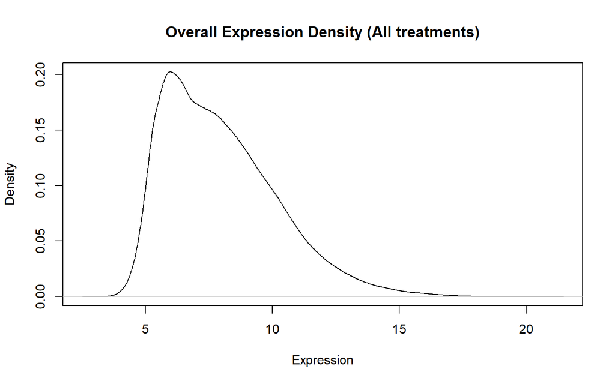

```r
# Expression density plot (all treatments)
plot(
  density(as.numeric(as.matrix(expr_data)), na.rm = TRUE),
  main = "Overall Expression Density (All treatments)",
  xlab = "Expression", ylab = "Density"
)
```

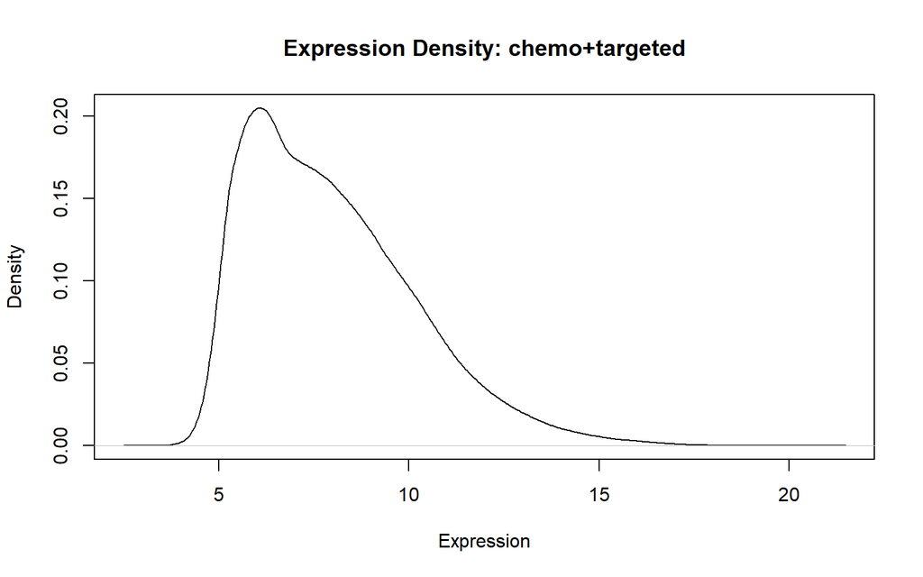

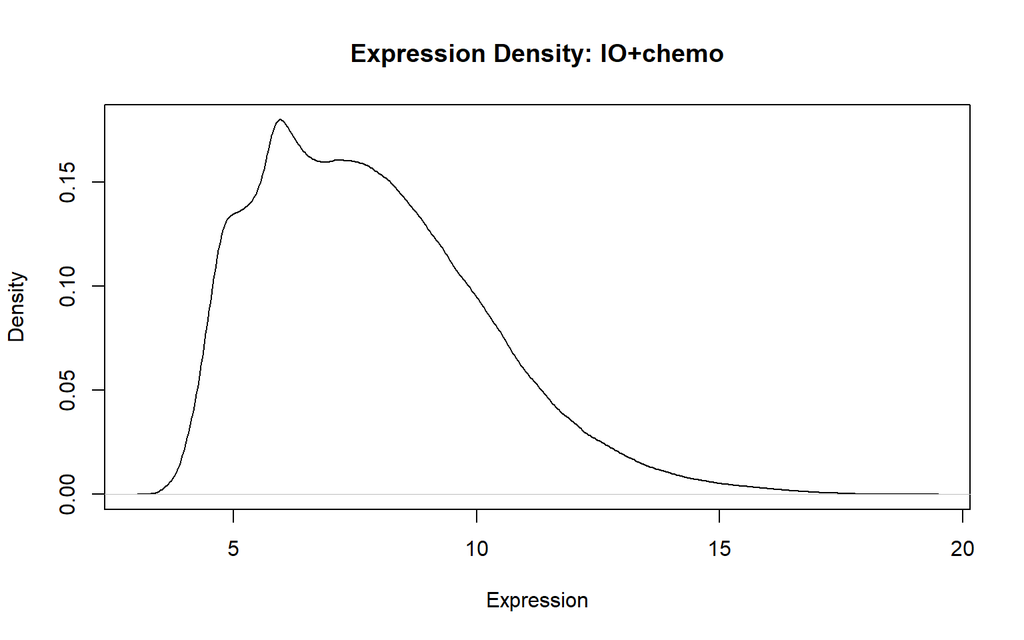

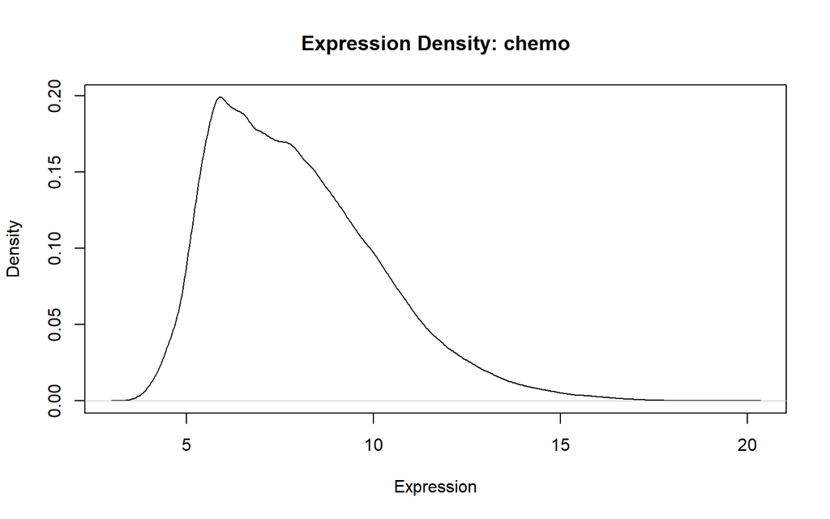

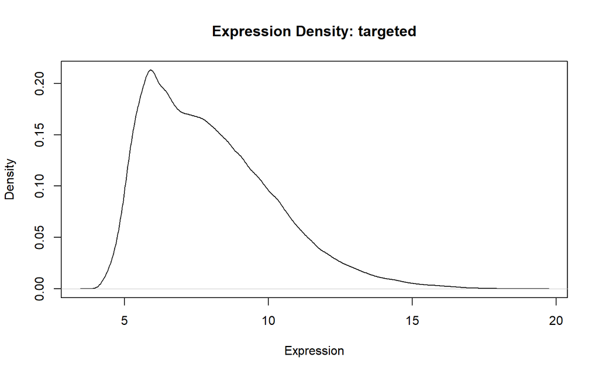

```r
# Expression density by treatment group
treatments <- unique(na.omit(merged_clin$treatment))
for (treat in treatments) {
  patients <- merged_clin$patientid[merged_clin$treatment == treat]
  expr_subset <- expr_data[, colnames(expr_data) %in% patients, drop = FALSE]
  plot(
    density(as.numeric(as.matrix(expr_subset)), na.rm = TRUE),
    main = paste("Expression Density:", treat),
    xlab = "Expression", ylab = "Density"
  )
}
```

### 3. PredictIO Signatures

```r
sig_path <- file.path(input_dir, "predictIO_sigs")
rda_files <- list.files(sig_path, pattern = "\\.rda$", full.names = TRUE)
summary_list <- list()

for (file in rda_files) {
  sig_obj <- get(load(file))
  sig_name <- if ("signature_name" %in% colnames(sig_obj) && length(unique(sig_obj$signature_name)) > 0)
    unique(sig_obj$signature_name)[1]
  else
    tools::file_path_sans_ext(basename(file))

  if (!"gene_name" %in% colnames(sig_obj)) next

  genes <- sig_obj$gene_name
  matched <- intersect(rownames(expr_data), genes)

  summary_list[[sig_name]] <- data.frame(
    signature = sig_name,
    n_genes_total = length(genes),
    n_genes_matched = length(matched),
    matched_genes = paste(sort(matched), collapse = ", ")
  )
}

summary_df <- do.call(rbind, summary_list)

kable(summary_df, caption = "Summary of gene overlap between IO signatures and expression data") %>%
  kable_styling(bootstrap_options = c("striped", "hover", "condensed"), full_width = FALSE) %>%
  scroll_box(height = "400px")
```

Summary of gene overlap between IO signatures and expression data

|  | signature | n_genes_total | n_genes_matched | matched_genes |
| --- | --- | --- | --- | --- |
| ADO_Sidders | ADO_Sidders | 14 | 14 | APP, CASP1, CD81, COL3A1, CREB1, CYBB, FOS, FOXP3, GPI, LAG3, MAPK1, MAPK3, PPARG, PTGS2 |
| APM_Thompson | APM_Thompson | 8 | 8 | B2M, CALR, HSP90AB1, NLRC5, PSMB9, PSME1, PSME3, RFX5 |
| APM_Wang | APM_Wang | 18 | 18 | B2M, CALR, CANX, ERAP1, ERAP2, HLA-A, HLA-B, HLA-C, PDIA3, PSMB10, PSMB5, PSMB6, PSMB7, PSMB8, PSMB9, TAP1, TAP2, TAPBP |
| Bcell_Budczies | Bcell_Budczies | 8 | 8 | BLK, CD19, FCRL2, MS4A1, PNOC, SPIB, TCL1A, TNFRSF17 |
| Bcell_Helmink | Bcell_Helmink | 66 | 58 | ALG13, AREG, ARHGAP24, ARRDC2, BANK1, BCL11A, BTG1, C9orf72, CALM2, CCR7, CD69, CD83, CHD1, CKS2, CREM, CXCR4, DDX27, DDX3Y, DNAJA1, DNAJB1, DNAJB14, EZR, GPR183, HERPUD1, HSPH1, JUND, KDM6B, LY9, MS4… |
| Blood_Friedlander | Blood_Friedlander | 15 | 14 | ADAM17, CDK2, CDKN2A, DPP4, ERBB2, HLA-DRA, ICOS, ITGA4, MYC, NAB2, NRAS, RHOC, TGFB1, TIMP1 |
| C-ECM_Chakravarthy | C-ECM_Chakravarthy | 58 | 55 | A2M, ABI3BP, ACAN, ADAM12, ADAM8, ADAMTS14, COL10A1, COL11A1, COL14A1, COL1A1, COL1A2, COL3A1, COL4A3, COL4A4, COL4A6, COL5A1, COL5A2, COL5A3, COL7A1, COMP, DCN, DDR2, DPT, ECM2, FAP, FBLN1, FBLN5, FG… |
| CCL5-CXCL9_Dangaj | CCL5-CXCL9_Dangaj | 21 | 21 | CCL5, CD2, CD247, CD3E, CD4, CD53, CD86, CD8A, CXCL9, DOCK2, GBP2, GZMK, IL10RA, IL2RB, IRF1, LAPTM5, LCP1, PTPRC, SLC7A7, STAT1, TNFRSF9 |
| CD39-CD8Tcell_Chow | CD39-CD8Tcell_Chow | 23 | 21 | B2M, CD2, CD247, CD96, CXCL13, CXCR6, ENTPD1, GNLY, GZMA, HCST, HLA-B, IKZF3, ITGAL, KLRB1, KLRC1, LCK, LSP1, PDCD1, PTPN22, TNIP3, ZNF683 |
| CD8_Sade-Feldman | CD8_Sade-Feldman | 34 | 32 | BTG2, CD55, CSRNP1, EGR1, FAM177A1, FOSL2, FOXP1, GPR183, IFRD1, IL7R, LMNA, MGAT4A, MYADM, NEU1, NR4A1, NR4A3, PDE4B, PER1, PFKFB3, PIK3R1, REL, RGCC, RGPD5, SKIL, STAT4, TC2N, TCF7, TSC22D2, TSPYL2,… |
| Chemokine_Messina | Chemokine_Messina | 12 | 12 | CCL18, CCL19, CCL2, CCL21, CCL3, CCL4, CCL5, CCL8, CXCL10, CXCL11, CXCL13, CXCL9 |
| CIN25_Carter | CIN25_Carter | 25 | 24 | CCNB2, CCT5, CDC45, CDK1, ESPL1, FEN1, FOXM1, KIF20A, MAD2L1, MCM2, MCM7, MELK, NCAPD2, PCNA, PRC1, RAD51AP1, RFC4, RNASEH2A, TGIF2, TOP2A, TPX2, TRIP13, TTK, UBE2C |
| CIN70_Carter | CIN70_Carter | 70 | 67 | ACTL6A, ASF1B, ATAD2, AURKA, AURKB, CCNB1, CCNB2, CCT5, CDC20, CDC45, CDC6, CDCA3, CDCA8, CDK1, CEP55, CKAP5, CKS2, CMAS, CTPS1, DHCR7, DKC1, ECT2, ELAVL1, ESPL1, EZH2, FEN1, FOXM1, HDGF, KIF20A, KIF4… |
| COX-IS_Bonavita | COX-IS_Bonavita | 24 | 23 | CCL2, CCL5, CD8A, CD8B, CSF3, CXCL1, CXCL10, CXCL11, CXCL2, CXCL9, EOMES, GZMA, GZMB, IFNG, IL12A, IL12B, IL1A, IL1B, IL6, PRF1, STAT1, TBX21, VEGFA |
| CRMA_Shukla | CRMA_Shukla | 5 | 3 | MAGEA12, MAGEA2B, MAGEA6 |
| CYT_Davoli | CYT_Davoli | 7 | 7 | CD2, CD247, CD3E, GZMH, GZMK, NKG7, PRF1 |
| CYT_Rooney | CYT_Rooney | 2 | 2 | GZMA, PRF1 |
| EMT_Thompson | EMT_Thompson | 12 | 12 | AGER, CDH1, CDH3, CLDN4, EPCAM, FN1, MAL2, MMP2, SNAI2, ST14, VIM, ZEB2 |
| EMTstroma_Wang | EMTstroma_Wang | 18 | 18 | CALD1, CALU, COL6A2, COL6A3, CTHRC1, ECM1, EMP3, FBN1, FLNA, FN1, FOXC2, LAMA2, LOX, LRP1, MFAP5, SERPINE2, TNC, VIM |
| IFN_Ayers | IFN_Ayers | 6 | 6 | CXCL10, CXCL9, HLA-DRA, IDO1, IFNG, STAT1 |
| ImmuneCells_Xiong | ImmuneCells_Xiong | 109 | 97 | ADAM21, ALDH1L2, APBB2, APOC2, ARSF, ASAH2, ASPM, BIRC5, C6orf223, CACNG1, CCL18, CD244, CDCA5, CDH1, CEACAM6, CILP2, CLDN7, CORO7, CR2, CRTAM, CYTL1, DHRS9, DLK1, DUSP13, EIF4A2, ENTHD1, FBLN1, FBLN2… |
| ImmuneScore_Roh | ImmuneScore_Roh | 41 | 40 | CCL3, CCL4, CCL5, CCR5, CXCL10, CXCL11, CXCL9, GNLY, GZMA, GZMB, HLA-A, HLA-B, HLA-C, HLA-DMA, HLA-DMB, HLA-DOA, HLA-DOB, HLA-DPA1, HLA-DPB1, HLA-DQA1, HLA-DQA2, HLA-DQB1, HLA-DRA, HLA-DRB1, HLA-E, HL… |
| ImmunoScore_Hao | ImmunoScore_Hao | 76 | 75 | ACAP1, ACP5, AHCYL1, AIM2, ASB2, BIRC5, BTN3A2, CCL13, CCL18, CCL5, CCR2, CCR7, CD2, CD300LF, CD38, CD3D, CD3G, CD6, CD7, CD70, CD8A, CD96, CD97, CDC7, CLECL1, CXCR4, CXCR6, DAXX, DUSP6, EZH2, FADD, F… |
| IMPRES_Auslander | IMPRES_Auslander | 28 | 26 | BTLA, CD200, CD200R1, CD27, CD274, CD276, CD28, CD40, CD80, CD86, CEACAM1, CTLA4, HAVCR2, IDO1, IL2RB, LAG3, PDCD1, PDCD1LG2, PVR, TIGIT, TNFRSF14, TNFRSF18, TNFRSF4, TNFRSF9, TNFSF4, TNFSF9 |
| IMS_Cui | IMS_Cui | 18 | 18 | ADAM12, AXL, BCAT1, CCL13, CCL2, CCL8, CD163, COL6A3, FAP, IL10, INHBA, ISG15, OLFML2B, PDGFRB, SIGLEC1, STC1, TWIST2, VCAN |
| Inflammatory_Thompson | Inflammatory_Thompson | 27 | 27 | CCL5, CCR5, CD274, CD3D, CD3E, CD8A, CIITA, CTLA4, CXCL10, CXCL11, CXCL13, CXCL9, GZMA, GZMB, HLA-DRA, HLA-DRB1, HLA-E, IDO1, IL2RG, ITGAL, LAG3, NKG7, PDCD1, PRF1, PTPRC, STAT1, TAGAP |
| IPS_Charoentong | IPS_Charoentong | 162 | 152 | ACAP1, ADRM1, AHSA1, AIM2, APOL3, ARHGAP10, ATM, ATP10D, B2M, BIRC3, BRIP1, C1GALT1C1, C3AR1, CASP3, CASQ1, CCL20, CCL4, CCL5, CCNB1, CCR2, CCR5, CCR7, CCT6B, CD14, CD160, CD2, CD27, CD274, CD300E, CD… |
| IRG_Ayers | IRG_Ayers | 17 | 17 | CCL5, CD2, CD3D, CD3E, CIITA, CXCL10, CXCL13, CXCR6, GZMB, GZMK, HLA-DRA, HLA-E, IDO1, IL2RG, NKG7, STAT1, TAGAP |
| IRG_Yang | IRG_Yang | 11 | 11 | ANGPTL5, IFI30, IGF1, LEPR, NR2F2, NRP1, PLAU, PRL, PRLHR, TNFRSF10A, TNFRSF10B |
| KDM5A_Wang | KDM5A_Wang | 8 | 8 | ANO3, FAM13C, HMCN1, IKZF3, KDM5A, MVB12B, PDE1A, RIOK1 |
| M1_Hwang | M1_Hwang | 13 | 12 | CBLB, CCR7, CD27, CD48, FOXO1, HLA-B, HLA-G, IFIH1, IKZF4, LAMP3, NFKBIA, SAMHD1 |
| Macrophage_Danaher | Macrophage_Danaher | 4 | 4 | CD163, CD68, CD84, MS4A4A |
| MHC-I_Liu | MHC-I_Liu | 8 | 8 | B2M, HLA-A, HLA-B, HLA-C, HLA-E, HLA-F, TAP1, TAP2 |
| MHC-II_Liu | MHC-II_Liu | 13 | 13 | HLA-DMA, HLA-DMB, HLA-DOA, HLA-DOB, HLA-DPA1, HLA-DPB1, HLA-DQA1, HLA-DQA2, HLA-DQB1, HLA-DQB2, HLA-DRA, HLA-DRB1, HLA-DRB5 |
| MPS_Guijarro | MPS_Guijarro | 45 | 42 | AKR1C3, ALX1, BMP1, BRD7, CRTAC1, DTD1, ECEL1, ERC2, FAM110C, FUT9, GABRA2, GAP43, GREM1, GRSF1, HCN1, HECW1, KLHL1, KRT12, LHFPL4, LTA4H, NEFM, NETO1, NKX2-2, OCIAD2, OTOP1, OXCT1, PDE3B, PLXNC1, PTP… |
| Myeloid-DC_Helmink | Myeloid-DC_Helmink | 6 | 5 | CD1A, CD1B, CD1E, CLEC10A, CLIC2 |
| NonResponse_Chen | NonResponse_Chen | 258 | 241 | ACTL6A, ALYREF, ANLN, APOBEC3A, ASPM, ATAD2, AUNIP, AURKA, AURKB, BIRC5, BLM, BOP1, BORA, BRIX1, BUB1, BYSL, CBX2, CCDC138, CCDC167, CCNA2, CCNB1, CCNB2, CCNE1, CCNE2, CCT3, CDC123, CDC20, CDC25A, CDC… |
| PDL1_Nishino | PDL1_Nishino | 3 | 3 | CD274, PDCD1, PDCD1LG2 |
| peri-Tcell_Hwang | peri-Tcell_Hwang | 3 | 3 | GPR18, HLA-DOA, STAT1 |
| PredictIO_Bareche | PredictIO_Bareche | 100 | 98 | ABCD2, ANP32E, APOL6, ARHGAP24, B2M, C14orf132, CA2, CD3E, CD3G, CD83, CD8A, CRYAB, CST7, CTSW, CXCL10, CXCL11, CXCL13, CXCL9, CXCR6, DAPK1, DLG4, DOCK8, EAF1, EOMES, EPB41, ERI1, F11R, F2RL1, FASLG, … |
| proliferation_Pabla | proliferation_Pabla | 10 | 9 | BUB1, CCNB2, CDK1, CDKN3, FOXM1, MAD2L1, MELK, MKI67, TOP2A |
| PTEN-MITF_Cabrita | PTEN-MITF_Cabrita | 263 | 244 | ADAMDEC1, ANGPT1, ANKRD22, ANTXR1, APOE, ARL6IP5, ASB9, ATP2B1, AUTS2, BACE2, BCAT1, BCL2A1, BHLHE41, BIRC3, BIRC7, C2orf88, CABLES1, CADM1, CAPN3, CASP1, CBR3, CBX2, CCL5, CD38, CD3D, CD44, CD48, CD5… |
| Response_Chen | Response_Chen | 443 | 414 | ABI3, ABI3BP, ACAP1, ACSL5, ACVRL1, ADA, ADAM7, ADAP2, ADCY7, AIM2, AKNA, ALOX5, ANXA2R, APBB1IP, APOBEC3C, APOBEC3G, APOBEC3H, APOE, ARHGAP15, ARHGAP25, ARHGAP30, ARHGAP4, ARHGAP9, ARHGEF1, ARHGEF18,… |
| STAT1_Care | STAT1_Care | 39 | 37 | ANKRD22, APOL3, APOL6, CCL4, CCR5, CD2, CST7, CXCL10, CXCL11, CXCL9, CXCR6, FCER1G, FCGR1B, FGL2, GBP1, GBP2, GBP4, GBP5, GIMAP4, GIMAP5, GZMA, GZMK, IDO1, IFIT3, IFNG, IRF1, LAG3, LAP3, PRF1, SERPINA… |
| Tcell-exclusion_Arnon | Tcell-exclusion_Arnon | 108 | 94 | APOD, APOE, ATIC, ATP1A1, B2M, BTF3, CAPN3, CD63, CDH1, CHCHD2, CTSD, DAAM2, EEF1G, EIF3G, EIF3M, EIF4A1, ENO1, EXOSC4, FARSA, GAPDH, GPNMB, HLA-A, HLA-B, HLA-C, HLA-F, HNRNPA1, HPS5, HSP90AA1, IFI27,… |
| Teff-IFNG_Fehrenbacher | Teff-IFNG_Fehrenbacher | 8 | 8 | CD8A, CXCL10, CXCL9, EOMES, GZMA, GZMB, IFNG, TBX21 |
| Teff_McDermott | Teff_McDermott | 5 | 5 | CD274, CD8A, EOMES, IFNG, PRF1 |
| TGFB_Mariathasan | TGFB_Mariathasan | 19 | 17 | ACTA2, ACTG2, ADAM12, ADAM19, CNN1, COL4A1, CTPS1, FSTL3, HSPB1, IGFBP3, PXDC1, SEMA7A, SH3PXD2A, TAGLN, TGFBI, TNS1, TPM1 |
| TIS_Damotte | TIS_Damotte | 18 | 18 | CCL5, CD27, CD274, CD276, CD8A, CMKLR1, CXCL9, CXCR6, HLA-DQA1, HLA-DRB1, HLA-E, IDO1, LAG3, NKG7, PDCD1LG2, PSMB10, STAT1, TIGIT |
| TLS_Cabrita | TLS_Cabrita | 9 | 9 | CCR6, CD1D, CD79B, CETP, EIF1AY, LAT, PTGDS, RBP5, SKAP1 |
| TUMOR-VASCULATURE-UP_Lu | TUMOR-VASCULATURE-UP_Lu | 29 | 29 | ADAM12, ADAP2, CHN1, CMTM8, COL5A3, EGFL6, FJX1, FOXF2, FZD10, HOPX, HSPA6, ISG15, LCP2, MMP9, MUC1, MXRA5, PAMR1, PLXDC1, PMAIP1, POSTN, RPS11, SCIN, SPP1, STC1, TNFAIP6, TNFRSF21, TWIST1, VCAN, WDR7… |
| VIGex_Hernando-Calvo | VIGex_Hernando-Calvo | 12 | 12 | CD274, CTLA4, CXCL10, CXCL11, CXCL9, FOXP3, GZMA, GZMB, IFNG, IL7R, PDCD1, PRF1 |

### 4. DE Analysis (R vs NR) — Full Cohort

performs differential expression (DE) analysis using limma to find genes that differ between Responders vs Non-Responders across all 982 patients.

```r
# Design and model
design_full <- model.matrix(~ clin_data$response)
fit_full <- eBayes(lmFit(expr_data, design_full))
top_full <- topTable(fit_full, sort.by = "P", n = Inf)
top_full$Gene <- rownames(top_full)
fc_cutoff <- 1.5
p_cutoff <- 0.05
top_n_labels <- Inf

# Save results
write.table(top_full, file.path(output_dir, "DEG_analysis", "full_limma_fit.txt"),
            sep = "\t", quote = FALSE, row.names = FALSE)

DT::datatable(round(top_full[sapply(top_full, is.numeric)], 3),
              caption = "TopTable - Full Cohort")
```

|  | logFC | AveExpr | t | P.Value | adj.P.Val | B |
| --- | --- | --- | --- | --- | --- | --- |
| TXNDC5 | 0.544 | 11.685 | 10.54 | 0 | 0 | 45.061 |
| RERG | -0.975 | 9.007 | -9.667 | 0 | 0 | 37.224 |
| CD38 | 0.899 | 8.021 | 9.447 | 0 | 0 | 35.337 |
| GBP5 | 0.957 | 10.926 | 9.211 | 0 | 0 | 33.355 |
| ACADSB | -0.581 | 7.985 | -9.187 | 0 | 0 | 33.161 |
| ESR1 | -0.789 | 7.051 | -9.18 | 0 | 0 | 33.097 |
| GZMB | 0.913 | 9.649 | 9.037 | 0 | 0 | 31.918 |
| SLAMF7 | 0.796 | 9.293 | 9.008 | 0 | 0 | 31.681 |
| IL21R | 0.654 | 8.654 | 8.978 | 0 | 0 | 31.439 |
| THSD4 | -0.755 | 7.213 | -8.902 | 0 | 0 | 30.825 |

[output cut: 17537 more lines]

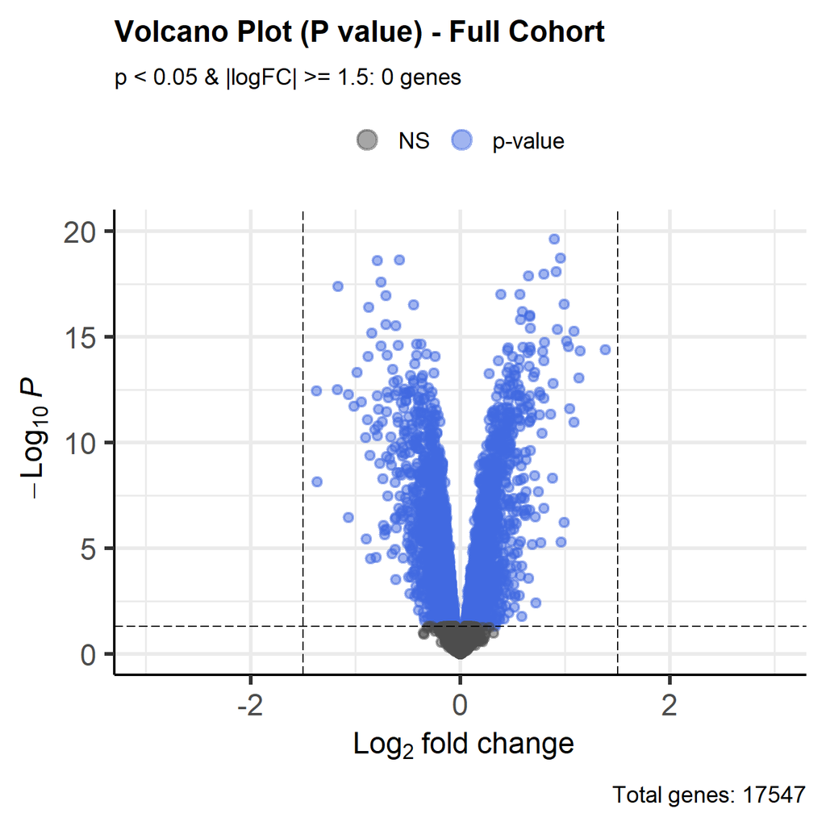

```r
# Clean numeric columns for volcano
top_full.clean <- top_full[, sapply(top_full, is.numeric)]
rownames(top_full.clean) <- rownames(top_full)

# Labels: top 20 red dots only
red_genes_pval <- top_full.clean[
  top_full.clean$P.Value < p_cutoff & abs(top_full.clean$logFC) >= fc_cutoff,
]
red_genes_pval <- head(red_genes_pval[order(red_genes_pval$P.Value), ], top_n_labels)
selectLab_pval <- rownames(red_genes_pval)

red_genes_fdr <- top_full.clean[
  top_full.clean$adj.P.Val < p_cutoff & abs(top_full.clean$logFC) >= fc_cutoff,
]
red_genes_fdr <- head(red_genes_fdr[order(red_genes_fdr$adj.P.Val), ], top_n_labels)
selectLab_fdr <- rownames(red_genes_fdr)

# Counts
n_pval_full <- sum(top_full.clean$P.Value < p_cutoff & abs(top_full.clean$logFC) >= fc_cutoff)
n_fdr_full <- sum(top_full.clean$adj.P.Val < p_cutoff & abs(top_full.clean$logFC) >= fc_cutoff)

# Volcano plot: P-value
print(EnhancedVolcano(top_full.clean,
  lab = rownames(top_full.clean),
  selectLab = selectLab_pval,
  x = 'logFC', y = 'P.Value',
  pCutoff = p_cutoff, FCcutoff = fc_cutoff,
  xlim = c(-3, 3), ylim = c(0, 20),
  labSize = 3.5,
  labCol = "black",
  drawConnectors = TRUE,
  widthConnectors = 0.5,
  colConnectors = "grey50",
  maxoverlapsConnectors = Inf,
  title = "Volcano Plot (P value) - Full Cohort",
  subtitle = paste0("p < ", p_cutoff, " & |logFC| >= ", fc_cutoff, ": ", n_pval_full, " genes"),
  caption = paste0("Total genes: ", nrow(top_full.clean))
))
```

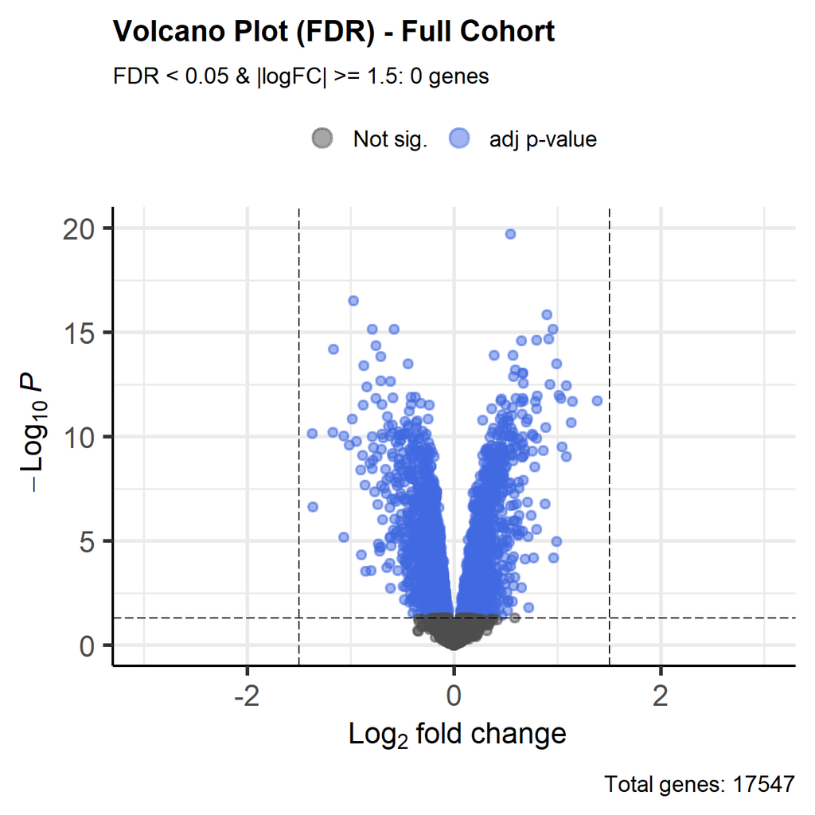

```r
# Volcano plot: FDR
print(EnhancedVolcano(top_full.clean,
  lab = rownames(top_full.clean),
  selectLab = selectLab_fdr,
  x = 'logFC', y = 'adj.P.Val',
  pCutoff = p_cutoff, FCcutoff = fc_cutoff,
  xlim = c(-3, 3), ylim = c(0, 20),
  labSize = 3.5,
  labCol = "black",
  drawConnectors = TRUE,
  widthConnectors = 0.5,
  colConnectors = "grey50",
  maxoverlapsConnectors = Inf,
  legendLabels = c('Not sig.', 'Log FC', 'adj p-value', 'adj p-value & Log FC'),
  title = "Volcano Plot (FDR) - Full Cohort",
  subtitle = paste0("FDR < ", p_cutoff, " & |logFC| >= ", fc_cutoff, ": ", n_fdr_full, " genes"),
  caption = paste0("Total genes: ", nrow(top_full.clean))
))
```

```r
# Summary
sig_genes_full <- rownames(top_full)[top_full$adj.P.Val < p_cutoff & abs(top_full$logFC) >= fc_cutoff]
cat("DE genes (adj.P.Val <", p_cutoff, "):", sum(top_full$adj.P.Val < p_cutoff), "\n")
```

DE genes (adj.P.Val < 0.05 ): 5870

```r
cat("DE genes (adj.P.Val <", p_cutoff, "& |logFC| >=", fc_cutoff, "):", length(sig_genes_full), "\n")
```

DE genes (adj.P.Val < 0.05 & |logFC| >= 1.5 ): 0

```r
cat("Significant gene names:\n")
```

Significant gene names:

```r
print(sig_genes_full)
```

character(0)

```r
# Summary table for full cohort
genes_full_fc1.0 <- rownames(top_full)[top_full$adj.P.Val < p_cutoff & abs(top_full$logFC) >= 1.0]
genes_full_fc1.5 <- rownames(top_full)[top_full$adj.P.Val < p_cutoff & abs(top_full$logFC) >= fc_cutoff]

summary_full <- data.frame(
  Cohort = "Full (982 patients)",
  FDR_sig = sum(top_full$adj.P.Val < p_cutoff),
  FDR_FC1.0 = length(genes_full_fc1.0),
  FDR_FC1.5 = length(genes_full_fc1.5),
  Top_Genes_FC1.0 = ifelse(length(genes_full_fc1.0) == 0, "–", paste(genes_full_fc1.0, collapse = ", ")),
  Top_Genes_FC1.5 = ifelse(length(genes_full_fc1.5) == 0, "–", paste(genes_full_fc1.5, collapse = ", "))
)

rownames(summary_full) <- NULL
colnames(summary_full) <- c("Cohort", "FDR < 0.05",
                              "FDR & abs(logFC) >= 1.0",
                              "FDR & abs(logFC) >= 1.5",
                              "Genes (logFC >= 1.0)",
                              "Genes (logFC >= 1.5)")

kable(summary_full, row.names = FALSE,
      caption = "Summary of DE Genes - Full Cohort") %>%
  kable_styling(bootstrap_options = c("striped", "hover", "condensed"), full_width = FALSE) %>%
  scroll_box(height = "400px")
```

Summary of DE Genes - Full Cohort

| Cohort | FDR < 0.05 | FDR & abs(logFC) >= 1.0 | FDR & abs(logFC) >= 1.5 | Genes (logFC >= 1.0) | Genes (logFC >= 1.5) |
| --- | --- | --- | --- | --- | --- |
| Full (982 patients) | 5870 | 15 | 0 | SCUBE2, CXCL9, IDO1, CXCL13, S100A8, CCL18, S100A9, NKAIN1, AGR3, NPY1R, GFRA1, UBD, MMP1, TFF1, AGR2 | – |

```r
write.csv(summary_full,
          file = file.path(output_dir, "DEG_analysis", "DE_summary_full_cohort.csv"),
          row.names = FALSE)
```

### 5. Pathway Enrichment — Full Cohort

#### MSigDB Hallmark Gene Sets

- Gene sets from [MSigDB](https://www.gsea-msigdb.org/gsea/msigdb/human/collections.jsp#H)
- Analysis: **GSEA using the `fgsea` R package**
- Input: ranked gene list from differential expression results

```r
# Load hallmark gene sets
pathwaysDF <- msigdbr("Homo sapiens", category = "H")
pathwaysH <- split(as.character(pathwaysDF$gene_symbol), pathwaysDF$gs_name)

# Create ranked gene list
ranks <- top_full$logFC
names(ranks) <- top_full$Gene
ranks <- sort(ranks, decreasing = TRUE)

# Run GSEA
fgseaRes <- fgsea(pathways = pathwaysH, stats = ranks, nproc = 1)
```

[output not shown]

```r
fgseaRes <- na.omit(fgseaRes)

fgseaResTidy <- fgseaRes %>%
  as_tibble() %>%
  arrange(desc(NES)) %>%
  mutate(leadingEdge = sapply(leadingEdge, paste, collapse = ";"))
fgseaResTidy <- fgseaResTidy[order(fgseaResTidy$padj), ]

kable(fgseaResTidy) %>%
  kable_styling(bootstrap_options = c("striped", "hover", "condensed"), full_width = FALSE) %>%
  scroll_box(height = "400px")
```

| pathway | pval | padj | log2err | ES | NES | size | leadingEdge |
| --- | --- | --- | --- | --- | --- | --- | --- |
| HALLMARK_INTERFERON_GAMMA_RESPONSE | 0.0000000 | 0.0000000 | 1.8372250 | 0.7882392 | 3.4085436 | 194 | CXCL9;IDO1;CD38;SLAMF7;CXCL10;CCL5;CXCL11;GZMA;TAP1;GBP4;SOD2;IL2RB;BATF2;STAT1;IRF4;PSMB9;ISG20;CCL2;ICAM1;PFKP;CCL7;XCL1;HLA-DRB1;BANK1;IFI30;IRF1;HLA-A;SOCS1;ITGB7;ZBP1;HLA-DMA;IL10RA;HLA-B;CD74;VC… |
| HALLMARK_ALLOGRAFT_REJECTION | 0.0000000 | 0.0000000 | 1.7624393 | 0.7691086 | 3.3340788 | 195 | CXCL9;CXCL13;GZMB;CCL13;CCL5;CD2;CD79A;CD3D;LTB;CCL4;GZMA;TAP1;LCK;IL2RB;STAT1;IRF4;CD3G;CD247;CDKN2A;CXCR3;CCL2;CCR5;ICAM1;CCL7;CCL19;HLA-DRA;HLA-E;IFNG;MMP9;SIT1;CD8A;FASLG;ZAP70;HLA-A;SOCS1;HCLS1;C… |
| HALLMARK_ESTROGEN_RESPONSE_EARLY | 0.0000000 | 0.0000000 | 1.4099514 | -0.6888435 | -2.8937737 | 190 | TFF1;NPY1R;GFRA1;CA12;TFF3;PDZK1;SLC39A6;SLC7A2;THSD4;CCND1;MAPT;ANXA9;ELOVL2;MSMB;STC2;SYBU;DHRS2;PGR;MLPH;ABCA3;IGF1R;SLC19A2;SLC22A5;ABAT;MAST4;AR;MYB;BCL2;SLC27A2;RET;ADCY1;NRIP1;GREB1;KRT18;SLC1A… |
| HALLMARK_INFLAMMATORY_RESPONSE | 0.0000000 | 0.0000000 | 1.2871037 | 0.6544343 | 2.8415846 | 197 | CXCL9;MARCO;LAMP3;CXCL10;CCL5;CXCL11;CCR7;LCK;IL2RB;CCL2;ICAM1;CXCR6;CCL7;CCL17;IRF1;GPR183;CYBB;CD48;IL10RA;SLAMF1;CD70;AQP9;LCP2;TLR2;ADM;IL7R;LYN;CD69;EDN1;TNFSF10;EBI3;RNF144B;FPR1;IL18RAP;PLAUR;I… |
| HALLMARK_INTERFERON_ALPHA_RESPONSE | 0.0000000 | 0.0000000 | 1.2627399 | 0.7867012 | 3.0597511 | 94 | LAMP3;CXCL10;CXCL11;TAP1;GBP4;BATF2;PSMB9;ISG20;IFI30;IRF1;HLA-C;CD74;CASP1;GBP2;OASL;SAMD9L;USP18;C1S;IL15;NCOA7;EPSTI1;IFIH1;B2M;PSMB8;NMI;UBE2L6;RSAD2;IFI44L;RTP4;LAP3;MX1;SELL;PARP12;IFI44;IFIT3;O… |
| HALLMARK_E2F_TARGETS | 0.0000000 | 0.0000000 | 1.1146645 | 0.6093810 | 2.6416610 | 195 | CDKN2A;CCNE1;MELK;KIF2C;TFRC;CDC20;EZH2;MYBL2;DLGAP5;NASP;DEK;MCM5;CHEK1;SPAG5;MCM2;CDK1;MTHFD2;LBR;HMGB3;MCM6;PTTG1;DONSON;CDCA8;HMGA1;MCM4;CDC25B;TUBB;TOP2A;AURKA;MCM3;KPNA2;KIF4A;ANP32E;CKS1B;CCNB2… |
| HALLMARK_COMPLEMENT | 0.0000000 | 0.0000000 | 1.0672100 | 0.5917075 | 2.5742219 | 198 | S100A9;GZMB;CCL5;GZMA;GZMK;LCK;CXCL1;C1QA;PSMB9;PLA2G7;CP;IRF1;LTF;KYNU;C1QC;PLEK;CTSC;C2;CTSV;LCP2;CASP1;APOBEC3G;SPOCK2;LYN;CTSS;FCER1G;APOC1;CEBPB;SERPING1;PIM1;PLAUR;CASP5;C1S;CASP4;DUSP6;CTSL;C3;… |
| HALLMARK_TNFA_SIGNALING_VIA_NFKB | 0.0000000 | 0.0000000 | 1.0476265 | 0.5844195 | 2.5375768 | 197 | CXCL10;CCL5;CXCL11;CCL4;TAP1;SOD2;CXCL1;CCL2;ICAM1;IRF1;BIRC3;KYNU;GPR183;PLEK;TLR2;IL7R;CD83;CD69;EDN1;NFIL3;CEBPB;BCL2A1;PLAUR;IL1B;TNFAIP8;PTGER4;IFIH1;IL18;TRAF1;PLAU;RCAN1;NFKBIE;TNF;EGR2;IL15RA;… |
| HALLMARK_G2M_CHECKPOINT | 0.0000000 | 0.0000000 | 1.0073180 | 0.5739736 | 2.4757410 | 188 | KIF2C;CDC45;CENPA;CDC20;TTK;EZH2;MYBL2;NASP;ODC1;BUB1;SLC7A5;NDC80;MCM5;CHEK1;MCM2;CDK1;LBR;HMGB3;MCM6;UCK2;PTTG1;HMGA1;TPX2;EXO1;CDC25B;CCNA2;UBE2C;TOP2A;AURKA;MCM3;E2F3;KPNA2;MT2A;KIF4A;CKS1B;CCNB2;… |
| HALLMARK_IL6_JAK_STAT3_SIGNALING | 0.0000000 | 0.0000000 | 0.9759947 | 0.7017615 | 2.6969283 | 87 | CXCL9;CXCL13;CD38;CXCL10;CXCL11;LTB;STAT1;CXCL1;CCL7;IRF1;SOCS1;IL2RG;TLR2;TNFRSF21;EBI3;PIM1;IL1B;CD14;IL2RA;TNF;IL15RA;CCR1;IFNGR1;CD44;FAS;IL7;BAK1;IL17RA;IL6;MYD88;CSF2RA;IL3RA;IL1R2;TNFRSF1B;IFNG… |
| HALLMARK_ESTROGEN_RESPONSE_LATE | 0.0000000 | 0.0000000 | 0.9653278 | -0.5630857 | -2.3678002 | 192 | TFF1;SCUBE2;NPY1R;AGR2;CA12;TFF3;PDZK1;DNAJC12;CCND1;MAPT;ANXA9;SERPINA5;SERPINA3;DHRS2;PGR;COX6C;ABCA3;CACNA2D2;SLC22A5;TPSAB1;CHST8;MYB;BCL2;SLC27A2;RET;NRIP1;TSPAN13;GPER1;IL6ST;CELSR2;CXCL14;SCNN1… |
| HALLMARK_MTORC1_SIGNALING | 0.0000000 | 0.0000000 | 0.8986712 | 0.5440736 | 2.3527104 | 194 | PSAT1;PHGDH;DAPP1;FADS2;IFI30;CORO1A;PDK1;CTSC;TFRC;DDIT4;SLA;PNP;NFIL3;FGL2;CXCR4;GLRX;GMPS;BUB1;SLC7A5;MCM2;MTHFD2;ASNS;MCM4;ITGB2;LGMN;ACTR3;ENO1;TUBA4A;DHCR7;AURKA;IFRD1;TES;CFP;ARPC5L;PGM1;SRD5A1… |
| HALLMARK_IL2_STAT5_SIGNALING | 0.0000000 | 0.0000000 | 0.8012156 | 0.5087151 | 2.1998111 | 194 | CXCL10;LTB;GBP4;IL2RB;ICOS;IRF4;CCNE1;CD79B;CD48;SOCS1;IL10RA;TNFRSF8;PNP;TNFRSF21;BATF3;CD83;GLIPR2;NFIL3;FGL2;TNFSF10;EOMES;PIM1;IL2RA;TNFRSF4;IRF8;ODC1;TRAF1;UCK2;CTLA4;CAPG;BATF;TNFRSF9;PLIN2;IFNG… |
| HALLMARK_MYC_TARGETS_V1 | 0.0000000 | 0.0000000 | 0.7881868 | 0.4983984 | 2.1521791 | 193 | PSMD3;CDC45;CDC20;PSMB3;DEK;ODC1;MCM5;MCM2;MCM6;MCM4;CCNA2;RFC4;SRPK1;IFRD1;TYMS;KPNA2;PRDX4;HDAC2;CTPS1;ILF2;SYNCRIP;MCM7;PSMB2;RANBP1;EIF4A1;CUL1;MAD2L1;FBL;PPM1G;YWHAQ;PABPC1;TFDP1;XRCC6;SNRPA1;PSM… |
| HALLMARK_KRAS_SIGNALING_UP | 0.0000001 | 0.0000002 | 0.7049757 | 0.4663767 | 2.0219653 | 191 | CXCL10;MYCN;ADAMDEC1;ST6GAL1;LCP1;SLPI;MMP9;HSD11B1;BIRC3;KCNN4;IL10RA;LAPTM5;IL2RG;GALNT3;TMEM176B;IL7R;CTSS;FCER1G;PLAUR;IL1B;CD37;CXCR4;ADAM8;GLRX;IRF8;TRAF1;PSMB8;MPZL2;PLAU;TMEM176A;CLEC4A;DUSP6;… |
| HALLMARK_CHOLESTEROL_HOMEOSTASIS | 0.0006244 | 0.0019512 | 0.4772708 | 0.4897156 | 1.8343352 | 72 | FADS2;S100A11;CBS;NFIL3;PLAUR;LGMN;DHCR7;SREBF2;PNRC1;FDPS;GLDC;CXCL16;FBXO6;IDI1;MVD;ACAT2;PLSCR1;SCD;HMGCS1;STARD4;LGALS3;LDLR;FABP5;SQLE;ANXA5;TNFRSF12A;ATF3;ACTG1;EBP;ECH1;ATF5;PCYT2;NSDHL |
| HALLMARK_UNFOLDED_PROTEIN_RESPONSE | 0.0011799 | 0.0031265 | 0.4550599 | 0.4222433 | 1.6722264 | 106 | PSAT1;CCL2;SPCS3;DDIT4;CEBPB;SLC7A5;HERPUD1;MTHFD2;ASNS;NABP1;CKS1B;VEGFA;PDIA5;KDELR3;DNAJB9;ATF4;EIF4G1;PDIA6;EIF4A1;TUBB2A;EDEM1;CHAC1;HSP90B1;SSR1;CEBPG;HYOU1;CALR;GEMIN4;PREB;TATDN2;ALDH18A1;ATF3… |
| HALLMARK_APOPTOSIS | 0.0011881 | 0.0031265 | 0.4550599 | 0.3811740 | 1.5981561 | 159 | CD38;CD2;TAP1;SOD2;ISG20;IRF1;BIRC3;FASLG;ERBB2;CASP1;CD69;TNFSF10;IL1B;CD14;CASP4;IL18;TNF;PRF1;BID;CDC25B;TOP2A;IFNGR1;CD44;CFLAR;GCH1;FAS;SAT1;BTG3;IGF2R;TSPO;IL6;CCND2;MCL1;ANXA1 |
| HALLMARK_MYOGENESIS | 0.0011600 | 0.0031265 | 0.4550599 | -0.3596906 | -1.5223480 | 196 | TNNT1;STC2;PPP1R3C;CACNA1H;AGL;SPDEF;CACNG1;MYH11;ADCY9;CAMK2B;HSPB8;PGAM2;PVALB;OCEL1;ERBB3;PFKM;CLU;CD36;BAG1;NQO1;LAMA2;SGCD;BHLHE40;TNNC2;ITGA7;TNNT3;FKBP1B;SSPN;MYOM2;CKMT2;MYBPH;COX7A1;SH3BGR;PP… |
| HALLMARK_MITOTIC_SPINDLE | 0.0013173 | 0.0032931 | 0.4550599 | 0.3616067 | 1.5701132 | 197 | KIF2C;TTK;DLGAP5;BUB1;NDC80;CDC42EP1;CDK1;TPX2;ANLN;TOP2A;TUBA4A;AURKA;KIF4A;CCNB2;KIF11;PIF1;BIRC5;MARCKS;ARHGAP4;LMNB1;FBXO5;ARHGAP27;CENPE;CENPF;BIN1;INCENP;NCK1;ECT2;SUN2;PLK1;KIF15;FLNA;SMC4;KIF2… |
| HALLMARK_PI3K_AKT_MTOR_SIGNALING | 0.0035519 | 0.0084568 | 0.4317077 | 0.4097970 | 1.6093864 | 104 | LCK;DAPP1;FASLG;PDK1;IL2RG;SLA;PRKCB;CXCR4;CDK1;PFN1;ACTR3;MAPK1;E2F1;MYD88;CFL1;NCK1;RPS6KA3;NFKBIB;HSP90B1;ACTR2;STAT2;MAP2K3;CALR;MAP3K7;PPP1CA;PAK4;NOD1;TIAM1;SFN;TRAF2;RAF1;CAB39;ARF1;CDK4;RPS6KA… |
| HALLMARK_COAGULATION | 0.0038692 | 0.0087935 | 0.4317077 | 0.3790204 | 1.5574326 | 137 | MMP1;KLK8;C1QA;MMP9;MMP3;PLEK;MMP7;C2;CTSV;APOC1;SERPING1;FGG;C1S;PLAU;DUSP6;C3;CTSH;LGMN;SH2B2;C1R;FYN;PREP;APOC2;CTSB |
| HALLMARK_P53_PATHWAY | 0.0073817 | 0.0160472 | 0.4070179 | 0.3373912 | 1.4627514 | 191 | TAP1;KLK8;CDKN2A;KRT17;CLCA2;IFI30;SOCS1;DDIT4;CASP1;SDC1;TM4SF1;PERP;TCN2;CD82;ST14;LDHB;ADA;RHBDF2;STEAP3;UPP1;S100A4;FAS;NDRG1;BAK1;SAT1;CCND2;ALOX15B;CEBPA;GM2A;DRAM1;TPD52L1;VDR;RGS16;S100A10;CTS… |
| HALLMARK_HYPOXIA | 0.0111061 | 0.0227065 | 0.3807304 | 0.3305602 | 1.4331360 | 191 | ISG20;PFKP;CP;TMEM45A;CSRP2;PDK1;PLAC8;DDIT4;ADM;NFIL3;PIM1;PLAUR;CXCR4;GLRX;EDN2;CHST2;LDHC;TNFAIP3;ENO1;PLIN2;TES;S100A4;MT2A;SLC2A5;PNRC1;ZFP36;NAGK;NDRG1;RRAGD;PGM1;TGM2;VEGFA;VLDLR;ADORA2B;IL6;TP… |
| HALLMARK_APICAL_JUNCTION | 0.0113533 | 0.0227065 | 0.3807304 | 0.3228006 | 1.3953037 | 190 | GRB7;CDH3;ICAM1;MMP9;ACTG2;VCAM1;SYK;CD274;MDK;RAC2;TRAF1;MPZL2;ICAM2;MSN;ICAM4;CX3CL1;PFN1;PTPRC;CNN2;ALOX15B;MVD;ADAM15;TGFBI;NRTN;CLDN4;ZYX;CAP1;ACTB;RSU1;VASP;CD99;ATP1A3;EPB41L2;ARPC2;ACTN1;YWHAH… |
| HALLMARK_MYC_TARGETS_V2 | 0.0133713 | 0.0257140 | 0.3807304 | 0.4380292 | 1.5835138 | 57 | MCM5;MCM4;DUSP2;BYSL;PLK1;NIP7;SRM;PUS1;NOP2;PPAN;NDUFAF4;RCL1;PPRC1;PES1;CDK4;MYBBP1A;MAP3K6;PLK4;LAS1L;WDR74;SLC19A1;MPHOSPH10;NOLC1;NOP16;NOP56;TMEM97;EXOSC5;SUPV3L1;WDR43 |
| HALLMARK_GLYCOLYSIS | 0.0146305 | 0.0270936 | 0.3807304 | 0.3199596 | 1.3892796 | 197 | B3GNT3;ISG20;PFKP;CENPA;DDIT4;SDC1;MED24;NASP;CXCR4;GLRX;SPAG4;CHST2;CDK1;SLC16A3;LDHC;KIF20A;ENO1;AURKA;CD44;AKR1A1;RRAGD;DSC2;STMN1;CHST6;VEGFA;VLDLR;ADORA2B;B3GAT1;KDELR3;HMMR;TGFBI;ME1;SAP30;UGP2;… |
| HALLMARK_UV_RESPONSE_UP | 0.0221965 | 0.0382699 | 0.3524879 | 0.3390797 | 1.4063406 | 154 | TAP1;SOD2;STARD3;HLA-F;CCNE1;ICAM1;GAL;IRF1;TFRC;CTSV;LYN;GGH;ASNS;BID;CHRNA5;RFC4;TUBA4A;MGAT1;FEN1;FMO1;GCH1;CCK;BAK1;BTG3;IL6;ARRB2;AMD1;LHX2;RPN1;AGO2;RAB27A;ALAS1;CASP3;CEBPG;PARP2;STIP1;CXCL2;JU… |
| HALLMARK_UV_RESPONSE_DN | 0.0216879 | 0.0382699 | 0.3524879 | -0.3457458 | -1.3998288 | 138 | IGF1R;IRS1;IGFBP5;SRI;GJA1;APBB2;CDON;INPP4B;AMPH;MMP16;MAGI2;SLC22A18;PRKCE;SMAD3;BHLHE40;DDAH1;PDGFRB;CDKN1B;ICA1;MGMT;CAV1;ITGB3;SYNJ2;RUNX1;AGGF1;CAP2;PTPRM;LAMC1;MIOS;COL1A2;BDNF;DBP;TGFBR3;SNAI2… |
| HALLMARK_ADIPOGENESIS | 0.0528169 | 0.0880282 | 0.2616635 | -0.3046008 | -1.2808597 | 192 | QDPR;CYP4B1;REEP6;HSPB8;EPHX2;REEP5;SPARCL1;LTC4S;PTGER3;DGAT1;CD36;SULT1A1;CMBL;SNCG;PDCD4;DBT;LIPE;ITGA7;FABP4;LEP;SSPN;ADIPOR2;CIDEA;ACADS;LIFR;ADCY6;OMD;MRAP;LPCAT3;GPAM;GPHN;ADIPOQ;CD151;UQCRQ;TO… |
| HALLMARK_REACTIVE_OXYGEN_SPECIES_PATHWAY | 0.0581395 | 0.0937734 | 0.2878571 | 0.4194947 | 1.4477141 | 47 | SOD2;PFKP;GLRX;MGST1;PRDX4;FTL;PDLIM1;LSP1;JUNB;NDUFA6;PRDX1;TXN;NDUFS2;FES |
| HALLMARK_KRAS_SIGNALING_DN | 0.1093394 | 0.1708428 | 0.2042948 | 0.2787514 | 1.2085199 | 191 | CALML5;PNMT;TCL1A;PDCD1;KLK8;IFNG;AKR1B10;EDN1;SLC6A14;KRT5;EDN2;CHST2;SOX10;PRODH;LGALS7;RSAD2;IFI44L;TCF7L1;GPR19;MX1;SGK1;KRT15;TFAP2B;SCGB1A1;CAMK1D;TGM1;KRT4;RYR1;KLK7;KCNMB1;YPEL1;STAG3;CD40LG;G… |
| HALLMARK_SPERMATOGENESIS | 0.1643519 | 0.2220971 | 0.1656567 | 0.2870184 | 1.1713668 | 132 | IL12RB2;KIF2C;DPEP3;TTK;EZH2;ART3;BUB1;RPL39L;CDK1;LDHC;POMC;GFI1;RFC4;AURKA;SLC2A5;CCNB2;CDKN3;CRISP2;PSMG1;LPIN1 |
| HALLMARK_EPITHELIAL_MESENCHYMAL_TRANSITION | 0.1577726 | 0.2220971 | 0.1695706 | 0.2675581 | 1.1598620 | 195 | MMP1;DKK1;CXCL1;IL32;MMP3;VCAM1;SDC1;PLAUR;IL15;WIPF1;EMP3;CAPG;TNFAIP3;CD44;TPM4;FAS;FBLN2;SFRP1;SAT1;TGM2;VEGFA;IL6;FBLN5;MCM7;TGFBI;NNMT;ID2;COLGALT1;PPIB;FLNA;GAS1;CRLF1;MFAP5;GADD45A;GPX7;PLOD1;C… |
| HALLMARK_BILE_ACID_METABOLISM | 0.1598579 | 0.2220971 | 0.1455161 | -0.3001903 | -1.1772271 | 112 | ABCA3;AR;SLC27A2;SERPINA6;NUDT12;FDXR;EPHX2;PFKM;SULT2B1;SLC22A18;ISOC1;PEX11G;HSD17B4;LIPE;DIO1;CROT;PEX11A;PEX12;BCAR3;ABCA5;PEX19;SLC27A5;ABCA9;EFHC1 |
| HALLMARK_ANDROGEN_RESPONSE | 0.1622575 | 0.2220971 | 0.1437590 | -0.3094693 | -1.1832868 | 96 | CCND1;BMPR1B;SPDEF;STK39;SORD;GPD1L;ABHD2;HPGD;KRT19;INPP4B;ELOVL5;ACSL3;AKAP12;STEAP4;LIFR;KRT8;APPBP2 |
| HALLMARK_HEDGEHOG_SIGNALING | 0.1614583 | 0.2220971 | 0.1429011 | -0.3963835 | -1.2613457 | 35 | HEY2;CELSR1;HEY1;GLI1;NRCAM;CRMP1;RASA1;TLE3;UNC5C;RTN1 |
| HALLMARK_XENOBIOTIC_METABOLISM | 0.1724942 | 0.2269660 | 0.1619789 | 0.2646495 | 1.1444106 | 194 | HSD17B2;PTGDS;TDO2;HSD11B1;KYNU;AQP9;TMEM176B;PAPSS2;IRF8;ALDH2;PSMB10;COMT;UPP1;XDH;APOE;MT2A;FMO1;GCH1;FAS;ABCC3;PGD;CES1;CYP27A1;DDC;SLC35B1;VNN1;SHMT2;ID2;SLC1A5;IDH1;POR;ALAS1;PGRMC1;GSTO1;NPC1;A… |
| HALLMARK_NOTCH_SIGNALING | 0.1862917 | 0.2388356 | 0.1328463 | -0.3941583 | -1.2328835 | 32 | CCND1;HEYL;SKP1;JAG1;KAT2A;ARRB1 |
| HALLMARK_APICAL_SURFACE | 0.2108844 | 0.2636054 | 0.1429011 | 0.3403906 | 1.1596518 | 43 | IL2RB;MAL;GHRL;IL2RG;LYN;PLAUR;CX3CL1;ATP6V0A4;AKAP7;PCSK9;RHCG;GAS1;EPHB4;APP |
| HALLMARK_ANGIOGENESIS | 0.2396552 | 0.2922624 | 0.1137873 | -0.3658246 | -1.1704175 | 36 | SERPINA5;POSTN;FGFR1;PTK2;JAG1;PDGFA;MSX1;PF4;STC1;COL3A1;JAG2 |
| HALLMARK_PEROXISOME | 0.3066202 | 0.3577818 | 0.0988903 | -0.2789097 | -1.0820878 | 104 | ABCC8;SEMA3C;SLC27A2;SERPINA6;EPHX2;ABCC5;CRABP2;ALB;SULT2B1;ISOC1;ELOVL5;HSD17B4;DIO1;HMGCL;PEX11A;HSD11B2 |
| HALLMARK_PANCREAS_BETA_CELLS | 0.3076923 | 0.3577818 | 0.0988903 | -0.3384988 | -1.1035073 | 40 | SYT13;ABCC8;CHGA;PCSK1;STXBP1;SRP14 |
| HALLMARK_FATTY_ACID_METABOLISM | 0.3298060 | 0.3747795 | 0.0952880 | -0.2590415 | -1.0597585 | 152 | BMPR1B;SLC22A5;REEP6;MAOA;HPGD;ECI1;CA2;LTC4S;ENO2;UGDH;CD36;AOC3;ELOVL5;HSD17B4;CRYZ;HMGCL;ADIPOR2;CIDEA;ACADS;NTHL1;ALDH3A2;INMT;ACOT2;GLUL;BLVRA;PDHB;ALAD;ETFDH;PCBD1;ENO3;PTPRG;AUH;ALDOA;SUCLA2;UR… |
| HALLMARK_WNT_BETA_CATENIN_SIGNALING | 0.5764499 | 0.6404999 | 0.0653834 | -0.2834221 | -0.9319971 | 42 | HEY2;HEY1;HDAC11;FZD8;JAG1;AXIN2;NCOR2;KAT2A;LEF1;HDAC5;FRAT1;NOTCH4;DLL1;JAG2;GNAI1;PSEN2;DKK4 |
| HALLMARK_OXIDATIVE_PHOSPHORYLATION | 0.7301587 | 0.7936508 | 0.0543434 | -0.2140800 | -0.8993150 | 184 | ACADSB;COX6C;MRPS30;PDK4;ECI1;NDUFA7;TIMM13;NDUFC2;RHOT2;ALDH6A1;NDUFA2;GLUD1;COX7C;CYB5A;UQCRQ;PDHB;ATP6V1H;ETFDH;PRDX3;NDUFS4;GPX4;ATP6V1C1;COX17;NDUFA5;UQCRB;NDUFA4;CYC1;MAOB;BDH2;ETFB;UQCRC2;SUCLA… |
| HALLMARK_PROTEIN_SECRETION | 0.8807829 | 0.9370031 | 0.0461379 | -0.2069298 | -0.7873744 | 94 | KRT18;ATP6V1B1;SCAMP1;ARFGEF1;AP2B1;TOM1L1;SSPN;ICA1;DST;RAB22A;STX16;TSG101;ARFIP1;COG2 |
| HALLMARK_DNA_REPAIR | 0.9465116 | 0.9658282 | 0.0551352 | 0.1803835 | 0.7464484 | 145 | HCLS1;PNP;ADA;PDE4B;RFC4;TYMS;FEN1;VPS37B;ALYREF;RFC2;SUPT5H;ZWINT;SEC61A1;POLR2D;GTF3C5;PCNA;NELFB;SSRP1;POLA2;CLP1;SF3A3;ADRM1;RPA2;NT5C3A;PDE6G;UPF3B;POLR2F;POLR1C;POLR2H;RFC3;LIG1;SAC3D1;NUDT21;UM… |
| HALLMARK_TGF_BETA_SIGNALING | 0.9325260 | 0.9658282 | 0.0422468 | -0.2043230 | -0.7034359 | 54 | SMAD3;NCOR2;BCAR3;BMPR2;TRIM33;THBS1;PPM1A;APC;TJP1;KLF10;BMP2;XIAP;ARID4B;FURIN;SLC20A1;PMEPA1;SMAD1;CDK9;SPTBN1;FNTA;SERPINE1;SMAD7;LTBP2;LEFTY2;HDAC1;CTNNB1 |
| HALLMARK_HEME_METABOLISM | 0.9929078 | 0.9929078 | 0.0404935 | -0.1687180 | -0.7072896 | 189 | SELENBP1;TRIM58;HEBP1;CA2;TMEM9B;HAGH;TRAK2;DMTN;SLC22A4;VEZF1;GDE1;BTRC;BLVRB;ALDH6A1;PIGQ;NUDT4;HBB;ADD1;BLVRA;SNCA;RBM5;ERMAP;MXI1;ALAD;ABCG2;MBOAT2;FTCD;SLC30A1;FECH;RAP1GAP;EZH1;NFE2;ALDH1L1;TAL1… |

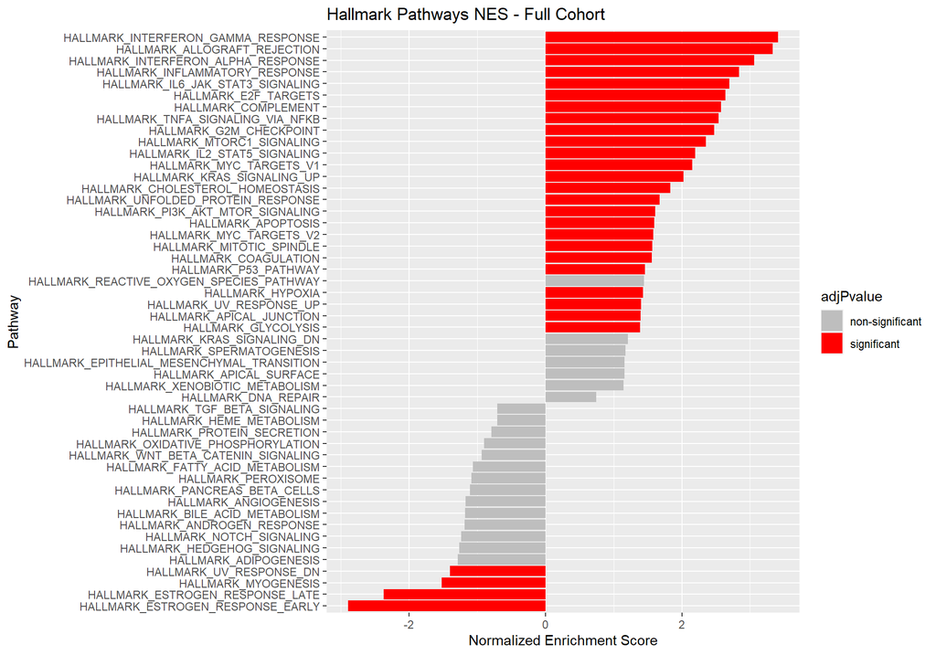

```r
write.table(fgseaResTidy, file.path(output_dir, "pathway_analysis", "full_fgseaRes_HRank.txt"),
            sep = "\t", row.names = FALSE, quote = FALSE)

# Significance colors
fgseaResTidy$adjPvalue <- ifelse(fgseaResTidy$padj <= 0.05, "significant", "non-significant")
cols <- c("non-significant" = "grey", "significant" = "red")

# NES barplot
ggplot(fgseaResTidy, aes(reorder(pathway, NES), NES, fill = adjPvalue)) +
  geom_col() +
  scale_fill_manual(values = cols) +
  coord_flip() +
  labs(x = "Pathway", y = "Normalized Enrichment Score",
       title = "Hallmark Pathways NES - Full Cohort")
```

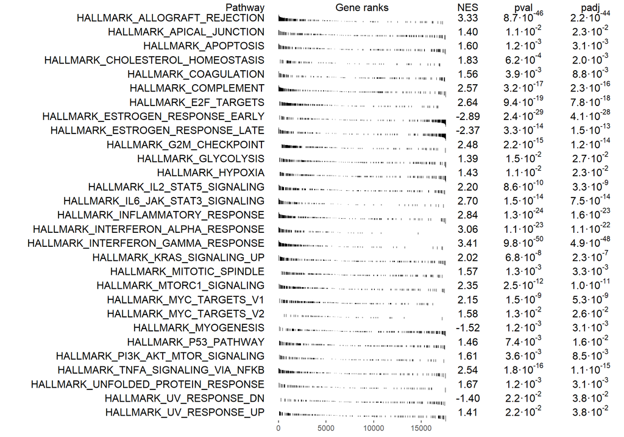

```r
# GSEA table plot
plotGseaTable(pathwaysH[fgseaRes$pathway[fgseaRes$padj < 0.05]], ranks, fgseaRes, gseaParam = 0.5)
```

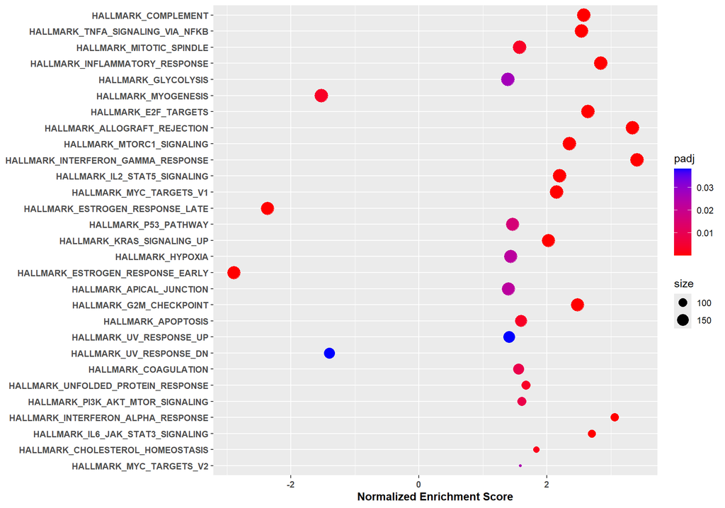

```r
# Dot plot
ggplot(fgseaResTidy[fgseaResTidy$padj < 0.05, ], aes(y = reorder(pathway, size), x = NES)) +
  geom_point(aes(color = padj, size = size)) +
  scale_color_gradientn(colours = c("red", "blue")) +
  labs(x = 'Normalized Enrichment Score', y = NULL) +
  theme(axis.title = element_text(face = 'bold'), axis.text = element_text(face = 'bold'))
```

#### KEGG Pathway Analysis

##### KEGG_MEDICUS

```r
pathwaysKEGG_MED <- gmtPathways(file.path(input_dir, "c2.cp.kegg_medicus.v2023.2.Hs.symbols.gmt"))

fgseaRes_kegg <- fgsea(pathways = pathwaysKEGG_MED, stats = ranks, nproc = 1)
```

[output not shown]

```r
fgseaResTidy_kegg <- fgseaRes_kegg %>%
  as_tibble() %>%
  arrange(desc(NES)) %>%
  mutate(leadingEdge = sapply(leadingEdge, paste, collapse = ";"))

kable(fgseaResTidy_kegg) %>%
  kable_styling(bootstrap_options = c("striped", "hover", "condensed"), full_width = FALSE) %>%
  scroll_box(height = "400px")
```

| pathway | pval | padj | log2err | ES | NES | size | leadingEdge |
| --- | --- | --- | --- | --- | --- | --- | --- |
| KEGG_MEDICUS_REFERENCE_CYTOKINE_JAK_STAT_SIGNALING_PATHWAY | 0.0000001 | 0.0000254 | 0.6901325 | 0.7078958 | 2.3995533 | 44 | IL2RB;STAT1;IFNG;IL12RB2;IL2RG;IL7R;PIM1;IL2RA;IL15;IL15RA;IFNGR1;JAK3;IFNAR2;IL7;IL6;IL6R;JAK2;STAT5A;IL23A;IL3RA;STAT4;IFNGR2;IL4R;STAT2 |
| KEGG_MEDICUS_REFERENCE_ANTIGEN_PROCESSING_AND_PRESENTATION_BY_MHC_CLASS_II_MOLECULES | 0.0000000 | 0.0000005 | 0.8012156 | 0.9360671 | 2.3604646 | 13 | HLA-DRA;HLA-DPA1;HLA-DRB5;HLA-DRB1;HLA-DQA2;HLA-DMA;HLA-DPB1;CD74;HLA-DQB1;HLA-DOB;HLA-DQA1;HLA-DMB;HLA-DOA |
| KEGG_MEDICUS_REFERENCE_DNA_REPLICATION_LICENSING | 0.0000009 | 0.0001362 | 0.6594444 | 0.7746066 | 2.3019161 | 24 | CCNE1;CDC45;CDT1;MCM5;MCM2;MCM6;MCM4;CCNA2;MCM3;ORC6;CCNE2;MCM7;TICRR;CDC7 |
| KEGG_MEDICUS_PATHOGEN_HTLV_1_TAX_TO_NFY_MEDIATED_TRANSCRIPTION | 0.0000000 | 0.0000137 | 0.7195128 | 0.9083475 | 2.2905645 | 13 | HLA-DRA;HLA-DPA1;HLA-DRB5;HLA-DRB1;HLA-DQA2;HLA-DMA;HLA-DPB1;HLA-DQB1;HLA-DOB;HLA-DQA1;HLA-DMB;HLA-DOA |
| KEGG_MEDICUS_REFERENCE_IL2_FAMILY_TO_JAK_STAT_SIGNALING_PATHWAY | 0.0000024 | 0.0002143 | 0.6272567 | 0.7738713 | 2.2648613 | 23 | IL21R;IL2RB;STAT1;IL2RG;IL7R;IL2RA;IL15;IL15RA;JAK3;IL7;STAT5A;IL4R |
| KEGG_MEDICUS_VARIANT_MUTATION_INACTIVATED_VCP_TO_26S_PROTEASOME_MEDIATED_PROTEIN_DEGRADATION | 0.0000031 | 0.0002377 | 0.6272567 | 0.6730571 | 2.2369581 | 39 | PSMD3;PSMB3;PSMB2;VCP;PSMD11;PSMD2;PSMA4;PSMC2;PSMA3;PSMC4;PSMB4;ADRM1;PSMA7;PSMD14;PSMB5;PSMD7;PSMB6;PSMA5;PSMD12;PSMD8;PSMD13;PSMB1;PSMB7;PSMC3;UBA52;PSMC1;PSMC5;PSMA6;PSMA2;RPS27A;PSMD1;PSMD6;UBC |
| KEGG_MEDICUS_VARIANT_MUTATION_CAUSED_ABERRANT_ABETA_TO_26S_PROTEASOME_MEDIATED_PROTEIN_DEGRADATION | 0.0000021 | 0.0002143 | 0.6272567 | 0.6914568 | 2.2297192 | 35 | PSMD3;PSMB3;PSMB2;PSMD11;PSMD2;PSMA4;APP;PSMC2;PSMA3;PSMC4;PSMB4;ADRM1;PSMA7;PSMD14;PSMB5;PSMD7;PSMB6;PSMA5;PSMD12;PSMD8;PSMD13;PSMB1;PSMB7;PSMC3;PSMC1;PSMC5;PSMA6;PSMA2 |
| KEGG_MEDICUS_VARIANT_SCRAPIE_CONFORMATION_PRPSC_TO_26S_PROTEASOME_MEDIATED_PROTEIN_DEGRADATION | 0.0000024 | 0.0002143 | 0.6272567 | 0.6904449 | 2.2264561 | 35 | PSMD3;PSMB3;PSMB2;PSMD11;PSMD2;PSMA4;PSMC2;PSMA3;PSMC4;PSMB4;ADRM1;PSMA7;PSMD14;PSMB5;PSMD7;PSMB6;PSMA5;PSMD12;PSMD8;PSMD13;PSMB1;PSMB7;PRNP;PSMC3;PSMC1;PSMC5;PSMA6;PSMA2 |
| KEGG_MEDICUS_VARIANT_MUTATION_INACTIVATED_UBQLN2_TO_26S_PROTEASOME_MEDIATED_PROTEIN_DEGRADATION | 0.0000055 | 0.0003105 | 0.6105269 | 0.6634401 | 2.2049953 | 39 | PSMD3;PSMB3;PSMB2;PSMD11;PSMD2;PSMA4;PSMC2;PSMA3;PSMC4;PSMB4;ADRM1;PSMA7;PSMD14;PSMB5;PSMD7;PSMB6;PSMA5;PSMD12;PSMD8;PSMD13;PSMB1;PSMB7;PSMC3;UBA52;PSMC1;PSMC5;PSMA6;PSMA2;RPS27A;PSMD1;PSMD6;UBC |
| KEGG_MEDICUS_REFERENCE_26S_PROTEASOME_MEDIATED_PROTEIN_DEGRADATION | 0.0000151 | 0.0006682 | 0.5933255 | 0.6697191 | 2.2047588 | 38 | PSMD3;PSMB3;PSMB2;PSMD11;PSMD2;PSMA4;PSMC2;PSMA3;PSMC4;PSMB4;ADRM1;PSMA7;PSMD14;PSMB5;PSMD7;PSMB6;PSMA5;PSMD12;PSMD8;PSMD13;PSMB1;PSMB7;PSMC3;UBA52;PSMC1;PSMC5;PSMA6;PSMA2;RPS27A;PSMD1;PSMD6;UBC |
| KEGG_MEDICUS_VARIANT_MUTATION_CAUSED_ABERRANT_SOD1_TO_26S_PROTEASOME_MEDIATED_PROTEIN_DEGRADATION | 0.0000388 | 0.0014112 | 0.5573322 | 0.6419621 | 2.1445760 | 40 | PSMD3;PSMB3;PSMB2;PSMD11;PSMD2;PSMA4;PSMC2;PSMA3;PSMC4;PSMB4;ADRM1;PSMA7;PSMD14;PSMB5;PSMD7;PSMB6;DERL1;PSMA5;PSMD12;PSMD8;PSMD13;PSMB1;PSMB7;PSMC3;UBA52;PSMC1;PSMC5;PSMA6;PSMA2;RPS27A;PSMD1;PSMD6;UBC |
| KEGG_MEDICUS_REFERENCE_TCR_PLCG_ITPR_SIGNALING_PATHWAY | 0.0000920 | 0.0025895 | 0.5384341 | 0.7525326 | 2.1306176 | 19 | CD3D;LCK;CD3G;CD247;ZAP70;PLCG2;VAV1;LCP2;LAT;FYN;CD4;ITPR3 |
| KEGG_MEDICUS_REFERENCE_ANTIGEN_PROCESSING_AND_PRESENTATION_BY_MHC_CLASS_I_MOLECULES | 0.0000235 | 0.0009678 | 0.5756103 | 0.8524810 | 2.1227378 | 12 | TAP1;HLA-F;HLA-E;HLA-A;HLA-C;HLA-B;B2M;HLA-G;CALR;TAP2;TAPBP |
| KEGG_MEDICUS_VARIANT_MUTATION_CAUSED_ABERRANT_SNCA_TO_26S_PROTEASOME_MEDIATED_PROTEIN_DEGRADATION | 0.0000316 | 0.0012214 | 0.5573322 | 0.6522022 | 2.1031360 | 35 | PSMD3;PSMB3;PSMB2;PSMD11;PSMD2;PSMA4;PSMC2;PSMA3;PSMC4;PSMB4;ADRM1;PSMA7;PSMD14;PSMB5;PSMD7;PSMB6;PSMA5;PSMD12;PSMD8;PSMD13;PSMB1;PSMB7;PSMC3;PSMC1;PSMC5;PSMA6;PSMA2 |
| KEGG_MEDICUS_REFERENCE_ORIGIN_UNWINDING_AND_ELONGATION | 0.0001283 | 0.0032331 | 0.5188481 | 0.6740776 | 2.0886317 | 30 | CDC45;MCM10;MCM5;MCM2;MCM6;MCM4;RFC4;MCM3;RFC2;MCM7;PCNA;PRIM2;WDHD1;POLA2;RPA2;POLE3;GINS1;POLE2;RFC3;GINS4 |
| KEGG_MEDICUS_PATHOGEN_HCMV_US28_TO_GNA12_13_RHO_SIGNALING_PATHWAY | 0.0000448 | 0.0015412 | 0.5573322 | 0.8282620 | 2.0886143 | 13 | CCL5;CCL4;CCL2;CCL3;CX3CL1 |
| KEGG_MEDICUS_REFERENCE_DNA_REPLICATION_TERMINATION | 0.0001306 | 0.0032331 | 0.5188481 | 0.7526658 | 2.0823000 | 18 | CDC45;MCM5;MCM2;MCM6;MCM4;MCM3;PIF1;MCM7;VCP;GINS1;GINS4;CUL2;LRR1;GINS3;GINS2;RBX1 |
| KEGG_MEDICUS_REFERENCE_TRAIP_DEPENDENT_REPLISOME_DISASSEMBLY | 0.0001022 | 0.0027507 | 0.5384341 | 0.7906926 | 2.0695778 | 15 | CDC45;MCM5;MCM2;MCM6;MCM4;MCM3;MCM7;VCP |
| KEGG_MEDICUS_VARIANT_MUTATION_CAUSED_ABERRANT_HTT_TO_26S_PROTEASOME_MEDIATED_PROTEIN_DEGRADATION | 0.0000708 | 0.0021926 | 0.5384341 | 0.6380350 | 2.0574514 | 35 | PSMD3;PSMB3;PSMB2;PSMD11;PSMD2;PSMA4;PSMC2;PSMA3;PSMC4;PSMB4;ADRM1;PSMA7;PSMD14;PSMB5;PSMD7;PSMB6;PSMA5;PSMD12;PSMD8;PSMD13;PSMB1;PSMB7;PSMC3;PSMC1;PSMC5;PSMA6;PSMA2 |
| KEGG_MEDICUS_PATHOGEN_HTLV_1_P12_TO_ANTIGEN_PROCESSING_AND_PRESENTATION_BY_MHC_CLASS_I_MOLECULES | 0.0000038 | 0.0002588 | 0.6272567 | 0.9486887 | 2.0280993 | 7 | HLA-F;HLA-E;HLA-A;HLA-C;HLA-B;B2M;HLA-G |
| KEGG_MEDICUS_PATHOGEN_HPV_E5_TO_ANTIGEN_PROCESSING_AND_PRESENTATION_BY_MHC_CLASS_I_MOLECULES | 0.0000095 | 0.0004895 | 0.5933255 | 0.9395603 | 2.0085846 | 7 | HLA-F;HLA-E;HLA-A;HLA-C;HLA-B;HLA-G |
| KEGG_MEDICUS_REFERENCE_BREAK_INDUCED_REPLICATION | 0.0000514 | 0.0016747 | 0.5573322 | 0.9040535 | 2.0033270 | 8 | MCM5;MCM2;MCM6;MCM4;MCM3;PIF1;MCM7 |
| KEGG_MEDICUS_PATHOGEN_SARS_COV_2_S_TO_ANGII_AT1R_NOX2_SIGNALING_PATHWAY | 0.0002454 | 0.0058428 | 0.4984931 | 0.7873031 | 1.9853291 | 13 | MMP1;CCL2;MMP3;CYBB;ACE2;IL1B;TNF;IL6 |
| KEGG_MEDICUS_VARIANT_SCRAPIE_CONFORMATION_PRPSC_TO_PRNP_PI3K_NOX2_SIGNALING_PATHWAY | 0.0003852 | 0.0082230 | 0.4984931 | 0.7475041 | 1.9781175 | 16 | CYBB;NCF1;NCF2;CYBA;NCF4;RAC2;FYN |
| KEGG_MEDICUS_REFERENCE_PRE_IC_FORMATION | 0.0004120 | 0.0085006 | 0.4984931 | 0.6490456 | 1.9774282 | 27 | CDC45;CDT1;MCM5;MCM2;MCM6;MCM4;MCM3;ORC6;MCM7;TICRR;ORC3;POLE3;GINS1;ORC1;CDC6;POLE2;GINS4 |
| KEGG_MEDICUS_PATHOGEN_KSHV_MIR1_2_TO_ANTIGEN_PROCESSING_AND_PRESENTATION_BY_MHC_CLASS_I_MOLECULES | 0.0000106 | 0.0005048 | 0.5933255 | 0.9486346 | 1.9629552 | 6 | HLA-F;HLA-E;HLA-A;HLA-C;HLA-B;HLA-G |
| KEGG_MEDICUS_PATHOGEN_ESCHERICHIA_ESPT_TO_RAC_SIGNALING_PATHWAY | 0.0009133 | 0.0176672 | 0.4772708 | 0.7373308 | 1.9154886 | 14 | ARPC1B;ACTR3;ARPC5L;ACTB;ACTR2;ARPC2;ARPC5;ARPC4;ACTG1;ABI1;ARPC1A |
| KEGG_MEDICUS_REFERENCE_CENPE_INTERACTION_WITH_NDC80_COMPLEX | 0.0020952 | 0.0342544 | 0.4317077 | 0.7813302 | 1.9076050 | 11 | NDC80;SPAG5;NUF2;AURKA;CENPE;SPC25;AURKB;PPP1CA |
| KEGG_MEDICUS_REFERENCE_PRNP_PI3K_NOX2_SIGNALING_PATHWAY | 0.0011989 | 0.0224885 | 0.4550599 | 0.6216829 | 1.9004894 | 29 | CYBB;NCF1;NCF2;CYBA;NCF4;RAC2;CREB3L2;FYN;MAPK1;ATF4;CREB3L1 |
| KEGG_MEDICUS_PATHOGEN_HTLV_1_P12_TO_JAK_STAT_SIGNALING_PATHWAY | 0.0003057 | 0.0070091 | 0.4984931 | 0.8887598 | 1.8999838 | 7 | IL2RB;IL2RG;JAK3;STAT5A |

[output cut: 589 more lines]

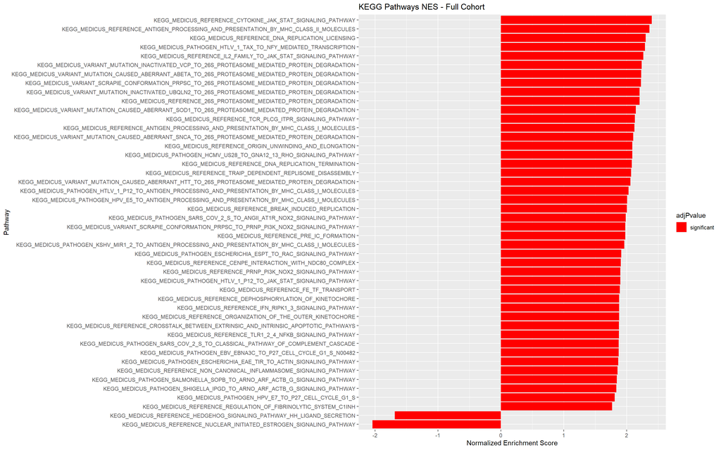

```r
write.table(fgseaResTidy_kegg, file.path(output_dir, "pathway_analysis", "full_fgseaRes_kegRank.txt"),
            sep = "\t", row.names = FALSE, quote = FALSE)

fgseaResTidy_kegg$adjPvalue <- ifelse(fgseaResTidy_kegg$padj <= 0.05, "significant", "non-significant")

ggplot(fgseaResTidy_kegg[fgseaResTidy_kegg$padj < 0.05, ], aes(reorder(pathway, NES), NES, fill = adjPvalue)) +
  geom_col() +
  scale_fill_manual(values = cols) +
  coord_flip() +
  labs(x = "Pathway", y = "Normalized Enrichment Score",
       title = "KEGG Pathways NES - Full Cohort")
```

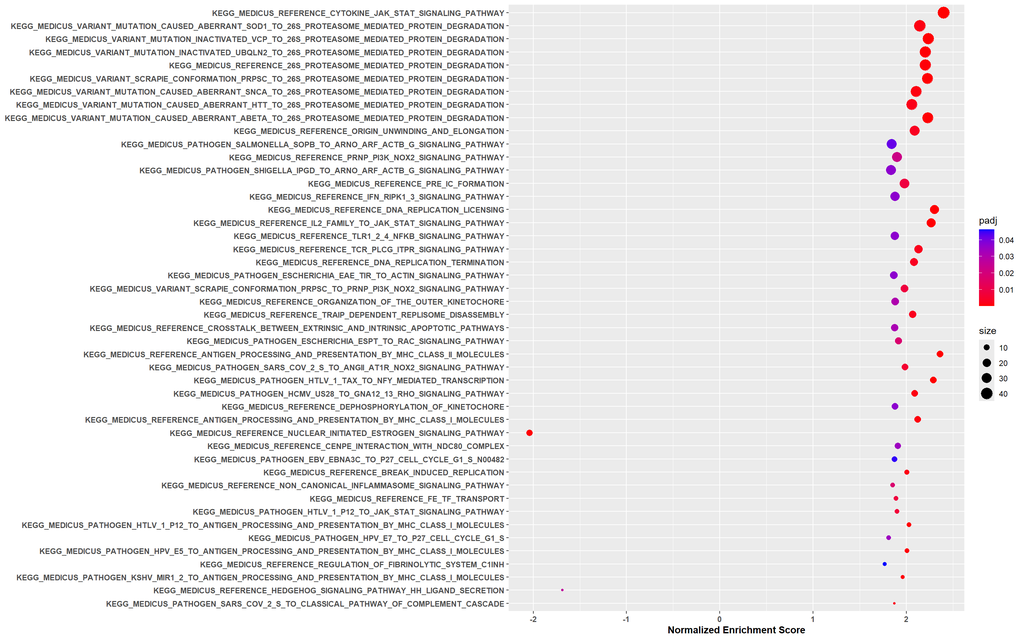

```r
ggplot(fgseaResTidy_kegg[fgseaResTidy_kegg$padj < 0.05, ], aes(y = reorder(pathway, size), x = NES)) +
  geom_point(aes(color = padj, size = size)) +
  scale_color_gradientn(colours = c("red", "blue")) +
  labs(x = 'Normalized Enrichment Score', y = NULL) +
  theme(axis.title = element_text(face = 'bold'), axis.text = element_text(face = 'bold'))
```

#### Over-Representation Analysis (ORA)

Identifies whether certain gene sets are over-represented in a target gene group.

```r
deGenes <- rownames(top_full)[top_full$pval < 0.05]
geneUniverse <- rownames(expr_data)

# ORA for Hallmark pathways
oraHallmark <- fora(pathways = pathwaysH, genes = deGenes, universe = geneUniverse, minSize = 15, maxSize = 500)
oraHallmark$Pathway_Set <- "Hallmark"
oraHallmark$Significance <- ifelse(oraHallmark$pval < 0.05, "Significant", "Not Significant")

# ORA for KEGG_MEDICUS pathways
oraKeggMed <- fora(pathways = pathwaysKEGG_MED, genes = deGenes, universe = geneUniverse, minSize = 15, maxSize = 500)
oraKeggMed$Pathway_Set <- "KEGG_MEDICUS"
oraKeggMed$Significance <- ifelse(oraKeggMed$pval < 0.05, "Significant", "Not Significant")

kable(oraHallmark, caption = "Hallmark Pathway Enrichment Results") %>%
  kable_styling(bootstrap_options = c("striped", "hover", "condensed"), full_width = FALSE) %>%
  scroll_box(height = "400px")
```

Hallmark Pathway Enrichment Results

| pathway | pval | padj | overlap | size | overlapGenes | Pathway_Set | Significance |
| --- | --- | --- | --- | --- | --- | --- | --- |
| HALLMARK_ADIPOGENESIS | 1 | 1 | 0 | 192 |  | Hallmark | Not Significant |
| HALLMARK_ALLOGRAFT_REJECTION | 1 | 1 | 0 | 195 |  | Hallmark | Not Significant |
| HALLMARK_ANDROGEN_RESPONSE | 1 | 1 | 0 | 96 |  | Hallmark | Not Significant |
| HALLMARK_ANGIOGENESIS | 1 | 1 | 0 | 36 |  | Hallmark | Not Significant |
| HALLMARK_APICAL_JUNCTION | 1 | 1 | 0 | 190 |  | Hallmark | Not Significant |
| HALLMARK_APICAL_SURFACE | 1 | 1 | 0 | 43 |  | Hallmark | Not Significant |
| HALLMARK_APOPTOSIS | 1 | 1 | 0 | 159 |  | Hallmark | Not Significant |
| HALLMARK_BILE_ACID_METABOLISM | 1 | 1 | 0 | 112 |  | Hallmark | Not Significant |
| HALLMARK_CHOLESTEROL_HOMEOSTASIS | 1 | 1 | 0 | 72 |  | Hallmark | Not Significant |
| HALLMARK_COAGULATION | 1 | 1 | 0 | 137 |  | Hallmark | Not Significant |
| HALLMARK_COMPLEMENT | 1 | 1 | 0 | 198 |  | Hallmark | Not Significant |
| HALLMARK_DNA_REPAIR | 1 | 1 | 0 | 145 |  | Hallmark | Not Significant |
| HALLMARK_E2F_TARGETS | 1 | 1 | 0 | 195 |  | Hallmark | Not Significant |
| HALLMARK_EPITHELIAL_MESENCHYMAL_TRANSITION | 1 | 1 | 0 | 195 |  | Hallmark | Not Significant |
| HALLMARK_ESTROGEN_RESPONSE_EARLY | 1 | 1 | 0 | 190 |  | Hallmark | Not Significant |
| HALLMARK_ESTROGEN_RESPONSE_LATE | 1 | 1 | 0 | 192 |  | Hallmark | Not Significant |
| HALLMARK_FATTY_ACID_METABOLISM | 1 | 1 | 0 | 152 |  | Hallmark | Not Significant |
| HALLMARK_G2M_CHECKPOINT | 1 | 1 | 0 | 188 |  | Hallmark | Not Significant |
| HALLMARK_GLYCOLYSIS | 1 | 1 | 0 | 197 |  | Hallmark | Not Significant |
| HALLMARK_HEDGEHOG_SIGNALING | 1 | 1 | 0 | 35 |  | Hallmark | Not Significant |
| HALLMARK_HEME_METABOLISM | 1 | 1 | 0 | 189 |  | Hallmark | Not Significant |
| HALLMARK_HYPOXIA | 1 | 1 | 0 | 191 |  | Hallmark | Not Significant |
| HALLMARK_IL2_STAT5_SIGNALING | 1 | 1 | 0 | 194 |  | Hallmark | Not Significant |
| HALLMARK_IL6_JAK_STAT3_SIGNALING | 1 | 1 | 0 | 87 |  | Hallmark | Not Significant |
| HALLMARK_INFLAMMATORY_RESPONSE | 1 | 1 | 0 | 197 |  | Hallmark | Not Significant |
| HALLMARK_INTERFERON_ALPHA_RESPONSE | 1 | 1 | 0 | 94 |  | Hallmark | Not Significant |
| HALLMARK_INTERFERON_GAMMA_RESPONSE | 1 | 1 | 0 | 194 |  | Hallmark | Not Significant |
| HALLMARK_KRAS_SIGNALING_DN | 1 | 1 | 0 | 191 |  | Hallmark | Not Significant |
| HALLMARK_KRAS_SIGNALING_UP | 1 | 1 | 0 | 191 |  | Hallmark | Not Significant |
| HALLMARK_MITOTIC_SPINDLE | 1 | 1 | 0 | 197 |  | Hallmark | Not Significant |
| HALLMARK_MTORC1_SIGNALING | 1 | 1 | 0 | 194 |  | Hallmark | Not Significant |
| HALLMARK_MYC_TARGETS_V1 | 1 | 1 | 0 | 193 |  | Hallmark | Not Significant |
| HALLMARK_MYC_TARGETS_V2 | 1 | 1 | 0 | 57 |  | Hallmark | Not Significant |
| HALLMARK_MYOGENESIS | 1 | 1 | 0 | 196 |  | Hallmark | Not Significant |
| HALLMARK_NOTCH_SIGNALING | 1 | 1 | 0 | 32 |  | Hallmark | Not Significant |
| HALLMARK_OXIDATIVE_PHOSPHORYLATION | 1 | 1 | 0 | 184 |  | Hallmark | Not Significant |
| HALLMARK_P53_PATHWAY | 1 | 1 | 0 | 191 |  | Hallmark | Not Significant |
| HALLMARK_PANCREAS_BETA_CELLS | 1 | 1 | 0 | 40 |  | Hallmark | Not Significant |
| HALLMARK_PEROXISOME | 1 | 1 | 0 | 104 |  | Hallmark | Not Significant |
| HALLMARK_PI3K_AKT_MTOR_SIGNALING | 1 | 1 | 0 | 104 |  | Hallmark | Not Significant |
| HALLMARK_PROTEIN_SECRETION | 1 | 1 | 0 | 94 |  | Hallmark | Not Significant |
| HALLMARK_REACTIVE_OXYGEN_SPECIES_PATHWAY | 1 | 1 | 0 | 47 |  | Hallmark | Not Significant |
| HALLMARK_SPERMATOGENESIS | 1 | 1 | 0 | 132 |  | Hallmark | Not Significant |
| HALLMARK_TGF_BETA_SIGNALING | 1 | 1 | 0 | 54 |  | Hallmark | Not Significant |
| HALLMARK_TNFA_SIGNALING_VIA_NFKB | 1 | 1 | 0 | 197 |  | Hallmark | Not Significant |
| HALLMARK_UNFOLDED_PROTEIN_RESPONSE | 1 | 1 | 0 | 106 |  | Hallmark | Not Significant |
| HALLMARK_UV_RESPONSE_DN | 1 | 1 | 0 | 138 |  | Hallmark | Not Significant |
| HALLMARK_UV_RESPONSE_UP | 1 | 1 | 0 | 154 |  | Hallmark | Not Significant |
| HALLMARK_WNT_BETA_CATENIN_SIGNALING | 1 | 1 | 0 | 42 |  | Hallmark | Not Significant |
| HALLMARK_XENOBIOTIC_METABOLISM | 1 | 1 | 0 | 194 |  | Hallmark | Not Significant |

```r
kable(oraKeggMed, caption = "KEGG Medicus Pathway Enrichment Results") %>%
  kable_styling(bootstrap_options = c("striped", "hover", "condensed"), full_width = FALSE) %>%
  scroll_box(height = "400px")
```

KEGG Medicus Pathway Enrichment Results

| pathway | pval | padj | overlap | size | overlapGenes | Pathway_Set | Significance |
| --- | --- | --- | --- | --- | --- | --- | --- |
| KEGG_MEDICUS_ENV_FACTOR_ARSENIC_TO_ELECTRON_TRANSFER_IN_COMPLEX_IV | 1 | 1 | 0 | 17 |  | KEGG_MEDICUS | Not Significant |
| KEGG_MEDICUS_ENV_FACTOR_DCE_TO_DNA_ADDUCTS | 1 | 1 | 0 | 18 |  | KEGG_MEDICUS | Not Significant |
| KEGG_MEDICUS_ENV_FACTOR_E2_TO_RAS_ERK_SIGNALING_PATHWAY | 1 | 1 | 0 | 16 |  | KEGG_MEDICUS | Not Significant |
| KEGG_MEDICUS_ENV_FACTOR_IRON_TO_ANTEROGRADE_AXONAL_TRANSPORT | 1 | 1 | 0 | 18 |  | KEGG_MEDICUS | Not Significant |
| KEGG_MEDICUS_ENV_FACTOR_METALS_TO_NFKB_SIGNALING_PATHWAY | 1 | 1 | 0 | 15 |  | KEGG_MEDICUS | Not Significant |
| KEGG_MEDICUS_ENV_FACTOR_NNK_NNN_TO_RAS_ERK_SIGNALING_PATHWAY | 1 | 1 | 0 | 18 |  | KEGG_MEDICUS | Not Significant |
| KEGG_MEDICUS_ENV_FACTOR_TCDD_TO_AHR_SIGNALING_PATHWAY | 1 | 1 | 0 | 22 |  | KEGG_MEDICUS | Not Significant |
| KEGG_MEDICUS_ENV_FACTOR_ZN_TO_ANTEROGRADE_AXONAL_TRANSPORT | 1 | 1 | 0 | 18 |  | KEGG_MEDICUS | Not Significant |
| KEGG_MEDICUS_PATHOGEN_ESCHERICHIA_EAE_TIR_TO_ACTIN_SIGNALING_PATHWAY | 1 | 1 | 0 | 17 |  | KEGG_MEDICUS | Not Significant |
| KEGG_MEDICUS_PATHOGEN_ESCHERICHIA_ESPG_TO_MICROTUBULE_RHOA_SIGNALING_PATHWAY | 1 | 1 | 0 | 16 |  | KEGG_MEDICUS | Not Significant |
| KEGG_MEDICUS_PATHOGEN_HBV_HBX_TO_RAS_ERK_SIGNALING_PATHWAY | 1 | 1 | 0 | 15 |  | KEGG_MEDICUS | Not Significant |
| KEGG_MEDICUS_PATHOGEN_HCMV_GB_TO_PDGFR_RAS_ERK_SIGNALING_PATHWAY | 1 | 1 | 0 | 15 |  | KEGG_MEDICUS | Not Significant |
| KEGG_MEDICUS_PATHOGEN_HCMV_UL33_TO_GNAI_AC_PKA_SIGNALING_PATHWAY | 1 | 1 | 0 | 26 |  | KEGG_MEDICUS | Not Significant |
| KEGG_MEDICUS_PATHOGEN_HCMV_UL33_TO_GNAS_AC_PKA_SIGNALING_PATHWAY | 1 | 1 | 0 | 23 |  | KEGG_MEDICUS | Not Significant |
| KEGG_MEDICUS_PATHOGEN_HCMV_UL33_TO_GNB_G_RHO_SIGNALING_PATHWAY | 1 | 1 | 0 | 33 |  | KEGG_MEDICUS | Not Significant |
| KEGG_MEDICUS_PATHOGEN_HCMV_US28_TO_GNAI_AC_PKA_SIGNALING_PATHWAY | 1 | 1 | 0 | 16 |  | KEGG_MEDICUS | Not Significant |
| KEGG_MEDICUS_PATHOGEN_HCMV_US28_TO_GNAQ_PLCB_G_CALCINEURIN_SIGNALING_PATHWAY | 1 | 1 | 0 | 18 |  | KEGG_MEDICUS | Not Significant |
| KEGG_MEDICUS_PATHOGEN_HCMV_US28_TO_GNB_G_PI3K_NFKB_SIGNALING_PATHWAY | 1 | 1 | 0 | 30 |  | KEGG_MEDICUS | Not Significant |
| KEGG_MEDICUS_PATHOGEN_HIV_GP120_TO_CXCR4_GNAQ_PLCB_G_CALCINEURIN | 1 | 1 | 0 | 17 |  | KEGG_MEDICUS | Not Significant |
| KEGG_MEDICUS_PATHOGEN_HIV_GP120_TO_CXCR4_GNB_G_RAC_SIGNALING_PATHWAY | 1 | 1 | 0 | 26 |  | KEGG_MEDICUS | Not Significant |
| KEGG_MEDICUS_PATHOGEN_HIV_GP120_TO_TNF_NFKB_SIGNALING_PATHWAY | 1 | 1 | 0 | 15 |  | KEGG_MEDICUS | Not Significant |
| KEGG_MEDICUS_PATHOGEN_HPV_E5_TO_EGFR_RAS_ERK_SIGNALING_PATHWAY | 1 | 1 | 0 | 15 |  | KEGG_MEDICUS | Not Significant |
| KEGG_MEDICUS_PATHOGEN_HPV_E7_TO_PP2A_AKT_SIGNALING_PATYWAY | 1 | 1 | 0 | 16 |  | KEGG_MEDICUS | Not Significant |
| KEGG_MEDICUS_PATHOGEN_HTLV_1_TAX_TO_SPINDLE_ASSEMBLY_CHECKPOINT_SIGNALING | 1 | 1 | 0 | 16 |  | KEGG_MEDICUS | Not Significant |
| KEGG_MEDICUS_PATHOGEN_KSHV_VGPCR_TO_GNB_G_ERK_SIGNALING_PATHWAY | 1 | 1 | 0 | 31 |  | KEGG_MEDICUS | Not Significant |
| KEGG_MEDICUS_PATHOGEN_KSHV_VGPCR_TO_GNB_G_PI3K_AKT_SIGNALING_PATHWAY | 1 | 1 | 0 | 24 |  | KEGG_MEDICUS | Not Significant |
| KEGG_MEDICUS_PATHOGEN_KSHV_VGPCR_TO_GNB_G_PI3K_JNK_SIGNALING_PATHWAY | 1 | 1 | 0 | 28 |  | KEGG_MEDICUS | Not Significant |
| KEGG_MEDICUS_PATHOGEN_SALMONELLA_SIFA_TO_MICROTUBULE_PLUS_END_DIRECTED_TRANSPORT | 1 | 1 | 0 | 24 |  | KEGG_MEDICUS | Not Significant |
| KEGG_MEDICUS_PATHOGEN_SALMONELLA_SOPB_TO_ARNO_ARF_ACTB_G_SIGNALING_PATHWAY | 1 | 1 | 0 | 30 |  | KEGG_MEDICUS | Not Significant |
| KEGG_MEDICUS_PATHOGEN_SALMONELLA_SOPE_TO_RAC_SIGNALING_PATHWAY | 1 | 1 | 0 | 20 |  | KEGG_MEDICUS | Not Significant |

[output cut: 213 more lines]

```r
write.table(transform(oraHallmark, overlapGenes = sapply(overlapGenes, paste, collapse = ",")),
            file = file.path(output_dir, "pathway_analysis", "Hallmark_ORA_Results.csv"),
            sep = "\t", row.names = FALSE, quote = FALSE)

write.table(transform(oraKeggMed, overlapGenes = sapply(overlapGenes, paste, collapse = ",")),
            file = file.path(output_dir, "pathway_analysis", "KeggMed_ORA_Results.csv"),
            sep = "\t", row.names = FALSE, quote = FALSE)
```

### 6. DE by Treatment (R vs NR)

Treatment groups: `"chemo"`, `"chemo+targeted"`, `"IO+chemo"`, `"targeted"`

```r
DT::datatable(as.data.frame(table(merged_clin$treatment)), colnames = c("Treatment", "Count"))
```

|  | Treatment | Count |
| --- | --- | --- |
| 1 | chemo | 177 |
| 2 | chemo+targeted | 684 |
| 3 | IO+chemo | 69 |
| 4 | targeted | 52 |

```r
DT::datatable(as.data.frame(table(merged_clin$treatmentid)), colnames = c("Treatment ID", "Count"))
```

|  | Treatment ID | Count |
| --- | --- | --- |
| 1 | Paclitaxel | 177 |
| 2 | Paclitaxel + Ganetespib | 93 |
| 3 | Paclitaxel + Ganitumab | 106 |
| 4 | Paclitaxel + MK-2206 | 60 |
| 5 | Paclitaxel + MK-2206 + Trastuzumab | 34 |
| 6 | Paclitaxel + Neratinib | 113 |
| 7 | Paclitaxel + Pembrolizumab | 69 |
| 8 | Paclitaxel + Pertuzumab + Trastuzumab | 44 |
| 9 | Paclitaxel + Trastuzumab | 31 |
| 10 | Paclitaxel + Trebananib | 115 |

[output cut: 3 more lines]

```r
treatment_list <- c("chemo", "chemo+targeted", "IO+chemo", "targeted")
sig_gene_list <- list()
top_table_list <- list()

# Define thresholds once — change here to update everywhere
fc_cutoff <- 1.5
p_cutoff <- 0.05
top_n_labels <- Inf

for (treatment in treatment_list) {
  cat("\nProcessing:", treatment, "\n")

  # Subset data
  clin_sub <- clin_data[clin_data$treatment == treatment, ]
  matched_ids <- clin_sub$patientid[clin_sub$patientid %in% colnames(expr_data)]
  expr_sub <- expr_data[, matched_ids]

  # Design and fit
  design <- model.matrix(~ clin_sub$response)
  fit <- lmFit(expr_sub, design)
  fit <- eBayes(fit)
  top.table <- topTable(fit, sort.by = "P", n = Inf)

  cat("DE genes (adj.P.Val <", p_cutoff, "):", sum(top.table$adj.P.Val < p_cutoff), "\n")

  top.table.clean <- top.table[, sapply(top.table, is.numeric)]
  rownames(top.table.clean) <- rownames(top.table)

  # Labels: top N red dots only
  red_genes_pval <- top.table.clean[
    top.table.clean$P.Value < p_cutoff & abs(top.table.clean$logFC) >= fc_cutoff,
  ]
  red_genes_pval <- head(red_genes_pval[order(red_genes_pval$P.Value), ], top_n_labels)
  selectLab_pval <- rownames(red_genes_pval)

  red_genes_fdr <- top.table.clean[
    top.table.clean$adj.P.Val < p_cutoff & abs(top.table.clean$logFC) >= fc_cutoff,
  ]
  red_genes_fdr <- head(red_genes_fdr[order(red_genes_fdr$adj.P.Val), ], top_n_labels)
  selectLab_fdr <- rownames(red_genes_fdr)

  # Counts for subtitle
  n_pval <- sum(top.table.clean$P.Value < p_cutoff & abs(top.table.clean$logFC) >= fc_cutoff)
  n_fdr <- sum(top.table.clean$adj.P.Val < p_cutoff & abs(top.table.clean$logFC) >= fc_cutoff)

  # Volcano plot: P-value
  print(EnhancedVolcano(top.table.clean,
    lab = rownames(top.table.clean),
    selectLab = selectLab_pval,
    x = 'logFC', y = 'P.Value',
    pCutoff = p_cutoff, FCcutoff = fc_cutoff,
    xlim = c(-5, 5), ylim = c(0, 8),
    labSize = 3.5,
    labCol = "black",
    drawConnectors = TRUE,
    widthConnectors = 0.5,
    colConnectors = "grey50",
    maxoverlapsConnectors = Inf,
    title = paste("Volcano Plot (P value) -", treatment),
    subtitle = paste0("p < ", p_cutoff, " & |logFC| >= ", fc_cutoff, ": ", n_pval, " genes (top ", top_n_labels, " labeled)"),
    caption = paste0("Total genes: ", nrow(top.table.clean))
  ))

  # Volcano plot: FDR
  print(EnhancedVolcano(top.table.clean,
    lab = rownames(top.table.clean),
    selectLab = selectLab_fdr,
    x = 'logFC', y = 'adj.P.Val',
    pCutoff = p_cutoff, FCcutoff = fc_cutoff,
    xlim = c(-5, 5), ylim = c(0, 8),
    labSize = 3.5,
    labCol = "black",
    drawConnectors = TRUE,
    widthConnectors = 0.5,
    colConnectors = "grey50",
    maxoverlapsConnectors = Inf,
    legendLabels = c('Not sig.', 'Log FC', 'adj p-value', 'adj p-value & Log FC'),
    title = paste("Volcano Plot (FDR) -", treatment),
    subtitle = paste0("FDR < ", p_cutoff, " & |logFC| >= ", fc_cutoff, ": ", n_fdr, " genes (top ", top_n_labels, " labeled)"),
    caption = paste0("Total genes: ", nrow(top.table.clean))
  ))

  # Save and display
  top.table$Gene <- rownames(top.table)
  file_name <- paste0(gsub("\\+", "_", treatment), "_limma_fit.txt")
  write.table(top.table, file = file.path(output_dir, "DEG_analysis", file_name),
              row.names = FALSE, sep = "\t", quote = FALSE)

  top.display <- top.table
  top.display[, sapply(top.display, is.numeric)] <- round(top.display[, sapply(top.display, is.numeric)], 3)
  print(DT::datatable(top.display, caption = paste("TopTable -", treatment)))

  # Report
  sig_genes <- rownames(top.table)[top.table$adj.P.Val < p_cutoff & abs(top.table$logFC) >= fc_cutoff]
  cat("DE genes (FDR <", p_cutoff, "& |logFC| >=", fc_cutoff, "):", length(sig_genes), "\n")
  cat("Significant gene names:\n")
  print(sig_genes)

  top_table_list[[treatment]] <- top.table
  sig_gene_list[[treatment]] <- sig_genes

  gene_file <- paste0(gsub("\\+", "_", treatment), "_significant_genes.txt")
  writeLines(sig_genes, file.path(output_dir, "DEG_analysis", gene_file))
}
```

Processing: chemo DE genes (adj.P.Val < 0.05 ): 0

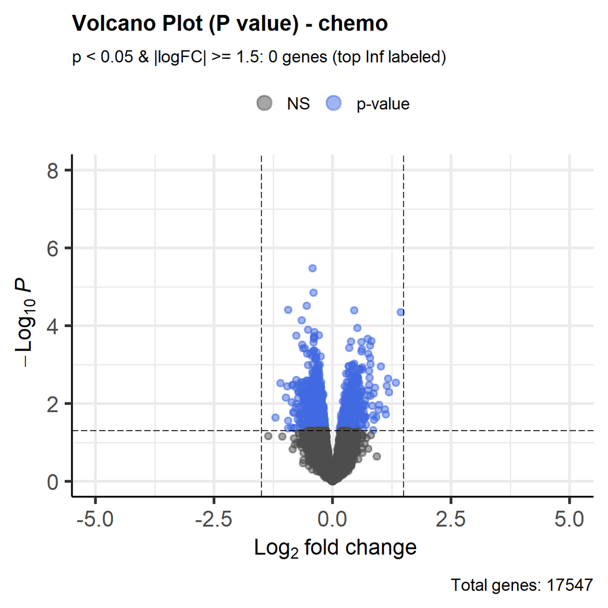

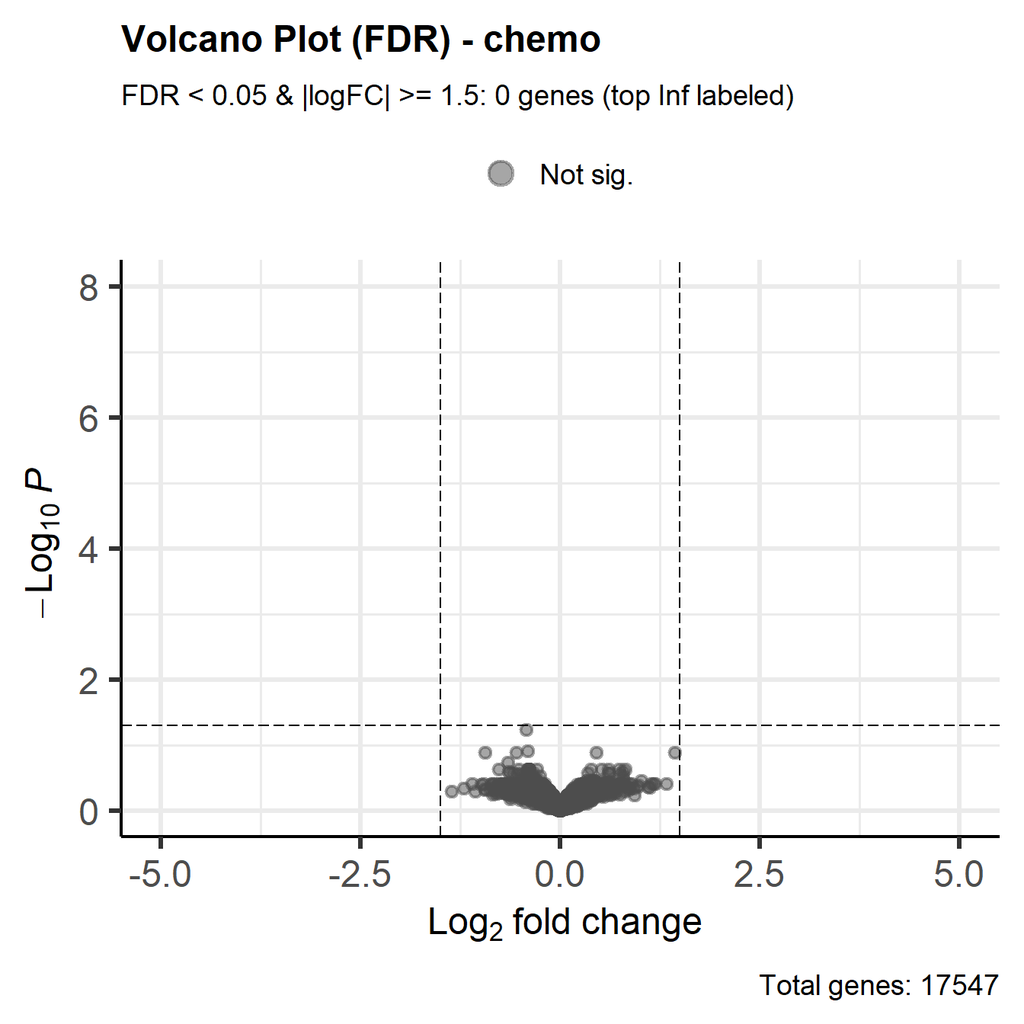

DE genes (FDR < 0.05 & |logFC| >= 1.5 ): 0 Significant gene names: character(0)

Processing: chemo+targeted DE genes (adj.P.Val < 0.05 ): 4152

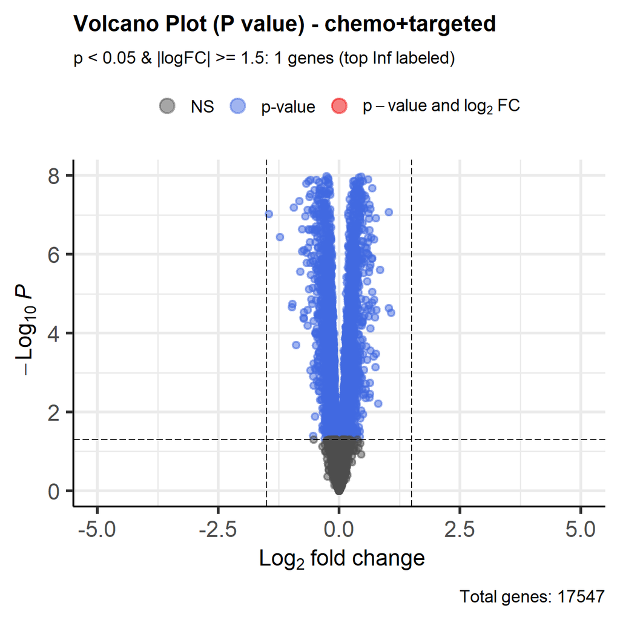

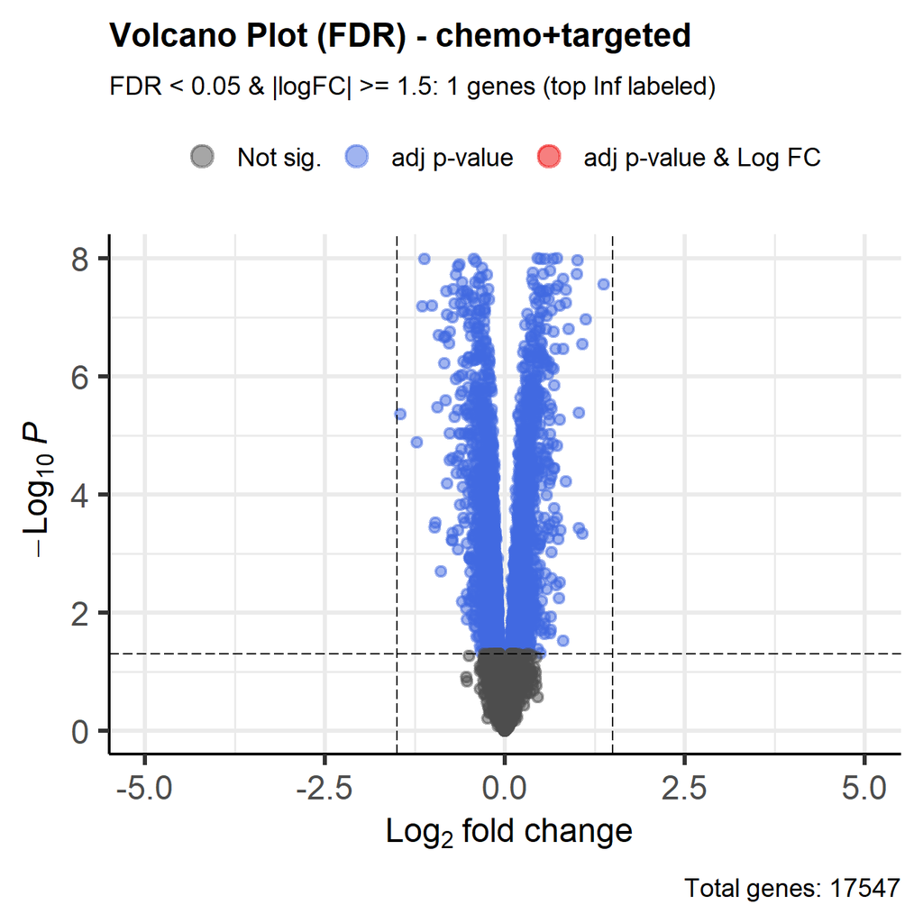

DE genes (FDR < 0.05 & |logFC| >= 1.5 ): 1 Significant gene names: [1] “AGR3”

Processing: IO+chemo DE genes (adj.P.Val < 0.05 ): 521

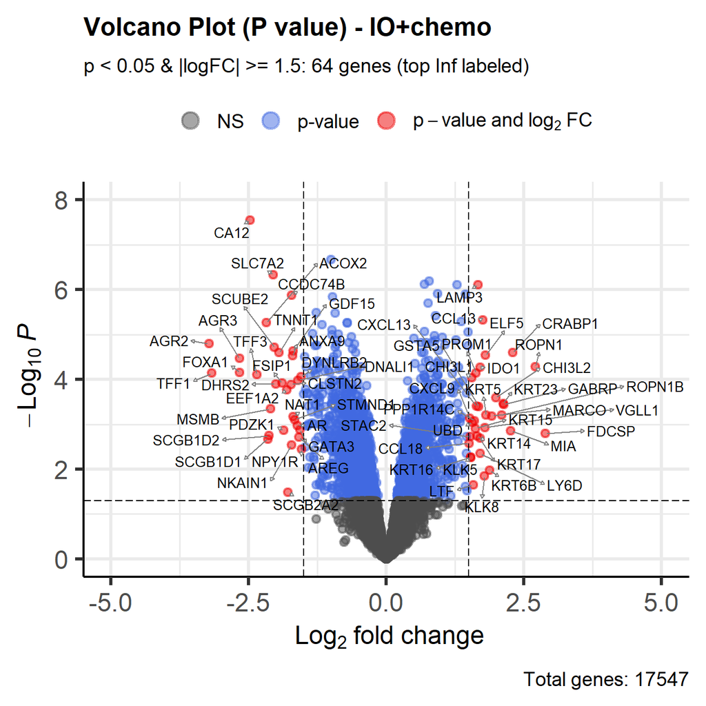

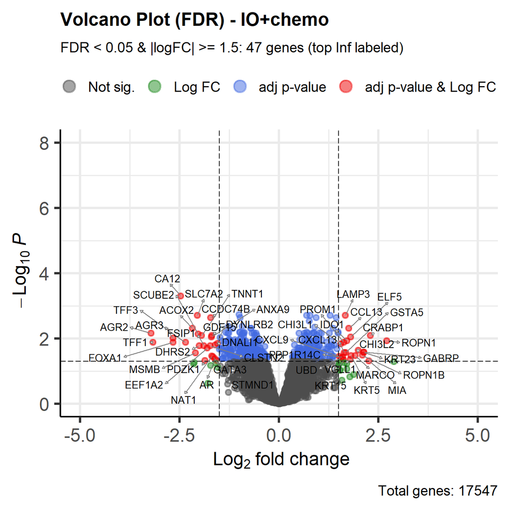

DE genes (FDR < 0.05 & |logFC| >= 1.5 ): 47 Significant gene names: [1] “CA12” “SLC7A2” “LAMP3” “CCDC74B” “CCL13” “ACOX2”  
[7] “AGR2” “SCUBE2” “GDF15” “CRABP1” “TNNT1” “ELF5”  
[13] “ANXA9” “AGR3” “ROPN1” “IDO1” “FOXA1” “PROM1”  
[19] “TFF1” “TFF3” “DYNLRB2” “CHI3L1” “DNALI1” “FSIP1”  
[25] “DHRS2” “CLSTN2” “EEF1A2” “CHI3L2” “KRT23” “GABRP”  
[31] “CXCL13” “GSTA5” “MSMB” “ROPN1B” “KRT5” “MARCO”  
[37] “NAT1” “CXCL9” “STMND1” “PPP1R14C” “UBD” “AR”  
[43] “VGLL1” “KRT15” “GATA3” “PDZK1” “MIA”

Processing: targeted DE genes (adj.P.Val < 0.05 ): 5

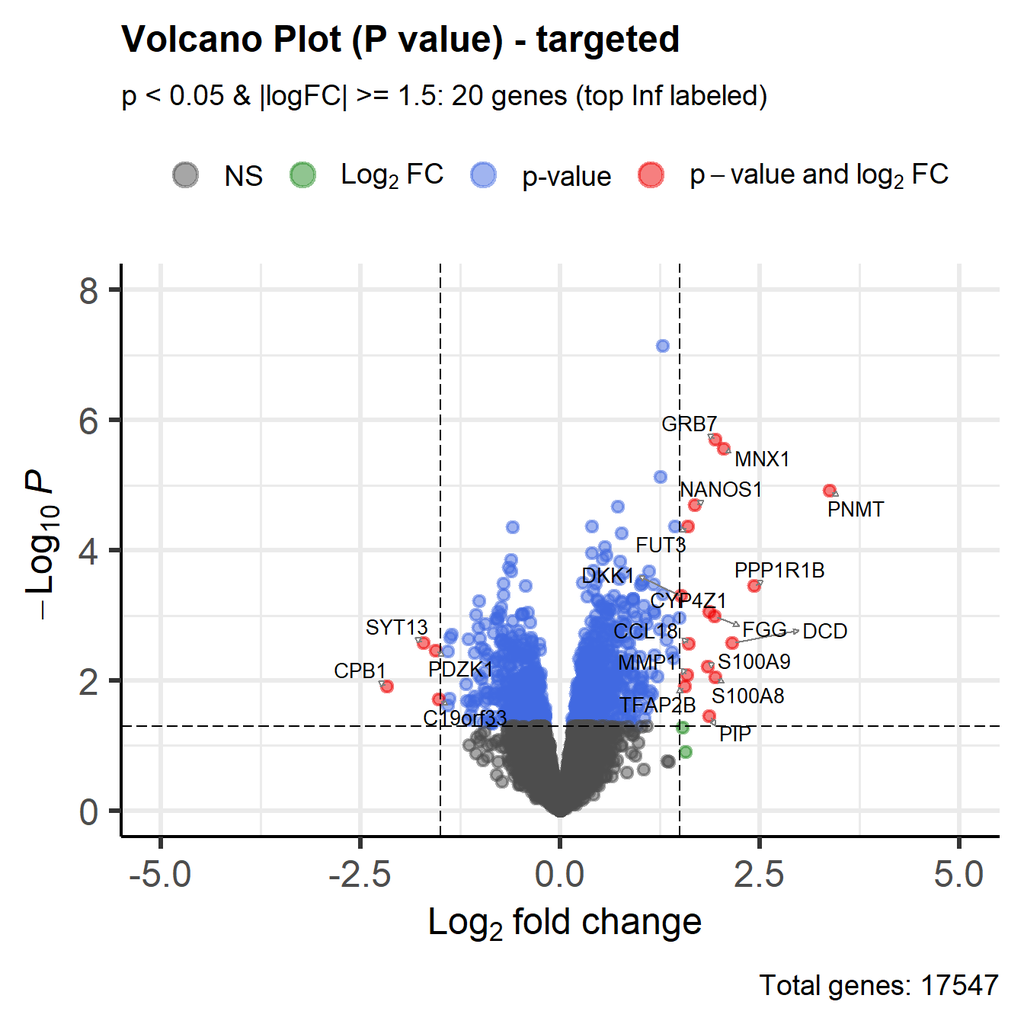

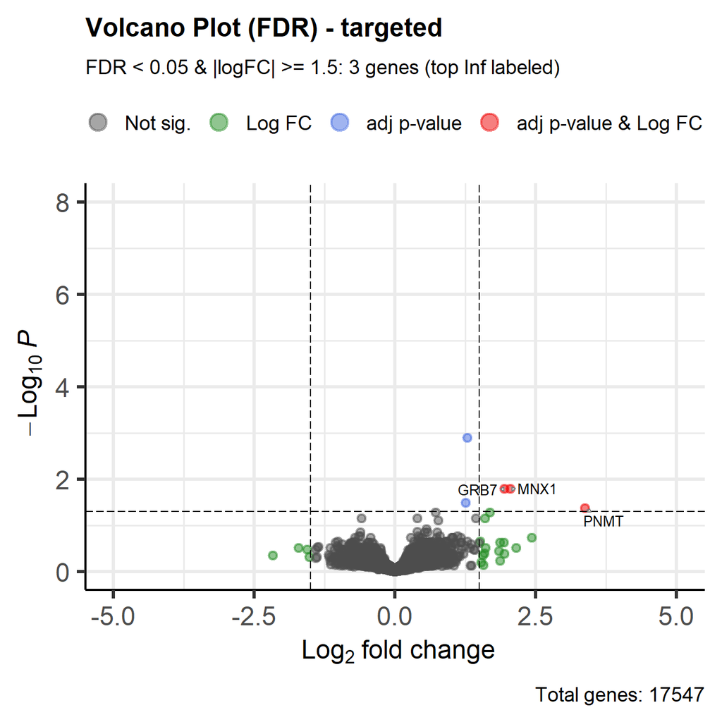

DE genes (FDR < 0.05 & |logFC| >= 1.5 ): 3 Significant gene names: [1] “GRB7” “MNX1” “PNMT”

**Summary of Differentially Expressed Genes by Treatment**:

**IO+Chemo Key Findings (47 DE genes):**

- **Upregulated in responders (immune-hot):** LAMP3, CCL13, IDO1, CXCL13, CXCL9, MARCO, UBD, CHI3L2, CRABP1, KRT5 → Immune activation: dendritic cells, T-cell chemokines, interferon-induced genes
- **Upregulated in non-responders (hormone-driven):** CA12, AGR2, FOXA1, AR, ACOX2, GATA3, TFF1, TFF3, SCUBE2, MSMB → Estrogen receptor pathway: luminal markers, hormone-regulated genes
- **Key takeaway:** Immune-hot tumors respond to pembrolizumab + chemo; cold, hormone-driven tumors do not.

```r
# Summary table with both thresholds
summary_rows <- list()
for (treatment in treatment_list) {
  tt <- top_table_list[[treatment]]

  genes_fc1.0 <- rownames(tt)[tt$adj.P.Val < p_cutoff & abs(tt$logFC) >= 1.0]
  genes_fc1.5 <- rownames(tt)[tt$adj.P.Val < p_cutoff & abs(tt$logFC) >= fc_cutoff]

  summary_rows[[treatment]] <- data.frame(
    Treatment = treatment,
    FDR_sig = sum(tt$adj.P.Val < p_cutoff),
    FDR_FC1.0 = length(genes_fc1.0),
    FDR_FC1.5 = length(genes_fc1.5),
    Top_Genes_FC1.0 = ifelse(length(genes_fc1.0) == 0, "–", paste(genes_fc1.0, collapse = ", ")),
    Top_Genes_FC1.5 = ifelse(length(genes_fc1.5) == 0, "–", paste(genes_fc1.5, collapse = ", "))
  )
}

summary_df <- do.call(rbind, summary_rows)
rownames(summary_df) <- NULL
colnames(summary_df) <- c("Treatment", "FDR < 0.05",
                           "FDR & abs(logFC) >= 1.0",
                           "FDR & abs(logFC) >= 1.5",
                           "Genes (logFC >= 1.0)",
                           "Genes (logFC >= 1.5)")

kable(summary_df, row.names = FALSE,
      caption = "Summary of DE Genes by Treatment") %>%
  kable_styling(bootstrap_options = c("striped", "hover", "condensed"), full_width = FALSE) %>%
  scroll_box(height = "400px")
```

Summary of DE Genes by Treatment

| Treatment | FDR < 0.05 | FDR & abs(logFC) >= 1.0 | FDR & abs(logFC) >= 1.5 | Genes (logFC >= 1.0) | Genes (logFC >= 1.5) |
| --- | --- | --- | --- | --- | --- |
| chemo | 0 | 0 | 0 | – | – |
| chemo+targeted | 4152 | 21 | 1 | RERG, SOX11, SCUBE2, AGR3, NAT1, CCL18, CXCL9, CA12, GFRA1, CXCL13, IDO1, S100A8, GATA3, NKAIN1, S100A9, UBD, MMP1, TFF1, AGR2, S100A7, CALML5 | AGR3 |
| IO+chemo | 521 | 143 | 47 | CA12, GPRC5C, SLC7A2, LAMP3, LMO4, CHODL, CCDC74B, THSD4, CCL13, KRT86, ACOX2, LRRC56, GBP5, RGS22, GBP1, PM20D2, AGR2, IL21R, LRFN2, GZMB, PRR15, SCUBE2, GDF15, CRABP1, TNNT1, ELF5, ANXA9, MLPH, AGR3… | CA12, SLC7A2, LAMP3, CCDC74B, CCL13, ACOX2, AGR2, SCUBE2, GDF15, CRABP1, TNNT1, ELF5, ANXA9, AGR3, ROPN1, IDO1, FOXA1, PROM1, TFF1, TFF3, DYNLRB2, CHI3L1, DNALI1, FSIP1, DHRS2, CLSTN2, EEF1A2, CHI3L2,… |
| targeted | 5 | 5 | 3 | ERBB2, GRB7, MNX1, STARD3, PNMT | GRB7, MNX1, PNMT |

```r
write.csv(summary_df,
          file = file.path(output_dir, "DEG_analysis", "DE_summary_by_treatment.csv"),
          row.names = FALSE)
```

### 7. Enrichment by Treatment

```r
sub_treat <- c("IO+chemo", "targeted", "chemo+targeted")
```

#### MSigDB Hallmark Gene Sets

```r
fgsea_result_list <- list()
fgsea_plot_list <- list()
fgsea_dotplot_list <- list()

for (treatment in sub_treat) {
  message("Running GSEA for: ", treatment)

  top_treat <- top_table_list[[treatment]]
  ranks <- top_treat$logFC
  names(ranks) <- top_treat$Gene
  ranks <- sort(ranks, decreasing = TRUE)

  fgseaRes <- fgsea(pathways = pathwaysH, stats = ranks, nproc = 1)
  fgseaRes <- na.omit(fgseaRes)

  fgseaResTidy <- fgseaRes %>%
    as_tibble() %>%
    arrange(desc(NES)) %>%
    mutate(
      leadingEdge = sapply(leadingEdge, paste, collapse = ";"),
      adjPvalue = ifelse(padj <= 0.05, "significant", "non-significant")
    )

  fgsea_result_list[[treatment]] <- fgseaResTidy

  # Barplot (all pathways)
  p_bar <- ggplot(fgseaResTidy, aes(reorder(pathway, NES), NES, fill = adjPvalue)) +
    geom_col() +
    scale_fill_manual(values = c("significant" = "red", "non-significant" = "grey")) +
    coord_flip() +
    theme_minimal() +
    labs(title = paste("Hallmark NES -", treatment), x = "Pathway", y = "Normalized Enrichment Score")

  fgsea_plot_list[[treatment]] <- p_bar
  print(p_bar)

  # Dot plot (significant only)
  sig_fgsea <- fgseaResTidy %>% filter(padj < p_cutoff)

  if (nrow(sig_fgsea) > 0) {
    p_dot <- ggplot(sig_fgsea, aes(x = NES, y = reorder(pathway, NES))) +
      geom_point(aes(color = padj, size = size)) +
      scale_color_gradientn(colours = c("red", "blue")) +
      theme_minimal() +
      labs(x = "Normalized Enrichment Score", y = NULL,
           title = paste("Significant Hallmark Pathways -", treatment),
           subtitle = paste0("FDR < ", p_cutoff, ": ", nrow(sig_fgsea), " pathways")) +
      theme(axis.title = element_text(face = 'bold'),
            axis.text = element_text(face = 'bold'))

    fgsea_dotplot_list[[treatment]] <- p_dot
    print(p_dot)
  } else {
    cat("No significant pathways for", treatment, "\n")
  }

  # Table
  print(
    kable(fgseaResTidy, caption = paste("fgsea results -", treatment)) %>%
      kable_styling(bootstrap_options = c("striped", "hover", "condensed"), full_width = FALSE) %>%
      scroll_box(height = "400px")
  )

  # Save results
  write.table(fgseaResTidy,
    file.path(output_dir, "pathway_analysis", paste0(gsub("\\+", "_", treatment), "_fgseaRes_Hallmark.txt")),
    sep = "\t", row.names = FALSE, quote = FALSE)
}
```

[output not shown]

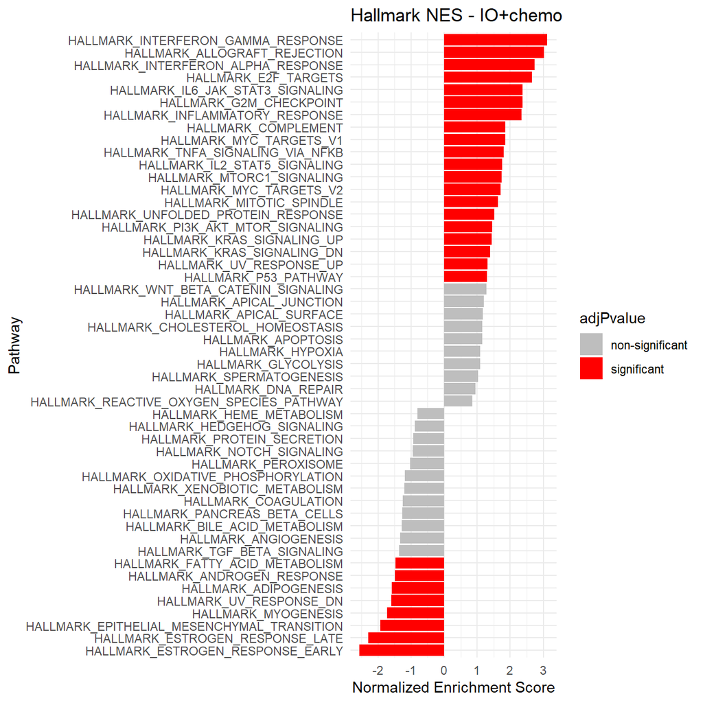

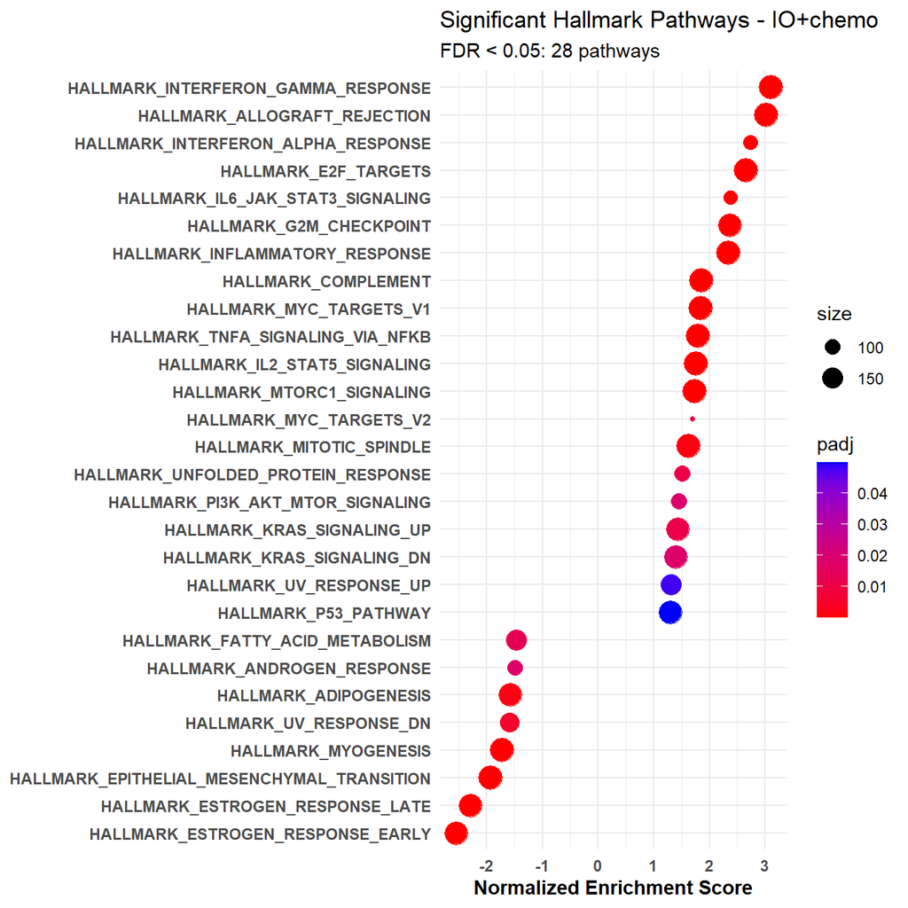

fgsea results - IO+chemo

| pathway | pval | padj | log2err | ES | NES | size | leadingEdge | adjPvalue |
| --- | --- | --- | --- | --- | --- | --- | --- | --- |
| HALLMARK_INTERFERON_GAMMA_RESPONSE | 0.0000000 | 0.0000000 | 1.5697917 | 0.7297628 | 3.1134492 | 194 | IDO1;CXCL9;CD38;CXCL10;CCL7;CCL5;TAP1;IRF1;SLAMF7;STAT1;IRF4;BATF2;ITGB7;GBP4;CCL2;PSMB9;IL2RB;SOD2;SAMD9L;RTP4;CXCL11;ZBP1;GZMA;SOCS1;BANK1;HLA-DQA1;OASL;ISG20;XCL1;CD74;GPR18;APOL6;IL15;ICAM1;PFKP;P… | significant |
| HALLMARK_ALLOGRAFT_REJECTION | 0.0000000 | 0.0000000 | 1.4815676 | 0.7095159 | 3.0286933 | 195 | CCL13;CXCL13;CXCL9;GZMB;CCL19;CCL7;CDKN2A;CCL5;LCK;TAP1;IL27RA;CD2;STAT1;CD79A;IRF4;IFNG;LTB;CD3D;CCL2;HLA-DOB;IL2RB;SIT1;HLA-E;LYN;MMP9;ZAP70;GZMA;SOCS1;HLA-DQA1;CCR2;CCR5;CCL4;CD96;CD247;FASLG;CD3G;… | significant |
| HALLMARK_INTERFERON_ALPHA_RESPONSE | 0.0000000 | 0.0000000 | 1.0276699 | 0.7152560 | 2.7421247 | 94 | LAMP3;CXCL10;TAP1;IRF1;BATF2;GBP4;SELL;PSMB9;SAMD9L;RTP4;CXCL11;OASL;ISG20;CD74;IL15;NCOA7;HLA-C;CASP1;IFI30;IFI44L;IFIH1;USP18;PSMB8;IFI44;PARP12;RIPK2;C1S;LAP3;EPSTI1;CD47;NMI;UBE2L6;B2M;OAS1;LY6E;T… | significant |
| HALLMARK_E2F_TARGETS | 0.0000000 | 0.0000000 | 1.1512205 | 0.6217707 | 2.6541375 | 195 | CDKN2A;CCNE1;ANP32E;MELK;KIF2C;NCAPD2;CDC20;CDCA3;LBR;MCM2;MYBL2;CDCA8;CKS1B;CHEK1;MCM4;DEK;CTPS1;GINS4;HMGA1;RFC2;RAD51AP1;MCM5;TUBB;CDC25A;NUP205;MCM3;CENPE;ORC6;PLK1;NASP;USP1;KIF4A;CHEK2;EZH2;BUB1… | significant |
| HALLMARK_IL6_JAK_STAT3_SIGNALING | 0.0000000 | 0.0000000 | 0.7881868 | 0.6228651 | 2.3774371 | 87 | CXCL13;CXCL9;CD38;CXCL10;CCL7;CXCL1;IRF1;STAT1;LTB;TNFRSF21;CXCL11;SOCS1;IL1R2;EBI3;CD14;PIM1;IL2RG;MYD88;IL2RA;TNF;PTPN2;IL17RA;TLR2;IL1B;BAK1;FAS;CSF2RA;CCR1;IL15RA;A2M;STAT3;TNFRSF1B;SOCS3;CD44;IL3… | significant |
| HALLMARK_G2M_CHECKPOINT | 0.0000000 | 0.0000000 | 0.9214260 | 0.5588274 | 2.3724189 | 188 | KIF2C;CDC20;LBR;MCM2;MYBL2;NDC80;CCNA2;CKS1B;CENPA;ODC1;CHEK1;TTK;UCK2;RAD54L;BUB1;EXO1;CENPF;TPX2;HMGA1;E2F3;MCM5;EFNA5;CDC25A;MCM3;CENPE;ORC6;CDC45;CDC7;PLK1;NASP;KIF4A;EZH2;KIF11;SMARCC1;PBK;E2F2;T… | significant |
| HALLMARK_INFLAMMATORY_RESPONSE | 0.0000000 | 0.0000000 | 0.9325952 | 0.5477553 | 2.3403762 | 197 | MARCO;LAMP3;CXCL9;CXCL10;CCL7;CCR7;CCL5;CCL17;LCK;IRF1;ITGB8;CX3CL1;CCL2;SELL;IL2RB;RASGRP1;CXCR6;LYN;GPR183;RTP4;CXCL11;ADORA2B;IL7R;EBI3;CD82;CHST2;IL15;ICAM1;ICAM4;CD14;SLAMF1;PDE4B;CD48;SPHK1;TLR1… | significant |
| HALLMARK_COMPLEMENT | 0.0000012 | 0.0000051 | 0.6435518 | 0.4350545 | 1.8580265 | 198 | LTF;GZMB;CCL5;CXCL1;LCK;CP;IRF1;PSMB9;CTSV;RASGRP1;GZMK;LYN;GZMA;FCN1;PLA2G7;C1QA;PLEK;CTSS;SPOCK2;PIM1;CD40LG;CR2;CASP1;C2;C1QC;PFN1;CEBPB;PLA2G4A;CTSC;APOBEC3G;C1S;LCP2;LAP3;APOBEC3F;C3;S100A9;CASP4… | significant |
| HALLMARK_MYC_TARGETS_V1 | 0.0000012 | 0.0000051 | 0.6435518 | 0.4328957 | 1.8479681 | 193 | TYMS;CDC20;MCM2;IFRD1;CCNA2;ODC1;MCM4;DEK;SRPK1;CTPS1;MCM5;ILF2;MRPL9;CDC45;CSTF2;USP1;PSMB2;RFC4;SMARCC1;PSMC4;LSM2;C1QBP;SRM;MCM6;FBL;KPNA2;CUL1;SNRPA1;STARD7;RANBP1;MCM7;PCNA;TFDP1;CAD;LSM7;MAD2L1;… | significant |
| HALLMARK_TNFA_SIGNALING_VIA_NFKB | 0.0000171 | 0.0000609 | 0.5756103 | 0.4213221 | 1.8001691 | 197 | CXCL10;CCL5;CXCL1;PTX3;TAP1;IRF1;CCL2;SOD2;GPR183;CXCL11;LAMB3;IL7R;CCL4;BIRC3;NFIL3;BCL2A1;PLEK;BTG3;ICAM1;DUSP2;PDE4B;CFLAR;SPHK1;CEBPB;MAP2K3;NFKBIE;IFIH1;TRAF1;VEGFA;RELB;CD83;TNF;RIPK2;STAT5A;TNF… | significant |
| HALLMARK_IL2_STAT5_SIGNALING | 0.0000147 | 0.0000564 | 0.5933255 | 0.4131564 | 1.7626844 | 194 | CXCL10;S100A1;CCNE1;GLIPR2;CD79B;IRF4;LTB;GBP4;ICOS;TNFRSF21;SELL;IL2RB;SOCS1;IL1R2;NOP2;NFIL3;ODC1;BATF3;TNFRSF8;UCK2;PIM1;CD48;CTLA4;TRAF1;IL10RA;PNP;IL2RA;TNFRSF4;NDRG1;RRAGD;CD83;IRF6;IRF8;TNFRSF9… | significant |
| HALLMARK_MTORC1_SIGNALING | 0.0000252 | 0.0000841 | 0.5756103 | 0.4067936 | 1.7355381 | 194 | PHGDH;PSAT1;DAPP1;CORO1A;FADS2;MCM2;IFRD1;NFIL3;PDK1;DDIT4;MCM4;CFP;BUB1;IFI30;ASNS;MAP2K3;STARD4;GLRX;CDC25A;SLA;NUP205;CTSC;TES;PNP;CXCR4;SSR1;ENO1;PLK1;RPN1;PSMC4;SLC7A5;NFKBIB;SLC1A5;UCHL5;GAPDH;P… | significant |
| HALLMARK_MYC_TARGETS_V2 | 0.0047193 | 0.0110176 | 0.4070179 | 0.4858569 | 1.7034406 | 57 | NOP2;MCM4;DUSP2;MCM5;BYSL;PLK1;SRM;RCL1;MYBBP1A;MPHOSPH10;PUS1;PPRC1;MYC;GRWD1;WDR74;UNG;TFB2M;MRTO4;PLK4;PPAN;DDX18;EXOSC5;NOP56;SUPV3L1;MAP3K6;NDUFAF4;UTP20;NOP16;CDK4;PES1;RRP9;HSPD1;LAS1L;NOC4L;NO… | significant |
| HALLMARK_MITOTIC_SPINDLE | 0.0004571 | 0.0013444 | 0.4984931 | 0.3815961 | 1.6304334 | 197 | KIF2C;NDC80;TTK;BUB1;ANLN;GEMIN4;FSCN1;CENPF;TPX2;CEP72;MID1;NCK1;CENPE;KIF1B;PLK1;NCK2;KIF4A;KIF11;PIF1;ARHGEF2;CDK1;KIF15;CEP192;NEK2;INCENP;DLGAP5;EPB41L2;TOP2A;SUN2;ARHGAP27;CCNB2;CDC42EP1;ECT2;AC… | significant |
| HALLMARK_UNFOLDED_PROTEIN_RESPONSE | 0.0042650 | 0.0106624 | 0.4070179 | 0.3874692 | 1.5232158 | 106 | PSAT1;CCL2;CKS1B;DDIT4;CEBPG;GEMIN4;CEBPB;ASNS;VEGFA;PDIA5;SSR1;SLC7A5;NABP1;HYOU1;TUBB2A;SPCS3;KDELR3;MTHFD2;CXXC1;HERPUD1;SRPRB;EIF4G1;TATDN2;NFYA;PDIA6;CALR;ATF4;EIF4A1;HSP90B1;POP4;DKC1;PREB;ALDH1… | significant |
| HALLMARK_PI3K_AKT_MTOR_SIGNALING | 0.0094468 | 0.0181669 | 0.3807304 | 0.3712101 | 1.4571595 | 104 | LCK;DAPP1;FASLG;PDK1;PRKCB;IL2RG;PFN1;MAP2K3;NCK1;SLA;MYD88;CXCR4;CDK1;MAPK1;NFKBIB;MAP2K6;E2F1;ACTR3;RAF1;CSNK2B;NGF;ARF1;NOD1;MKNK1;RPS6KA3;MAP3K7;SFN;CALR;HSP90B1;GNGT1 | significant |
| HALLMARK_KRAS_SIGNALING_UP | 0.0048478 | 0.0110176 | 0.4070179 | 0.3380277 | 1.4365328 | 191 | CXCL10;KCNN4;ADAMDEC1;HSD11B1;MPZL2;LCP1;GPRC5B;MMP9;SLPI;SOX9;IL7R;BIRC3;TMEM176B;TMEM100;CTSS;TMEM158;IL2RG;CD37;MALL;GLRX;CLEC4A;IKZF1;PSMB8;LAPTM5;TMEM176A;TRAF1;MYCN;IL10RA;ST6GAL1;CXCR4;MAP4K1;I… | significant |
| HALLMARK_KRAS_SIGNALING_DN | 0.0088252 | 0.0176817 | 0.3807304 | 0.3275109 | 1.3918388 | 191 | KRT5;KLK8;KRT15;CALML5;SLC6A14;SOX10;TCL1A;KLK7;TFCP2L1;IFNG;TCF7L1;PDCD1;TGM1;KRT13;LGALS7;CHST2;CD40LG;IFI44L;GPR19;STAG3 | significant |
| HALLMARK_UV_RESPONSE_UP | 0.0258557 | 0.0478810 | 0.3524879 | 0.3171729 | 1.3088771 | 154 | TAP1;IRF1;CCNE1;GAL;CTSV;HLA-F;SOD2;RASGRP1;LYN;CEBPG;CCK;BTG3;ICAM1;ASNS;FEN1;BID;KLHDC3;RFC4;RPN1;E2F5;CHRNA5;COL2A1;GGH;CXCL2;AMD1;BAK1;NPTX2;ALAS1;ARRB2 | significant |
| HALLMARK_P53_PATHWAY | 0.0278196 | 0.0496779 | 0.3524879 | 0.3055945 | 1.2986999 | 191 | KLK8;KRT17;CDKN2A;LDHB;TAP1;TM4SF1;SOCS1;SERPINB5;TCN2;DDIT4;CD82;STEAP3;CASP1;IFI30;SPHK1;NDRG1;APP;ST14;BAK1;SEC61A1;IRAK1;DEF6;FAS;TPD52L1;SLC3A2;PERP;HSPA4L;ADA;S100A10;S100A4;RHBDF2;FBXW7;PCNA;UP… | significant |
| HALLMARK_WNT_BETA_CATENIN_SIGNALING | 0.1226415 | 0.1703354 | 0.1957890 | 0.3942551 | 1.2867740 | 42 | WNT6;DKK1;SKP2;TCF7;CUL1;WNT5B;NOTCH1;CCND2;ADAM17;PPARD;NCSTN;MYC | non-significant |
| HALLMARK_APICAL_JUNCTION | 0.0785908 | 0.1350621 | 0.2663507 | 0.2825600 | 1.2007586 | 190 | CDH3;ACTG2;CX3CL1;MPZL2;NRTN;ICAM2;CLDN4;MMP9;LAMB3;ICAM1;ICAM4;CD274;MDK;PFN1;FSCN1;ITGA9;DSC3;MSN;TRAF1;VCAM1;CALB2;MPZL1;RAC2;NFASC;ADAM15;SYK;RSU1;DHX16;LAMC2;EPB41L2;ACTN4;SPEG;ACTB;COL9A1;PTPRC;… | non-significant |
| HALLMARK_APICAL_SURFACE | 0.2227378 | 0.2651641 | 0.1404062 | 0.3550673 | 1.1683219 | 43 | CX3CL1;IL2RB;LYN;MAL;IL2RG;ATP6V0A4;GHRL;RHCG;EFNA5;APP;AKAP7 | non-significant |
| HALLMARK_CHOLESTEROL_HOMEOSTASIS | 0.1865672 | 0.2391887 | 0.1608014 | 0.3142112 | 1.1603949 | 72 | CBS;GLDC;FADS2;NFIL3;S100A11;STARD4;FABP5;FBXO6;CXCL16;PNRC1;DHCR7;PLAUR;LGMN;ACAT2;PLSCR1;ATF5;MVD;ANXA5;HMGCS1;SREBF2;PDK3;FDPS | non-significant |
| HALLMARK_APOPTOSIS | 0.1432361 | 0.1884685 | 0.1918922 | 0.2787664 | 1.1535993 | 159 | CD38;TAP1;IRF1;CD2;SOD2;ISG20;FASLG;BIRC3;BTG3;CD14;CFLAR;CASP1;PRF1;BID;TNF;APP;IL1B;CDC25B;CD69;GNA15;NEFH;FAS;MCL1;CASP4;SATB1;CASP6;IL18;TOP2A;DFFA;TIMP1;LMNA;CCND2;CD44;BAX;PAK1;PLCB2;IL6;IFNGR1;… | non-significant |
| HALLMARK_HYPOXIA | 0.2093664 | 0.2553249 | 0.1596467 | 0.2586199 | 1.0990694 | 191 | CP;CSRP2;ADORA2B;ISG20;CHST3;NFIL3;PDK1;DDIT4;PLAC8;CHST2;PFKP;PIM1;GLRX;ADM;TES;VEGFA;NDRG1;CXCR4;RRAGD;ENO1;SCARB1;PKP1;GCNT2;PNRC1;CASP6;XPNPEP1;LALBA;TMEM45A;GAPDH;PGM1;EFNA1;S100A4;TGM2;KDELR3;TP… | non-significant |
| HALLMARK_GLYCOLYSIS | 0.2000000 | 0.2500000 | 0.1656567 | 0.2571276 | 1.0986207 | 197 | DSC2;SOX9;ADORA2B;ISG20;CHST6;CENPA;DDIT4;CHST2;PFKP;GLRX;VEGFA;GNE;CXCR4;CLDN3;RRAGD;PYGB;ENO1;NASP;KIF20A;PSMC4;PLOD1;CDK1;STMN1;ELF3;CASP6;PRPS1;SLC25A13;GPR87;KDELR3;MDH2;TPI1;SPAG4;VLDLR;PKP2;COP… | non-significant |
| HALLMARK_SPERMATOGENESIS | 0.4114583 | 0.4675663 | 0.1055209 | 0.2533506 | 1.0213697 | 132 | IL12RB2;ART3;KIF2C;RPL39L;TTK;BUB1;RFC4;EZH2;TLE4;GFI1;LPIN1;CDK1;NEFH;OAZ3;NEK2;PCSK1N;HSPA4L;POMC;CCNB2;PSMG1;AURKA;CCNA1;ADAD1;SLC2A5;VDAC3;BRAF;CFTR;NAA11;MLLT10;MTOR;NF2;NCAPH;TOPBP1;LDHC;TSN;CLP… | non-significant |
| HALLMARK_DNA_REPAIR | 0.5623342 | 0.6112328 | 0.0880945 | 0.2335727 | 0.9521379 | 145 | TYMS;PDE4B;FEN1;RFC2;HCLS1;PNP;RFC4;SF3A3;SUPT5H;VPS37B;SEC61A1;SSRP1;POLR1C;CLP1;ADA;POLR2D;RPA2;TAF1C;RFC5;PCNA;DGCR8;GTF3C5;POLD1;ERCC3;NELFB;POLR2F;RAD51;ITPA;UPF3B;GTF2B;POLA2;NELFE;RNMT;POLR2C;L… | non-significant |
| HALLMARK_REACTIVE_OXYGEN_SPECIES_PATHWAY | 0.7529976 | 0.7683649 | 0.0675189 | 0.2546959 | 0.8492799 | 47 | SOD2;MGST1;PFKP;GLRX;LSP1;PRNP;STK25;PRDX4;NDUFS2;FES;MSRA;MPO | non-significant |
| HALLMARK_HEME_METABOLISM | 0.9112520 | 0.9112520 | 0.0392759 | -0.2027954 | -0.8106263 | 189 | HBB;TRIM58;BLVRB;HBD;HAGH;VEZF1;BLVRA;NUDT4;MBOAT2;TRAK2;HEBP1;RAP1GAP;TMEM9B;TSPAN5;ABCB6;ALDH6A1;PIGQ;PGLS;ARL2BP;ABCG2;TAL1;SELENBP1;SLC22A4;TNS1;KLF3;GDE1;DAAM1;FECH;BCAM;HBQ1;GYPA;SYNJ1;BNIP3L | non-significant |
| HALLMARK_HEDGEHOG_SIGNALING | 0.6286701 | 0.6600660 | 0.0603786 | -0.2924631 | -0.8885567 | 35 | GLI1;CELSR1;HEY1;CRMP1;THY1;TLE3;RASA1 | non-significant |
| HALLMARK_PROTEIN_SECRETION | 0.6336634 | 0.6600660 | 0.0578530 | -0.2572124 | -0.9374519 | 94 | KRT18;TOM1L1;TSPAN8;SCAMP1;SOD1;GALC;SCRN1;RAB22A;SSPN;ARFIP1;STX16;TSG101;ICA1;CAV2;AP2B1;TPD52;SGMS1;CLN5;SH3GL2 | non-significant |
| HALLMARK_NOTCH_SIGNALING | 0.5303293 | 0.5892548 | 0.0687943 | -0.3158700 | -0.9436889 | 32 | CCND1;SKP1;WNT5A;LFNG;ARRB1;HEYL;DLL1 | non-significant |
| HALLMARK_PEROXISOME | 0.4062500 | 0.4675663 | 0.0797706 | -0.2795655 | -1.0290644 | 104 | ABCC8;SULT2B1;PEX11A;SEMA3C;CRAT;SLC27A2;DHCR24;ELOVL5;ISOC1;ABCC5;SOD1;LONP2;SERPINA6;CRABP2;HRAS;ALB;ACOX1;RDH11;HMGCL;DIO1;CDK7;SLC25A4;ECI2;CLN8;TTR | non-significant |
| HALLMARK_OXIDATIVE_PHOSPHORYLATION | 0.1167192 | 0.1667418 | 0.1619789 | -0.2982483 | -1.1902583 | 184 | COX6C;ACADSB;PDK4;CYB5A;NDUFC2;NDUFA2;ATP6V1G1;GPX4;CPT1A;MRPS30;ETFB;ATP6V1D;ATP6AP1;UQCRQ;TIMM13;HSPA9;ALDH6A1;NDUFB4;NDUFB1;NDUFA7;COX17;UQCRB;COX7C;ETFDH;PDHB;UQCR11;ECI1;COX5A;NDUFA6;ACAA2;SURF1;… | non-significant |
| HALLMARK_XENOBIOTIC_METABOLISM | 0.1045242 | 0.1537200 | 0.1709323 | -0.2992047 | -1.2060489 | 194 | ACOX2;ESR1;NQO1;FBP1;UGDH;BLVRB;MAOA;ABCC3;PDK4;FAH;ACSM1;CYB5A;DCXR;IGFBP4;CD36;NINJ1;ELOVL5;KYNU;RAP1GAP;MCCC2;CDO1;HES6;SERPINA6;CSAD;GSTT2;ABHD6;CYP26A1;PTGES3;CROT;ETFDH;MPP2;GNMT;FBLN1;GSS;ACOX1 | non-significant |
| HALLMARK_COAGULATION | 0.0861244 | 0.1363255 | 0.1918922 | -0.3221999 | -1.2469578 | 137 | ACOX2;PLAT;COMP;MMP11;HTRA1;TIMP3;PRSS23;FBN1;SPARC;HPN;CFD;MMP10;TFPI2;TMPRSS6;ITGA2;CTSK;CRIP2;MMP14;OLR1;F2RL2;MMP2;FGG;THBS1;F12;CTSO;GNG12;FN1 | non-significant |
| HALLMARK_PANCREAS_BETA_CELLS | 0.1416235 | 0.1884685 | 0.1531588 | -0.4099242 | -1.2736226 | 40 | SYT13;ABCC8;SCGN;STXBP1;SRP9;ELP4;PCSK2;SRP14;GCG;NKX2-2 | non-significant |
| HALLMARK_BILE_ACID_METABOLISM | 0.0810373 | 0.1350621 | 0.1999152 | -0.3406667 | -1.2742400 | 112 | AR;PEX11G;NUDT12;FDXR;SULT2B1;PEX11A;SLC27A2;ABCA3;DHCR24;LIPE;SLC22A18;PEX16;ISOC1;SOD1;LONP2;SERPINA6;HSD3B1;NEDD4;ABCA5;CROT;GNMT;PFKM;ABCA9;DIO1;AKR1D1;BCAR3;PEX7;PEX19;DIO2;TTR;PEX12;HSD17B6;PECR… | non-significant |
| HALLMARK_ANGIOGENESIS | 0.1045296 | 0.1537200 | 0.1813831 | -0.4381199 | -1.3310481 | 36 | SERPINA5;COL3A1;POSTN;COL5A2;LUM;PDGFA;VCAN;OLR1;FGFR1;FSTL1;MSX1 | non-significant |
| HALLMARK_TGF_BETA_SIGNALING | 0.0872483 | 0.1363255 | 0.1957890 | -0.4128886 | -1.3629498 | 54 | RAB31;TGFBR1;CDKN1C;BMPR2;THBS1;PMEPA1;SLC20A1;SMAD3;BCAR3;APC;SMURF1;LTBP2;XIAP;KLF10;NCOR2;SMAD1;SERPINE1;SMAD7;TRIM33;SMAD6;SPTBN1;PPM1A;TJP1;SKIL | non-significant |
| HALLMARK_FATTY_ACID_METABOLISM | 0.0061024 | 0.0132660 | 0.4070179 | -0.3773177 | -1.4709146 | 152 | REEP6;HPGD;UGDH;SLC22A5;FASN;MAOA;CRAT;DHCR24;ACOT2;BLVRA;CD36;BMPR1B;SERINC1;LTC4S;ELOVL5;ENO2;AOC3;MGLL;CIDEA;INMT;CPT1A;ETFDH;SUCLG2;ALDOA;PDHB;ECI1;ACOX1;RDH11;HMGCL;CA4;ACADL;ACAA2;HSDL2;PTPRG;EC… | significant |
| HALLMARK_ANDROGEN_RESPONSE | 0.0088409 | 0.0176817 | 0.3807304 | -0.4088864 | -1.4938568 | 96 | SPDEF;HPGD;CCND1;SORD;SCD;INPP4B;GPD1L;DHCR24;STK39;STEAP4;KRT19;AKAP12;KRT8;BMPR1B;ELOVL5;ABHD2;HOMER2;HERC3;ANKH;PMEPA1;ACSL3;KLK3;TPD52;APPBP2;TSC22D1;ZMIZ1;MAK;PA2G4 | significant |
| HALLMARK_ADIPOGENESIS | 0.0006613 | 0.0018371 | 0.4772708 | -0.3920536 | -1.5761224 | 192 | REEP6;CYP4B1;HSPB8;REEP5;FZD4;OMD;TOB1;CRAT;FAH;SPARCL1;LIPE;PTGER3;FABP4;CD36;QDPR;LTC4S;DGAT1;MGLL;CIDEA;SULT1A1;GPX4;ETFB;SOD1;UQCRQ;CD151;SSPN;MAP4K3;ALDOA;UQCR11;SLC27A1;ADIPOQ;ACOX1;DNAJC15;ACAD… | significant |
| HALLMARK_UV_RESPONSE_DN | 0.0020061 | 0.0052793 | 0.4317077 | -0.4131834 | -1.5970308 | 138 | IGFBP5;COL11A1;IRS1;COL3A1;COL1A1;COL1A2;GJA1;IGF1R;PDGFRB;INPP4B;DUSP1;COL5A2;SLC22A18;ANXA2;MAGI2;BHLHE40;AMPH;MGLL;APBB2;MMP16;MGMT;AGGF1;CAV1;SRI;SNAI2;PRKAR2B;KCNMA1;BDNF;LPAR1;RUNX1;ICA1;SMAD3;P… | significant |
| HALLMARK_MYOGENESIS | 0.0000443 | 0.0001385 | 0.5573322 | -0.4292958 | -1.7304781 | 196 | TNNT1;SPDEF;PPP1R3C;APOD;NQO1;STC2;COL3A1;COL1A1;SCD;CACNA1H;HSPB8;AEBP1;PVALB;SPARC;COX7A1;CRAT;CFD;REEP1;CACNG1;ITGB5;AGL;CAV3;ADCY9;TNNC2;BDKRB2;CD36;CAMK2B;MYOM2;IGFBP7;SGCD;BHLHE40;OCEL1;VIPR1;MY… | significant |
| HALLMARK_EPITHELIAL_MESENCHYMAL_TRANSITION | 0.0000003 | 0.0000013 | 0.6749629 | -0.4777132 | -1.9261731 | 195 | AREG;COMP;COL11A1;MATN3;SPOCK1;COL3A1;HTRA1;COL1A1;IGFBP2;FAP;POSTN;COL1A2;GJA1;COL8A2;TIMP3;PDGFRB;THBS2;SFRP4;FBN1;SPARC;FSTL3;COL12A1;EDIL3;ECM2;RHOB;ITGB5;TFPI2;COL5A2;ECM1;CDH11;INHBA;IGFBP4;LUM;… | significant |
| HALLMARK_ESTROGEN_RESPONSE_LATE | 0.0000000 | 0.0000000 | 0.9436322 | -0.5718600 | -2.2989750 | 192 | AGR2;TFF1;CA12;TFF3;ACOX2;SCUBE2;DHRS2;PDZK1;ANXA9;AREG;NPY1R;TPSAB1;DNAJC12;CHST8;COX6C;RET;CXCL14;MAPT;SERPINA5;PGR;CACNA2D2;CCND1;UGDH;SORD;SCNN1A;CPE;SLC22A5;MYB;OLFM1;NRIP1;HSPB8;TSPAN13;CISH;BLV… | significant |
| HALLMARK_ESTROGEN_RESPONSE_EARLY | 0.0000000 | 0.0000000 | 1.1421912 | -0.6378163 | -2.5551955 | 190 | TFF1;CA12;TFF3;MSMB;SLC7A2;DHRS2;PDZK1;ANXA9;AR;AREG;NPY1R;SLC39A6;MLPH;GFRA1;THSD4;RET;MAPT;SLC1A1;SYBU;PGR;MAST4;CCND1;SCNN1A;STC2;SLC22A5;MYB;SLC19A2;KRT18;ELOVL2;OLFM1;UGCG;ABAT;FASN;NRIP1;HSPB8;G… | significant |

[output not shown]

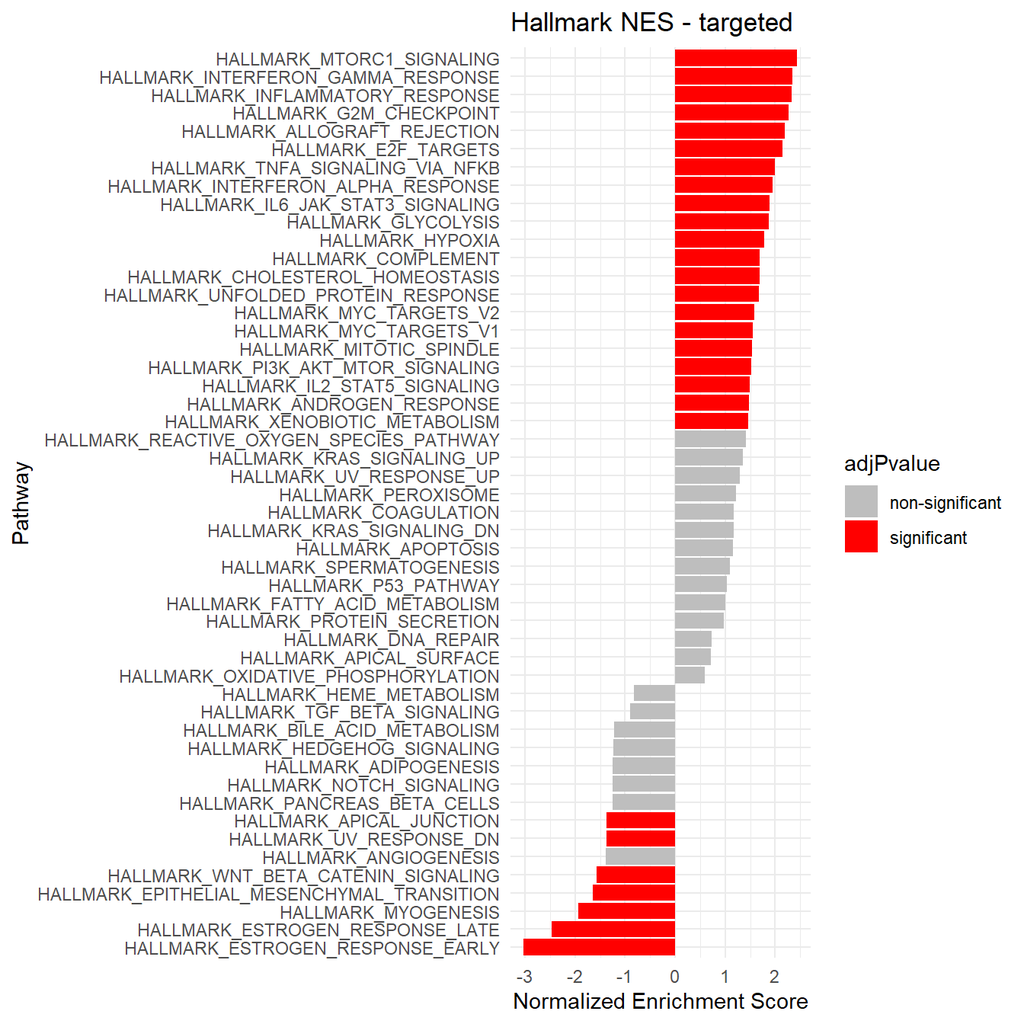

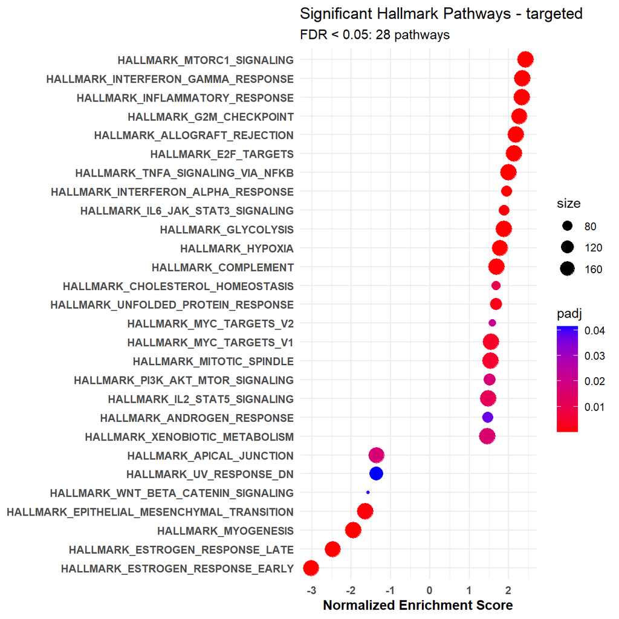

fgsea results - targeted

| pathway | pval | padj | log2err | ES | NES | size | leadingEdge | adjPvalue |
| --- | --- | --- | --- | --- | --- | --- | --- | --- |
| HALLMARK_MTORC1_SIGNALING | 0.0000000 | 0.0000000 | 0.9653278 | 0.5716615 | 2.4329474 | 194 | PSAT1;FADS2;PDK1;DDIT4;EGLN3;TRIB3;PHGDH;IFI30;P4HA1;TMEM97;DHCR7;TUBA4A;PSPH;MTHFD2;PNP;TFRC;DHCR24;SDF2L1;GPI;GSR;PGK1;BUB1;AURKA;PSMB5;PIK3R3;SHMT2;ME1;IDH1;LDHA;NAMPT;RRM2;CXCR4;DAPP1;ASNS;ACTR3;S… | significant |
| HALLMARK_INTERFERON_GAMMA_RESPONSE | 0.0000000 | 0.0000000 | 0.9101197 | 0.5520072 | 2.3493003 | 194 | CCL7;CD38;SLAMF7;IRF5;PFKP;IRF4;PDE4B;CXCL9;TNFSF10;IFI30;MT2A;SOD2;ZBP1;ITGB7;STAT1;IDO1;MTHFD2;PNP;APOL6;CXCL10;CXCL11;ISG20;GBP4;HIF1A;UPP1;CASP7;CCL2;BATF2;ICAM1;NAMPT;IL2RB;LAP3;GCH1;HLA-B;CCL5;R… | significant |
| HALLMARK_INFLAMMATORY_RESPONSE | 0.0000000 | 0.0000000 | 0.9325952 | 0.5484666 | 2.3329351 | 197 | MARCO;CCL7;AQP9;ADM;PDE4B;CXCL9;TNFSF10;RNF144B;P2RY2;OLR1;ICAM4;EDN1;TLR2;SLC31A1;CCL20;CXCL10;CXCL11;HIF1A;CCL17;RGS1;OSM;KCNA3;CXCR6;CCL2;ICAM1;SLAMF1;IL18;NAMPT;PLAUR;SLC7A1;IL1R1;IL2RB;GCH1;CCL5;… | significant |
| HALLMARK_G2M_CHECKPOINT | 0.0000000 | 0.0000000 | 0.8753251 | 0.5364239 | 2.2668872 | 188 | CDC45;CDC20;MT2A;CDK1;HMGB3;KIF2C;UBE2C;CENPA;HMMR;HIF1A;BRCA2;E2F1;CCNB2;CENPF;BUB1;CDKN3;AURKA;RAD54L;TTK;EXO1;FBXO5;NASP;SLC7A1;BIRC5;MYBL2;SQLE;KIF23;NUSAP1;NDC80;NEK2;KIF11;KIF4A;CKS1B;RPS6KA5;RA… | significant |
| HALLMARK_ALLOGRAFT_REJECTION | 0.0000000 | 0.0000000 | 0.8266573 | 0.5138500 | 2.1856162 | 195 | CCL7;GZMB;CCL4;IRF4;DEGS1;CD79A;CXCL9;CXCL13;IFNG;FCGR2B;CCR1;STAT1;TLR2;HLA-E;CTSS;HIF1A;CCR2;CCL13;IL12A;TGFB2;SRGN;CD2;CCL2;FASLG;IL13;ICAM1;IL18;FGR;IL2RB;BCAT1;CCL5;NCF4;TAP1;IFNAR2;HLA-G;CCR5;IN… | significant |
| HALLMARK_E2F_TARGETS | 0.0000000 | 0.0000000 | 0.7881868 | 0.5028306 | 2.1387459 | 195 | SPAG5;CCNE1;E2F8;CDC20;CDK1;MELK;HMGB3;KIF2C;MTHFD2;DLGAP5;TFRC;HMMR;TRIP13;BRCA2;CCNB2;CDKN3;AURKA;UBE2T;TK1;RRM2;CDCA8;NASP;BIRC5;PRDX4;MYBL2;ATAD2;RAD51AP1;MCM4;CTPS1;KIF4A;CKS1B;NCAPD2;GINS1;RANBP… | significant |
| HALLMARK_TNFA_SIGNALING_VIA_NFKB | 0.0000001 | 0.0000005 | 0.7049757 | 0.4679128 | 1.9902948 | 197 | PHLDA2;CCL4;PDE4B;CXCL1;DUSP4;SOD2;KYNU;OLR1;B4GALT5;CEBPB;EDN1;TLR2;CCL20;CXCL10;CXCL11;SGK1;PLAU;DUSP5;CCL2;ICAM1;IL18;NAMPT;PLAUR;BCL2A1;GCH1;CCL5;VEGFA;CXCL6;MAP2K3;TAP1;CD80;SLC2A3;CCRL2;IL6;ZFP3… | significant |
| HALLMARK_INTERFERON_ALPHA_RESPONSE | 0.0000258 | 0.0000990 | 0.5756103 | 0.5094589 | 1.9507036 | 94 | IFI30;CXCL10;CXCL11;ISG20;GBP4;BATF2;HLA-C;LAP3;RSAD2;MX1;CASP8;TAP1;OASL;GBP2;CCRL2;USP18;B2M;SP110;PSME2;PSMB9;ISG15;BST2;IFIT2;TRIM14;SAMD9L;LAMP3;IFIT3;NMI;PNPT1;NCOA7;IRF7;PSMA3;IRF2;PARP12;PARP1… | significant |
| HALLMARK_IL6_JAK_STAT3_SIGNALING | 0.0003061 | 0.0009567 | 0.4984931 | 0.4966328 | 1.8825410 | 87 | CCL7;CD38;CXCL9;CXCL1;CXCL13;CCR1;STAT1;TNFRSF21;TLR2;CXCL10;CXCL11;TNFRSF12A;HMOX1;IL1R1;IL2RA;IL6;IL13RA1;CSF2;CD14;CXCL3;IL15RA;IL1B;IL2RG | significant |
| HALLMARK_GLYCOLYSIS | 0.0000020 | 0.0000090 | 0.6272567 | 0.4418003 | 1.8792238 | 197 | ANGPTL4;GPC4;PFKP;DDIT4;B3GNT3;EGLN3;P4HA1;CDK1;SLC16A3;SRD5A3;SDC1;GNE;SPAG4;CENPA;HMMR;ISG20;PGK1;AURKA;GALE;AKR1A1;ME1;IDH1;LDHA;CXCR4;MIF;CITED2;NASP;MED24;PLOD2;VLDLR;VEGFA;ENO1;AK4;PKP2;HK2;BPNT… | significant |
| HALLMARK_HYPOXIA | 0.0000200 | 0.0000835 | 0.5756103 | 0.4185119 | 1.7731220 | 191 | ANGPTL4;TMEM45A;CP;ADM;PDK1;GPC4;PFKP;EDN2;DDIT4;MT2A;P4HA1;ISG20;GPI;PGK1;ERRFI1;LDHA;PLAUR;NDRG1;CXCR4;MIF;CITED2;WSB1;HMOX1;GAPDH;SLC2A5;PLIN2;VLDLR;VEGFA;ENO1;AK4;B4GALNT2;TES;SLC2A3;TPST2;FBP1;HK… | significant |
| HALLMARK_COMPLEMENT | 0.0001259 | 0.0004495 | 0.5188481 | 0.3981679 | 1.6936574 | 198 | S100A9;DUSP6;CP;GZMB;PDP1;PRSS36;CXCL1;PLA2G7;APOC1;KYNU;OLR1;PHEX;CEBPB;CPM;CTSS;F7;CD46;CASP7;C1QA;DUSP5;FN1;ME1;PLAUR;CTSD;GPD2;CA2;LAP3;CTSC;CCL5;C1QC;CASP3;FCER1G;GZMA;ITGAM;IL6;CD55;CASP10;MMP13… | significant |
| HALLMARK_CHOLESTEROL_HOMEOSTASIS | 0.0044579 | 0.0111448 | 0.4070179 | 0.4564869 | 1.6837587 | 72 | FADS2;TRIB3;TMEM97;DHCR7;CBS;TNFRSF12A;MAL2;ECH1;ERRFI1;PLAUR;SQLE;SREBF2;S100A11;FDPS;LDLR;HMGCS1;TP53INP1;ALCAM;NFIL3;MVD;FASN;EBP;LGALS3;IDI1;LSS;TM7SF2;CXCL16;ETHE1;PDK3;PLSCR1 | significant |
| HALLMARK_UNFOLDED_PROTEIN_RESPONSE | 0.0007871 | 0.0023150 | 0.4772708 | 0.4314078 | 1.6781080 | 106 | PSAT1;DDIT4;CEBPB;SPCS3;MTHFD2;HERPUD1;NABP1;CCL2;ASNS;ATF4;DNAJB9;CALR;VEGFA;EIF4EBP1;EIF2AK3;CKS1B;KDELR3;SSR1;WIPI1;HSP90B1;KIF5B;YWHAZ;XPOT;EIF2S1;NOLC1;CHAC1;XBP1;PDIA5;ERN1;DNAJC3;EDEM1;ALDH18A1… | significant |
| HALLMARK_MYC_TARGETS_V2 | 0.0108757 | 0.0217515 | 0.3807304 | 0.4488406 | 1.5836498 | 57 | TMEM97;MCM4;HK2;SLC19A1;GNL3;UNG;SRM;IMP4;IPO4;HSPD1;NOLC1;MCM5;DUSP2;RCL1;MRTO4;SLC29A2;DDX18;PLK1;CBX3;NIP7;MAP3K6 | significant |
| HALLMARK_MYC_TARGETS_V1 | 0.0012696 | 0.0035267 | 0.4550599 | 0.3654627 | 1.5508814 | 193 | PSMD3;PABPC1;CDC45;CDC20;TYMS;PGK1;LDHA;PRDX4;EEF1B2;MCM4;CTPS1;RPS5;RANBP1;AP3S1;GNL3;SRM;KPNA2;HDAC2;TRA2B;XPOT;EIF2S1;RAD23B;PABPC4;CCNA2;HSPD1;UBE2L3;EIF3D;NOLC1;MCM5;PSMD8;MAD2L1;SRPK1;EXOSC7;PSM… | significant |
| HALLMARK_MITOTIC_SPINDLE | 0.0018866 | 0.0049648 | 0.4550599 | 0.3613035 | 1.5368259 | 197 | CDK1;TUBA4A;KIF2C;ANLN;DLGAP5;DYNLL2;BRCA2;ECT2;CCNB2;CENPF;ARHGAP27;BUB1;AURKA;TUBD1;PIF1;TTK;FBXO5;BIRC5;KIF23;CDC42EP1;NUSAP1;NDC80;NEK2;KIF11;KIF4A;SHROOM1;RACGAP1;STK38L;KIF15;CSNK1D;EZR;SMC4;KIF… | significant |
| HALLMARK_PI3K_AKT_MTOR_SIGNALING | 0.0078869 | 0.0168946 | 0.3807304 | 0.3914900 | 1.5192221 | 104 | PDK1;TRIB3;CDK1;E2F1;PIK3R3;FASLG;PRKAA2;CXCR4;DAPP1;ACTR3;CALR;PLCB1;MAP2K3;HSP90B1;MAP2K6;IL2RG;MAPK1;CLTC;NGF;ARF1;ACTR2;DDIT3;SFN;PPP2R1B;MAPK10;PTPN11;TIAM1;FGF17;CAB39L;MAPK9;FGF22;MYD88;IL4 | significant |
| HALLMARK_IL2_STAT5_SIGNALING | 0.0050710 | 0.0120738 | 0.4070179 | 0.3489849 | 1.4852531 | 194 | SPP1;IRF4;CCNE1;TNFSF10;P4HA1;PNP;TNFRSF21;CXCL10;GBP4;PTRH2;CTLA4;IL13;TTC39B;ETV4;NDRG1;ENPP1;IL2RB;ICOS;CA2;PLIN2;CASP3;SLC1A5;IL2RA;SPRED2;SLC2A3;HK2;CD79B;BATF;RGS16;ALCAM;CSF2;NFIL3;GLIPR2;CKAP4… | significant |
| HALLMARK_ANDROGEN_RESPONSE | 0.0193277 | 0.0371687 | 0.3524879 | 0.3827311 | 1.4702943 | 96 | DBI;LMAN1;SPDEF;SPCS3;UBE2J1;TMPRSS2;DHCR24;SGK1;GSR;NDRG1;UAP1;PGM3;DNAJB9;CENPN;MYL12A;ELL2;B2M;NGLY1;HMGCS1;ABCC4;TNFAIP8;MAK;SLC38A2;SEC24D;SAT1;IDI1;RAB4A;FKBP5;APPBP2;INSIG1 | significant |
| HALLMARK_XENOBIOTIC_METABOLISM | 0.0070249 | 0.0159657 | 0.4070179 | 0.3416772 | 1.4541518 | 194 | HSD17B2;ACOX2;AQP9;ABCC3;PAPSS2;MT2A;XDH;HSD11B1;TMEM97;KYNU;COMT;TDO2;NQO1;SPINT2;UPP1;GSR;TGFB2;GNMT;ECH1;SHMT2;PYCR1;IDH1;ARG2;HMOX1;IL1R1;BCAT1;DDT;CA2;GCH1;TTPA;SLC1A5;FBP1;APOE | significant |
| HALLMARK_REACTIVE_OXYGEN_SPECIES_PATHWAY | 0.0652819 | 0.1052934 | 0.2139279 | 0.4178187 | 1.4190021 | 47 | PFKP;SOD2;NQO1;MGST1;GSR;PRDX4;FTL;GLRX;PRDX1;TXN;TXNRD1;TXNRD2;PRDX6;G6PD;IPCEF1 | non-significant |
| HALLMARK_KRAS_SIGNALING_UP | 0.0431472 | 0.0719120 | 0.2450418 | 0.3177802 | 1.3463489 | 191 | DUSP6;ANGPTL4;SPP1;MYCN;GALNT3;ADAMDEC1;ST6GAL1;HSD11B1;ADAM8;PLEK2;CCL20;CXCL10;CTSS;TLR8;PLAU;MPZL2;PLAUR;ETV4;CXCR4;PRDM1;CA2;LAPTM5;FCER1G;TRIB2;AMMECR1;ITGB2;GLRX;RGS16;TRIB1;PDCD1LG2;CSF2;CFHR2;… | non-significant |
| HALLMARK_UV_RESPONSE_UP | 0.0852713 | 0.1291990 | 0.1723243 | 0.3137080 | 1.2970736 | 154 | STARD3;CCNE1;SOD2;GAL;TUBA4A;TFRC;ICAM1;BID;PARP2;AQP3;ASNS;HMOX1;PDLIM3;AP2S1;POLR2H;CA2;EPCAM;GCH1;GGH;CASP3;TAP1;CHRNA5;LHX2;IL6;AGO2;ACAA1;FOS | non-significant |
| HALLMARK_PEROXISOME | 0.1634349 | 0.2150459 | 0.1250334 | 0.3116182 | 1.2092704 | 104 | CRAT;PABPC1;SOD2;CRABP1;IDH2;DHCR24;ACSL1;ECH1;NUDT19;IDH1;SLC25A19;FABP6;TSPO;CTPS1;FDPS;ACAA1;SLC25A17;PRDX1;TOP2A;IDE;RDH11;BCL10;IDI1;YWHAH;SCGB1A1;UGT2B17 | non-significant |
| HALLMARK_COAGULATION | 0.1907285 | 0.2384106 | 0.1114627 | 0.2894384 | 1.1740735 | 137 | FGG;MMP1;DUSP6;ACOX2;HMGCS2;APOC1;F12;OLR1;MMP3;C1QA;PLAU;COMP;FN1;CAPN2;PROZ;FGA;ARF4;CTSE;SH2B2;APOC2;THBS1;MBL2 | non-significant |
| HALLMARK_KRAS_SIGNALING_DN | 0.1725888 | 0.2212677 | 0.1152400 | 0.2759224 | 1.1690089 | 191 | PNMT;TFAP2B;AKR1B10;PRODH;CALML5;EDN2;IFNG;SPRR3;RIBC2;EDN1;SGK1;TGFB2;PDCD1;ENTPD7;RSAD2;MX1;CD80;MFSD6;SPTBN2;EGF;NR4A2;TCL1A;KRT4;THRB;SLC30A3;LFNG;GPR19;CCR8;BARD1;CYP11B2;YPEL1;SIDT1;SCN10A;SERPI… | non-significant |
| HALLMARK_APOPTOSIS | 0.2034121 | 0.2480635 | 0.1067299 | 0.2801566 | 1.1560554 | 159 | ERBB2;CD38;TNFSF10;SOD2;ISG20;CASP7;TNFRSF12A;GSR;TGFB2;CD2;FASLG;IL18;BID;HMOX1;GCH1;TSPO;CASP8;CASP3;TAP1;IL6;CD69;GPX1;EBP;CD14;LGALS3;CFLAR;EREG;TOP2A | non-significant |
| HALLMARK_SPERMATOGENESIS | 0.2900662 | 0.3453169 | 0.0862866 | 0.2728018 | 1.1001544 | 132 | DPEP3;CRISP2;CDK1;KIF2C;CCNB2;BUB1;CDKN3;AURKA;TTK;PARP2;SLC2A5;OAZ3;NEK2;ADAD1;PSMG1;EZH2;NCAPH;TNP1;AGFG1;LDHC;GAD1;TNP2;IDE;DBF4;DMRT1;RFC4;PGK2;GFI1;PRM2;DNAJB8;ODF1;COIL;PDHA2;GMCL1;NOS1;MEP1B;EL… | non-significant |
| HALLMARK_P53_PATHWAY | 0.4086294 | 0.4751505 | 0.0662842 | 0.2447962 | 1.0371353 | 191 | CLCA2;TRAF4;DDIT4;TRIB3;IFI30;SDC1;VDR;UPP1;STEAP3;MAPKAPK3;ALOX15B;NDRG1;PERP;CTSD;HMOX1;NUDT15;TAP1;INHBB;GM2A;ITGB4;RGS16;FOS | non-significant |
| HALLMARK_FATTY_ACID_METABOLISM | 0.4673629 | 0.5310942 | 0.0611693 | 0.2423714 | 0.9984027 | 152 | HMGCS2;CRAT;IL4I1;TDO2;DHCR24;ACSL1;ECH1;ME1;IDH1;LDHA;MIF;GPD2;CA2;CBR3;ACSS1;FABP2;ACAA1;HMGCS1;FASN;ACADL;CPT1A | non-significant |
| HALLMARK_PROTEIN_SECRETION | 0.5246132 | 0.5829036 | 0.0592219 | 0.2525287 | 0.9669253 | 94 | LMAN1;BNIP3;OCRL;AP2S1;CTSC;ARFGAP3;SGMS1;AP3S1;COPB2;COPE;ADAM10;SEC24D;RAB5A;RAB2A;SH3GL2;MAPK1;ICA1;CLTC;ARF1 | non-significant |
| HALLMARK_DNA_REPAIR | 0.9383202 | 0.9574696 | 0.0288568 | 0.1801818 | 0.7365718 | 145 | PDE4B;CCNO;PNP;ZWINT;TYMS;POLR2H;RAD51;NELFB;ADA;POLR2K;NT5C3A;GUK1;RBX1;RFC3;RALA;PDE6G;RFC4;POLR2I;POLR2D;IMPDH2;PRIM1;SEC61A1;TAF13;RAD52;ELL;SNAPC4;STX3 | non-significant |
| HALLMARK_APICAL_SURFACE | 0.8779762 | 0.9259259 | 0.0380842 | 0.2152099 | 0.7159936 | 43 | FLOT2;PLAUR;IL2RB;EFNA5;ADAM10;IL2RG;SHROOM2;EPHB4;PKHD1;SLC34A3;CD160;RHCG;NTNG1;CX3CL1;SLC22A12;LYN | non-significant |
| HALLMARK_OXIDATIVE_PHOSPHORYLATION | 1.0000000 | 1.0000000 | 0.0240742 | 0.1399962 | 0.5899295 | 184 | PDP1;IDH2;OAT;CASP7;GPI;ECH1;IDH1;LDHA;SLC25A5;ACAA1;UQCRFS1;CPT1A;RHOT1;TIMM17A | non-significant |
| HALLMARK_HEME_METABOLISM | 0.8888889 | 0.9259259 | 0.0937465 | -0.1708860 | -0.8318039 | 189 | NFE2;HBD;HAGH;ALAS2;C3;DMTN;LMO2;HBB;ABCG2;TRIM58;EZH1;TRAK2;ADD1;UROD;MOCOS;XK;TSPAN5;VEZF1;SNCA;SELENBP1;CCND3;ALAD;BTRC;HEBP1;HBQ1;ACSL6;TMCC2;PIGQ;CPOX | non-significant |
| HALLMARK_TGF_BETA_SIGNALING | 0.6448598 | 0.7009346 | 0.0894367 | -0.2351449 | -0.9011907 | 54 | CDKN1C;SMAD3;BCAR3;NCOR2;SKIL;TGFB1;ID3;HDAC1;FKBP1A;LTBP2;ID1;TJP1;KLF10;ENG;RAB31;HIPK2;FURIN | non-significant |
| HALLMARK_BILE_ACID_METABOLISM | 0.1035714 | 0.1523109 | 0.2663507 | -0.2708372 | -1.2204949 | 112 | SLC27A2;ABCA3;TFCP2L1;ABCA5;SERPINA6;SLC27A5;CH25H;NUDT12;BCAR3;ABCA6;PFKM;LIPE;HSD17B4;SLC29A1;PXMP2;ISOC1;PEX19;PEX12;PEX6;FDXR;PEX11A;DIO1;GSTK1;EPHX2;SLC23A2 | non-significant |
| HALLMARK_HEDGEHOG_SIGNALING | 0.1608187 | 0.2150459 | 0.1900233 | -0.3523276 | -1.2346543 | 35 | HEY2;GLI1;NRCAM;HEY1;RTN1;DPYSL2;CRMP1;CELSR1;ETS2;CNTFR;RASA1 | non-significant |
| HALLMARK_ADIPOGENESIS | 0.0370493 | 0.0638782 | 0.3217759 | -0.2560614 | -1.2500488 | 192 | CYP4B1;SPARCL1;ITGA7;PTGER3;LPL;HSPB8;C3;GPAM;SCARB1;NMT1;ADCY6;LIFR;STOM;LIPE;ADIPOR2;ACADS;PHLDB1;PEMT;REEP5;LEP;CDKN2C;HADH;QDPR;ENPP2;COL15A1;DGAT1;SULT1A1;TOB1;MYLK;CD302;LTC4S;ARAF;CMBL;GADD45A;… | non-significant |
| HALLMARK_NOTCH_SIGNALING | 0.1481481 | 0.2057613 | 0.1957890 | -0.3650008 | -1.2581655 | 32 | JAG1;CCND1;HEYL;KAT2A;PRKCA;SKP1;DTX1;DLL1;APH1A | non-significant |
| HALLMARK_PANCREAS_BETA_CELLS | 0.1402439 | 0.2003484 | 0.2089550 | -0.3514461 | -1.2584705 | 40 | SYT13;ABCC8;CHGA;LMO2;INSM1;DCX;PCSK1;SRP14;DPP4 | non-significant |
| HALLMARK_APICAL_JUNCTION | 0.0081094 | 0.0168946 | 0.3807304 | -0.2799674 | -1.3655596 | 190 | CD86;IRS1;CALB2;CLDN5;EVL;COL17A1;SLIT2;LAMB3;GAMT;WNK4;TRO;LAMC2;CLDN11;AMIGO2;ITGA10;SRC;NLGN2;FSCN1;NRXN2;THBS3;LAMA3;COL16A1;VWF;HADH;SGCE;PBX2;CD34;MDK;LAYN;ITGA3;STX4;KCNH2;AMIGO1;ACTG2;ADAMTS5;… | significant |
| HALLMARK_UV_RESPONSE_DN | 0.0233376 | 0.0416742 | 0.3524879 | -0.2966159 | -1.3657554 | 138 | IGF1R;IRS1;GJA1;CAV1;CACNA1A;COL3A1;CDON;SMAD3;PTPRM;PRKCA;LAMC1;PDGFRB;APBB2;COL1A1;NIPBL;SRI;FYN;FBLN5;DBP;PMP22;COL1A2;PHF3;PRKCE;PTPN21;CAP2;FZD2;GRK5;MAP1B;KIT;AGGF1;MMP16;DLC1;RUNX1;EFEMP1;MGMT;… | significant |
| HALLMARK_ANGIOGENESIS | 0.0762463 | 0.1191349 | 0.2820134 | -0.3932791 | -1.3869899 | 36 | SERPINA5;LPL;JAG1;COL3A1;MSX1;KCNJ8;CCND2;FSTL1;POSTN;PTK2;VCAN;TIMP1;FGFR1 | non-significant |
| HALLMARK_WNT_BETA_CATENIN_SIGNALING | 0.0215113 | 0.0398358 | 0.3524879 | -0.4309539 | -1.5718092 | 42 | HEY2;FZD8;JAG1;NOTCH4;HDAC5;KAT2A;HEY1;LEF1;NCOR2;DLL1;CCND2;AXIN1;TCF7 | significant |
| HALLMARK_EPITHELIAL_MESENCHYMAL_TRANSITION | 0.0002183 | 0.0007278 | 0.5188481 | -0.3364986 | -1.6425620 | 195 | SFRP1;AREG;LAMA2;GJA1;SFRP4;IGFBP4;SLIT2;TFPI2;FZD8;DST;GEM;COL3A1;LAMC2;HTRA1;ANPEP;PDLIM4;MATN3;LAMC1;COL5A3;PFN2;COL6A2;PDGFRB;LAMA3;PCOLCE2;COL1A1;MGP;PTX3;GPC1;COL16A1;EFEMP2;COL7A1;FBLN1;CD59;SP… | significant |
| HALLMARK_MYOGENESIS | 0.0000004 | 0.0000022 | 0.6749629 | -0.3957007 | -1.9413189 | 196 | CRYAB;STC2;APOD;LAMA2;MYH11;CLU;ITGA7;MYOM2;PPP1R3C;SH3BGR;HSPB8;TNNC2;COL3A1;HSPB2;ADCY9;GSN;HDAC5;FKBP1B;IGF1;PFKM;AGL;COL6A2;PVALB;BIN1;COL1A1;BAG1;SPARC;FHL1;SOD3;TNNT3;MRAS;SH2B1;COL15A1;TSC2;HRC… | significant |
| HALLMARK_ESTROGEN_RESPONSE_LATE | 0.0000000 | 0.0000000 | 0.9214260 | -0.5056151 | -2.4683278 | 192 | PDZK1;NPY1R;SERPINA5;SERPINA3;AREG;SLC27A2;DHRS2;DNAJC12;SCUBE2;CHST8;MAPT;GPER1;ABCA3;NRIP1;COX6C;BCL2;PGR;CELSR2;CXCL14;IGSF1;PTGER3;TPSAB1;MYB;RBBP8;IGFBP4;CPE;CHPT1;TFPI2;SIAH2;IL6ST;FLNB;CAV1;HSP… | significant |
| HALLMARK_ESTROGEN_RESPONSE_EARLY | 0.0000000 | 0.0000000 | 1.2790340 | -0.6204304 | -3.0261902 | 190 | PDZK1;NPY1R;MSMB;ELOVL2;SLC39A6;AREG;SLC27A2;DHRS2;STC2;MAPT;ABCA3;NRIP1;IGF1R;SLC7A2;RHOBTB3;BCL2;PGR;SYBU;CELSR2;GJA1;CALB2;OLFML3;SLC19A2;THSD4;MYB;RBBP8;KRT15;IGFBP4;CHPT1;PMAIP1;SIAH2;IL6ST;FLNB;… | significant |

[output not shown]

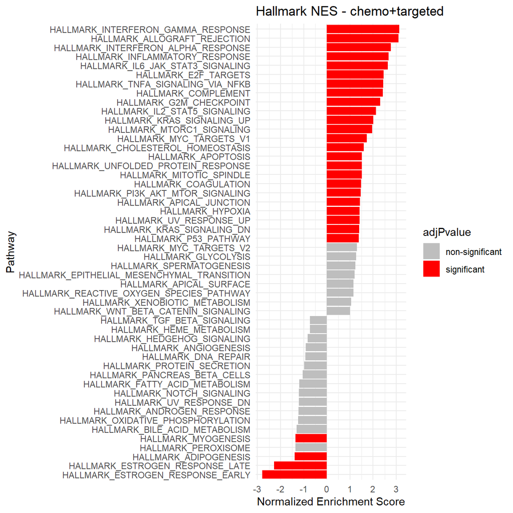

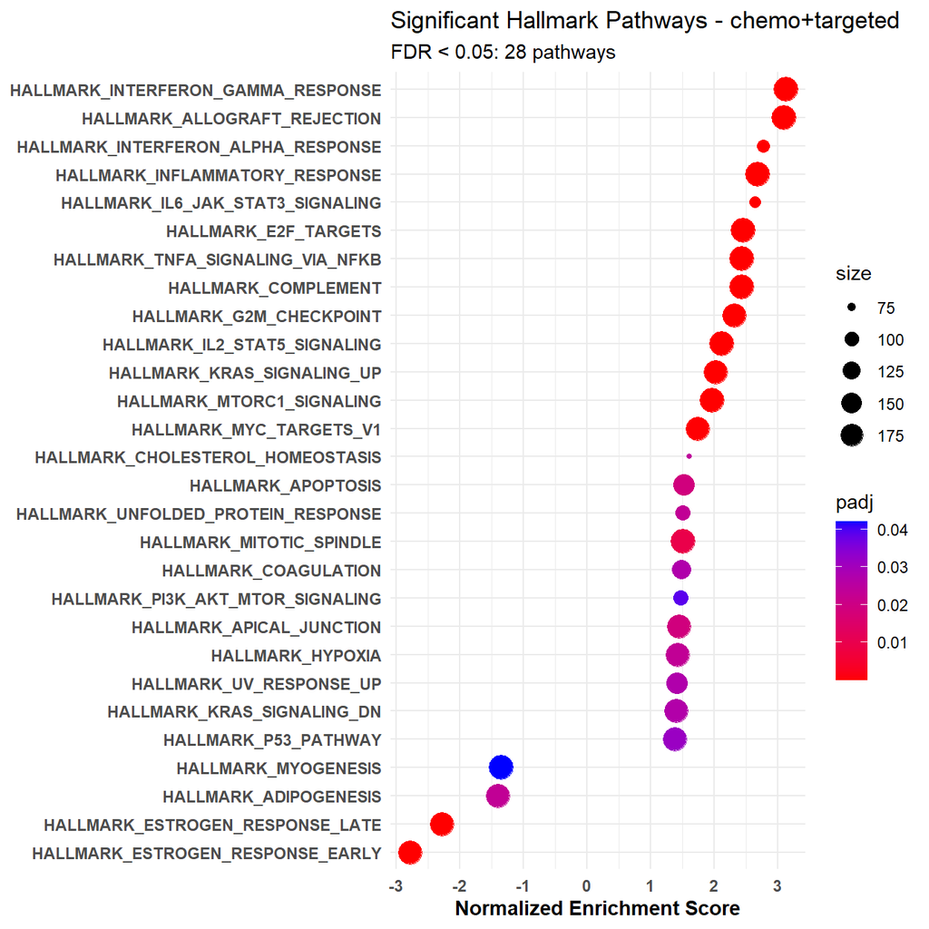

fgsea results - chemo+targeted

| pathway | pval | padj | log2err | ES | NES | size | leadingEdge | adjPvalue |
| --- | --- | --- | --- | --- | --- | --- | --- | --- |
| HALLMARK_INTERFERON_GAMMA_RESPONSE | 0.0000000 | 0.0000000 | 1.6965862 | 0.7740876 | 3.1307888 | 194 | CXCL9;IDO1;CD38;SLAMF7;CXCL10;CCL5;CXCL11;GZMA;TAP1;IL2RB;SOD2;GBP4;BATF2;IRF4;PFKP;ISG20;ICAM1;STAT1;PSMB9;CCL2;BANK1;XCL1;HLA-DRB1;SOCS1;IRF1;IL10RA;CCL7;IFI30;ZBP1;CD74;LCP2;VCAM1;HLA-A;HLA-DMA;PIM… | significant |
| HALLMARK_ALLOGRAFT_REJECTION | 0.0000000 | 0.0000000 | 1.6407417 | 0.7639199 | 3.0942692 | 195 | CXCL9;CXCL13;GZMB;CCL13;CCL5;CD2;CD79A;CD3D;LTB;GZMA;CCL4;TAP1;LCK;IL2RB;CD3G;IRF4;CXCR3;CD247;CDKN2A;CCR5;ICAM1;STAT1;MMP9;CCL19;HLA-DRA;CCL2;CD8A;FASLG;IFNG;ZAP70;HCLS1;SOCS1;SIT1;CD96;CCL7;HLA-E;CD… | significant |
| HALLMARK_INTERFERON_ALPHA_RESPONSE | 0.0000000 | 0.0000000 | 1.0864405 | 0.7463659 | 2.7645197 | 94 | LAMP3;CXCL10;CXCL11;TAP1;GBP4;BATF2;ISG20;PSMB9;IRF1;IFI30;CD74;HLA-C;GBP2;CASP1;USP18;OASL;IFIH1;EPSTI1;NCOA7;SAMD9L;C1S;IL15;RTP4;PSMB8;IFI44L;B2M;NMI;RSAD2;MX1;UBE2L6;PARP12;CD47;IFI44;SELL;IL7;IFI… | significant |
| HALLMARK_INFLAMMATORY_RESPONSE | 0.0000000 | 0.0000000 | 1.2210538 | 0.6608781 | 2.6774590 | 197 | CXCL9;LAMP3;CXCL10;MARCO;CCL5;CXCL11;CCR7;LCK;IL2RB;CCL17;CXCR6;ICAM1;CCL2;CD70;IRF1;IL10RA;CCL7;SLAMF1;CYBB;CD48;GPR183;LCP2;IL7R;LYN;IL18RAP;TLR2;ADM;EBI3;CD69;AQP9;CHST2;IL1B;CD14;FPR1;EDN1;PLAUR;P… | significant |
| HALLMARK_IL6_JAK_STAT3_SIGNALING | 0.0000000 | 0.0000000 | 0.9759947 | 0.7209242 | 2.6356004 | 87 | CXCL9;CXCL13;CD38;CXCL10;CXCL11;LTB;STAT1;CXCL1;SOCS1;IRF1;CCL7;IL2RG;PIM1;TNFRSF21;TLR2;EBI3;IL2RA;IL1B;CD14;TNF;IL15RA;CCR1;IL6;IFNGR1;BAK1;CD44;IL17RA;IL3RA;FAS;CSF2RA;PLA2G2A;IL7;MAP3K8;MYD88;TNFR… | significant |
| HALLMARK_E2F_TARGETS | 0.0000000 | 0.0000000 | 1.0175448 | 0.6059830 | 2.4545433 | 195 | CDKN2A;CCNE1;MELK;EZH2;TFRC;KIF2C;DLGAP5;CDC20;MYBL2;DEK;NASP;HMGB3;CDC25B;CHEK1;MCM2;MCM5;PTTG1;LBR;MCM6;DONSON;MCM3;HMGA1;MCM4;MTHFD2;CDCA8;TOP2A;SPAG5;ANP32E;STMN1;LMNB1;TUBB;AURKA;KIF4A;KPNA2;MMS2… | significant |
| HALLMARK_TNFA_SIGNALING_VIA_NFKB | 0.0000000 | 0.0000000 | 1.0073180 | 0.6004493 | 2.4326397 | 197 | CXCL10;CCL5;CXCL11;CCL4;TAP1;SOD2;ICAM1;CXCL1;KYNU;CCL2;BIRC3;IRF1;PLEK;GPR183;NFIL3;IL7R;CD83;TLR2;CD69;TNFAIP8;EGR2;IFIH1;IL1B;TRAF1;CEBPB;EDN1;PLAUR;PTGER4;NFKBIE;TNFAIP2;BCL2A1;RCAN1;TNF;TNFAIP3;I… | significant |
| HALLMARK_COMPLEMENT | 0.0000000 | 0.0000000 | 1.0175448 | 0.6004412 | 2.4317494 | 198 | S100A9;GZMB;CCL5;GZMA;GZMK;LCK;CXCL1;KYNU;C1QA;PSMB9;PLA2G7;LTF;IRF1;PLEK;CTSV;C1QC;CTSC;C2;CP;LCP2;PIM1;LYN;APOBEC3G;SPOCK2;SERPING1;CASP1;CTSS;CEBPB;C1S;PLAUR;CTSH;FCN1;FCER1G;CTSL;TNFAIP3;CASP5;FYN… | significant |
| HALLMARK_G2M_CHECKPOINT | 0.0000000 | 0.0000000 | 0.9214260 | 0.5726103 | 2.3071431 | 188 | SLC7A5;EZH2;CENPA;CDC45;KIF2C;TTK;CDC20;MYBL2;NASP;HMGB3;BUB1;ODC1;CDC25B;CHEK1;MCM2;MCM5;PTTG1;LBR;TPX2;MCM6;EXO1;MCM3;HMGA1;UCK2;NDC80;E2F3;CCNA2;TOP2A;E2F2;UBE2C;STMN1;LMNB1;AURKA;KIF4A;KPNA2;MARCK… | significant |
| HALLMARK_IL2_STAT5_SIGNALING | 0.0000000 | 0.0000000 | 0.7881868 | 0.5241944 | 2.1200985 | 194 | CXCL10;LTB;IL2RB;ICOS;GBP4;IRF4;CCNE1;SOCS1;CD79B;IL10RA;CD48;TNFRSF8;PIM1;NFIL3;EOMES;TNFRSF21;CD83;GLIPR2;PNP;IL2RA;FGL2;TNFRSF4;BATF3;TRAF1;ODC1;PLIN2;IRF8;CST7;ITGA6;CTLA4;TNFSF10;COCH;UCK2;TNFRSF… | significant |
| HALLMARK_KRAS_SIGNALING_UP | 0.0000000 | 0.0000001 | 0.7195128 | 0.4978637 | 2.0136042 | 191 | CXCL10;SLPI;MYCN;MMP9;ST6GAL1;ADAMDEC1;LCP1;BIRC3;HSD11B1;IL10RA;KCNN4;IL2RG;TMEM176B;IL7R;TMEM176A;LAPTM5;GPRC5B;CTSS;CXCR4;IL1B;TRAF1;CD37;PLAUR;GALNT3;MPZL2;FCER1G;CLEC4A;ADAM8;GLRX;TNFAIP3;IRF8;PS… | significant |
| HALLMARK_MTORC1_SIGNALING | 0.0000001 | 0.0000003 | 0.7049757 | 0.4855135 | 1.9636541 | 194 | PSAT1;PHGDH;DAPP1;CORO1A;IFI30;SLC7A5;CTSC;PDK1;TFRC;NFIL3;SLA;PNP;FGL2;FADS2;GMPS;CXCR4;BUB1;CFP;GLRX;MCM2;DDIT4;ASNS;ITGB2;MCM4;MTHFD2;LGMN;SCD;IFRD1;VLDLR;TES;AURKA;ENO1;NAMPT;ACTR3;DHCR7;AK4;RRM2;… | significant |
| HALLMARK_MYC_TARGETS_V1 | 0.0000535 | 0.0001783 | 0.5573322 | 0.4301847 | 1.7371455 | 193 | PSMD3;CDC45;CDC20;DEK;PSMB3;ODC1;MCM2;MCM5;MCM6;MCM4;CCNA2;HDAC2;IFRD1;SRPK1;RFC4;ILF2;KPNA2;CTPS1;TFDP1;TYMS;MCM7;PRDX4;SYNCRIP;PSMB2;CUL1;RANBP1;FBL;YWHAQ;PPM1G;MAD2L1;PCNA;SERBP1;HDGF;EIF4A1;MRPL9;… | significant |
| HALLMARK_CHOLESTEROL_HOMEOSTASIS | 0.0106657 | 0.0242403 | 0.3807304 | 0.4555703 | 1.6012032 | 72 | CBS;NFIL3;FADS2;S100A11;PLAUR;GLDC;LGMN;PNRC1;SCD;CXCL16;SREBF2;DHCR7;FABP5;ACAT2;PLSCR1;FDPS;IDI1;MVD;LPL;LGALS3;FBXO6;STARD4;HMGCS1;ATF3;SQLE | significant |
| HALLMARK_APOPTOSIS | 0.0068515 | 0.0190319 | 0.4070179 | 0.3842947 | 1.5207296 | 159 | CD38;CD2;TAP1;SOD2;ISG20;FASLG;BIRC3;IRF1;ERBB2;CD69;CASP1;IL1B;CD14;TNF;CDC25B;PRF1;CASP4;IL18;TNFSF10;CCND2;GCH1;TOP2A;IL6;IFNGR1;BID;CFLAR;CD44;IGF2R;BTG3;FAS;SAT1;PLCB2;TSPO;SATB1;ANXA1;GADD45A;GS… | significant |
| HALLMARK_UNFOLDED_PROTEIN_RESPONSE | 0.0096930 | 0.0233844 | 0.3807304 | 0.3984386 | 1.5089829 | 106 | PSAT1;CCL2;SLC7A5;SPCS3;CEBPB;DDIT4;HERPUD1;ASNS;MTHFD2;VEGFA;NABP1;PDIA6;ATF4;PDIA5;CKS1B;EDEM1;DNAJB9;CHAC1;EIF4G1;HSP90B1;EIF4A1;TUBB2A;HYOU1;TATDN2;GEMIN4;KDELR3;CALR;ATF3;PREB | significant |
| HALLMARK_MITOTIC_SPINDLE | 0.0030465 | 0.0095203 | 0.4317077 | 0.3721431 | 1.5076880 | 197 | KIF2C;DLGAP5;TTK;BUB1;CDC42EP1;TPX2;NDC80;TOP2A;ANLN;PIF1;LMNB1;AURKA;KIF4A;MARCKS;ARHGAP4;CDK1;KIF11;CCNB2;BIRC5;TUBA4A;BIN1;INCENP;CENPF;MID1;TIAM1;CENPE;FBXO5;GSN;SUN2;PLK1;NCK1;EPB41L2;ARHGAP10;SM… | significant |
| HALLMARK_COAGULATION | 0.0137158 | 0.0274316 | 0.3807304 | 0.3824835 | 1.4854347 | 137 | MMP1;KLK8;MMP9;C1QA;MMP7;MMP3;PLEK;CTSV;C2;SERPING1;C1S;CTSH;SH2B2;FYN;C3;DUSP6;APOC1;PLAU;LGMN;C1R;PREP;CFH;CTSB;APOC2;FGG;ANXA1;GSN;MAFF;S100A1 | significant |
| HALLMARK_PI3K_AKT_MTOR_SIGNALING | 0.0211370 | 0.0391425 | 0.3524879 | 0.3896067 | 1.4725016 | 104 | LCK;DAPP1;FASLG;PDK1;IL2RG;SLA;PRKCB;CXCR4;PFN1;MAPK1;CDK1;ACTR3;RPS6KA3;E2F1;MYD88;NFKBIB;TIAM1;STAT2;NCK1;HSP90B1;ACTR2;CALR;MAP2K3;MAP3K7;CFL1;NOD1;TRAF2;PAK4 | significant |
| HALLMARK_APICAL_JUNCTION | 0.0064903 | 0.0190319 | 0.4070179 | 0.3563929 | 1.4407352 | 190 | GRB7;CDH3;ICAM1;MMP9;ACTG2;SYK;VCAM1;CD274;MDK;TRAF1;RAC2;MPZL2;NRTN;MSN;CALB2;ICAM2;PTPRC;ICAM4;PFN1;CX3CL1;CNN2;RSU1;SIRPA;LAMC2;ITGB4;TGFBI;SLC30A3;MVD;EPB41L2;ITGA9;ZYX;CD209;VASP;CDH1;MPZL1;CLDN4… | significant |
| HALLMARK_HYPOXIA | 0.0098215 | 0.0233844 | 0.3807304 | 0.3509076 | 1.4192421 | 191 | PFKP;ISG20;TMEM45A;CP;PDK1;PIM1;PLAC8;NFIL3;CSRP2;ADM;CHST2;LDHC;CXCR4;PLAUR;GLRX;PLIN2;TNFAIP3;DDIT4;RRAGD;PNRC1;IL6;VEGFA;EDN2;VLDLR;TES;SLC2A5;S100A4;ENO1;ZFP36;NDRG1;ETS1;AK4;ADORA2B;MT2A;PGM1;TPS… | significant |
| HALLMARK_UV_RESPONSE_UP | 0.0133660 | 0.0274316 | 0.3807304 | 0.3583953 | 1.4152078 | 154 | TAP1;SOD2;ICAM1;STARD3;HLA-F;GAL;CCNE1;IRF1;CTSV;TFRC;LYN;GGH;ASNS;CHRNA5;GCH1;FMO1;IL6;RFC4;BID;BAK1;LHX2;BTG3;MGAT1;CCK;AMD1;FEN1;TUBA4A;ARRB2;CXCL2;RASGRP1;RAB27A;AGO2;PARP2;CASP3;CCND3;NFKBIA;RPN1… | significant |
| HALLMARK_KRAS_SIGNALING_DN | 0.0124799 | 0.0271301 | 0.3807304 | 0.3461697 | 1.4000796 | 191 | CALML5;KLK8;PNMT;TCL1A;PDCD1;IFNG;SLC6A14;SOX10;LGALS7;KRT5;CHST2;KRT15;TCF7L1;EDN1;KLK7;IFI44L;KRT4;PRODH;GPR19;CAMK1D;RSAD2;MX1;RYR1;AKR1B10;SGK1;EDN2;TFF2;TGM1;SCGB1A1;GTF3C5;SNN;YPEL1;TFAP2B;SLC30… | significant |
| HALLMARK_P53_PATHWAY | 0.0164747 | 0.0316822 | 0.3524879 | 0.3409447 | 1.3789472 | 191 | KLK8;TAP1;KRT17;CDKN2A;SOCS1;CLCA2;IFI30;PERP;TM4SF1;SDC1;CASP1;DDIT4;RHBDF2;TCN2;CD82;CCND2;ST14;LDHB;ADA;BAK1;UPP1;S100A4;FAS;NDRG1;SAT1;TPD52L1;STEAP3;RGS16;GM2A;SERPINB5;ITGB4;DRAM1;GADD45A;PCNA;S… | significant |
| HALLMARK_MYC_TARGETS_V2 | 0.1257485 | 0.1726879 | 0.1766943 | 0.3837853 | 1.3012264 | 57 | MCM5;MCM4;DUSP2;BYSL;PLK1;PUS1;PPAN;PPRC1;NDUFAF4;RCL1;NIP7;NOP2;MYBBP1A;NOLC1;PES1;SLC19A1;SRM;LAS1L;PLK4;CDK4;TCOF1;NOP56;SUPV3L1;MAP3K6;NOP16 | non-significant |
| HALLMARK_GLYCOLYSIS | 0.0581162 | 0.0968604 | 0.2663507 | 0.3113954 | 1.2615767 | 197 | B3GNT3;PFKP;ISG20;CENPA;SDC1;CHST2;LDHC;CXCR4;SPAG4;NASP;MED24;GLRX;DDIT4;KIF20A;RRAGD;DSC2;B3GAT1;SLC16A3;VEGFA;VLDLR;CHST6;STMN1;CD44;AURKA;ENO1;CDK1;AK4;ADORA2B;SOX9;MET;HMMR;ME1;SAP30;TGFBI;UGP2;C… | non-significant |
| HALLMARK_SPERMATOGENESIS | 0.1021611 | 0.1502369 | 0.1957890 | 0.3164719 | 1.2325950 | 132 | IL12RB2;ART3;EZH2;KIF2C;DPEP3;TTK;LDHC;POMC;BUB1;CRISP2;GFI1;LPIN1;RFC4;SLC2A5;RPL39L;AURKA;CDK1;CCNB2;CDKN3;PSMG1;AGFG1;PARP2;TKTL1;NCAPH;YBX2;CHRM4 | non-significant |
| HALLMARK_EPITHELIAL_MESENCHYMAL_TRANSITION | 0.0858283 | 0.1300429 | 0.2165428 | 0.2974432 | 1.2047982 | 195 | MMP1;DKK1;IL32;CXCL1;MMP3;SFRP1;VCAM1;SDC1;PLAUR;IL15;TNFAIP3;WIPF1;FBLN2;IL6;VEGFA;EMP3;CD44;TPM4;CAPG;COL4A2;FBLN5;FAS;GAS1;SAT1;MCM7;LAMC2;SERPINE2;GADD45A;COLGALT1;TGFBI;NNMT;PTX3;TGM2;ID2;GPX7;PL… | non-significant |
| HALLMARK_APICAL_SURFACE | 0.2484472 | 0.3105590 | 0.1238422 | 0.3649624 | 1.1528852 | 43 | IL2RB;GHRL;MAL;IL2RG;LYN;ATP6V0A4;PLAUR;CX3CL1;RHCG;GAS1;PCSK9;AKAP7;APP | non-significant |
| HALLMARK_REACTIVE_OXYGEN_SPECIES_PATHWAY | 0.2800789 | 0.3415596 | 0.1123785 | 0.3516431 | 1.1449500 | 47 | SOD2;PFKP;GLRX;PRDX4;FTL;PDLIM1;LSP1;JUNB;MGST1;FES;NDUFA6;GPX3 | non-significant |
| HALLMARK_XENOBIOTIC_METABOLISM | 0.3453094 | 0.4110826 | 0.0999277 | 0.2586756 | 1.0462104 | 194 | HSD17B2;PTGDS;TDO2;KYNU;HSD11B1;TMEM176B;AQP9;ALDH2;IRF8;DDC;PAPSS2;NDRG2;GCH1;FMO1;PSMB10;XDH;ABCC3;UPP1;APOE;VNN1;FAS;CES1;COMT;MT2A;SMOX;CYP27A1;GSTA3;SLC35B1;MAN1A1;SHMT2;ID2;PGD;ABCC2;IDH1;NPC1;P… | non-significant |
| HALLMARK_WNT_BETA_CATENIN_SIGNALING | 0.4470339 | 0.5079931 | 0.0883594 | 0.3215755 | 1.0047026 | 42 | WNT6;DKK1;CCND2;HDAC2;CUL1;WNT5B;SKP2;TCF7;NOTCH1;NCSTN;ADAM17;PPARD | non-significant |
| HALLMARK_TGF_BETA_SIGNALING | 0.9198397 | 0.9386119 | 0.0495902 | -0.2160782 | -0.7219481 | 54 | BCAR3;SMAD3;BMPR2;PPM1A;THBS1;NCOR2;TRIM33;TJP1;ARID4B;XIAP;SLC20A1;KLF10;APC;PMEPA1;SMAD7;CDK9;RHOA;CTNNB1;ACVR1;SMAD1;FURIN;RAB31;BMP2;FNTA;LTBP2 | non-significant |
| HALLMARK_HEME_METABOLISM | 0.9879760 | 0.9879760 | 0.0463228 | -0.1813776 | -0.7345439 | 189 | SELENBP1;CA2;HEBP1;TRIM58;TMEM9B;VEZF1;BLVRB;GDE1;HAGH;ALDH6A1;DMTN;SLC22A4;TRAK2;BLVRA;PIGQ;BTRC;NUDT4;ALAD;SLC30A1;RBM5;ERMAP;MBOAT2;ADD1;PRDX2;UROD;KLF3;RNF123;FECH;RAP1GAP;EPOR;EZH1;GCLM;BNIP3L;FT… | non-significant |
| HALLMARK_HEDGEHOG_SIGNALING | 0.7603143 | 0.7919941 | 0.0574877 | -0.2680191 | -0.8209731 | 35 | CELSR1;HEY2;GLI1;HEY1;NRCAM;RASA1;TLE3;RTN1 | non-significant |
| HALLMARK_ANGIOGENESIS | 0.5980392 | 0.6500426 | 0.0689567 | -0.2965863 | -0.9143378 | 36 | SERPINA5;POSTN;FGFR1;JAG1;PTK2;PDGFA;MSX1;PF4;JAG2;KCNJ8 | non-significant |
| HALLMARK_DNA_REPAIR | 0.6167665 | 0.6561345 | 0.0683111 | -0.2344357 | -0.9271722 | 145 | NME3;BRF2;CCNO;NME4;VPS28;MPC2;VPS37D;DCTN4;ADCY6;POLD4;TAF9;NT5C;IMPDH2;DUT;TSG101;GPX4;RRM2B;CANT1;MPG;TK2;COX17;SURF1;GMPR2;RAE1;EIF1B;TARBP2;RPA3;SRSF6;CETN2;GTF2H5;NUDT9;GTF2F1;AAAS;POLR2J;ARL6IP… | non-significant |
| HALLMARK_PROTEIN_SECRETION | 0.4821429 | 0.5357143 | 0.0806388 | -0.2643380 | -0.9842325 | 94 | KRT18;TOM1L1;ATP6V1B1;SCAMP1;ICA1;AP2B1;ARFGEF1;SSPN;COG2;TSG101;RAB22A;ARFIP1;DST;TPD52;VPS4B;STX16;ATP6V1H;SOD1 | non-significant |
| HALLMARK_PANCREAS_BETA_CELLS | 0.3822394 | 0.4444644 | 0.0919686 | -0.3248738 | -1.0373948 | 40 | ABCC8;SYT13;SRP14;CHGA;SPCS1;PCSK1;SRP9;STXBP1;SST | non-significant |
| HALLMARK_FATTY_ACID_METABOLISM | 0.1277890 | 0.1726879 | 0.1766943 | -0.3006897 | -1.1896123 | 152 | BMPR1B;SLC22A5;REEP6;CA2;ECI1;UGDH;MAOA;ENO2;LTC4S;ELOVL5;HPGD;AOC3;HMGCL;DHCR24;CD36;HSD17B4;CRYZ;PCBD1;NTHL1;PDHB;ACOT2;ACADS;BLVRA;ALDH3A2;FASN;CIDEA;ECI2;ALAD;EPHX1;ALDOA;GLUL;RETSAT;INMT;ADIPOR2;… | non-significant |
| HALLMARK_NOTCH_SIGNALING | 0.2163743 | 0.2774029 | 0.1294429 | -0.4012749 | -1.2091808 | 32 | CCND1;SKP1;HEYL;ARRB1;KAT2A;JAG1;PSEN2 | non-significant |
| HALLMARK_UV_RESPONSE_DN | 0.1314741 | 0.1729922 | 0.1723243 | -0.3089245 | -1.2132012 | 138 | IGF1R;IRS1;IGFBP5;SRI;APBB2;GJA1;SLC22A18;BHLHE40;INPP4B;DDAH1;AMPH;ICA1;MAGI2;CDKN1B;CDON;MGMT;PRKCE;CAP2;SMAD3;MMP16;AGGF1;PDGFRB;ITGB3;SYNJ2;CAV1;RUNX1;COL1A1;MIOS;CDC42BPA;PTEN;COL1A2 | non-significant |
| HALLMARK_ANDROGEN_RESPONSE | 0.1166008 | 0.1665726 | 0.1830239 | -0.3304711 | -1.2324789 | 96 | CCND1;SPDEF;BMPR1B;STK39;SORD;KRT19;ABHD2;GPD1L;ELOVL5;INPP4B;HPGD;DHCR24;APPBP2;KRT8;ACSL3;NKX3-1;AKAP12 | non-significant |
| HALLMARK_OXIDATIVE_PHOSPHORYLATION | 0.0747475 | 0.1167929 | 0.2343926 | -0.3101699 | -1.2492321 | 184 | ACADSB;COX6C;MRPS30;ECI1;NDUFC2;NDUFA7;PDK4;CYB5A;MAOB;ALDH6A1;GLUD1;UQCRQ;NDUFA2;COX7C;TIMM13;PDHB;RHOT2;GPX4;PRDX3;CYC1;ETFB;COX17;PDHX;RETSAT;NDUFS8;SURF1;ATP6V1H;ATP1B1;UQCRC2;UQCR11;NDUFS4;CPT1A;… | non-significant |
| HALLMARK_BILE_ACID_METABOLISM | 0.0638723 | 0.1030198 | 0.2529611 | -0.3450906 | -1.3078688 | 112 | AR;ABCA3;SERPINA6;SLC27A2;NUDT12;FDXR;EPHX2;SULT2B1;BCAR3;SLC22A18;PFKM;PEX11A;ISOC1;DHCR24;PEX11G;HSD17B4;CROT;LIPE;PEX12;DIO1;SLC27A5;EFHC1;PEX19;NEDD4;GNMT;RETSAT;GNPAT;SCP2;ABCA9;SOD1;HSD3B1 | non-significant |
| HALLMARK_MYOGENESIS | 0.0236302 | 0.0421967 | 0.3524879 | -0.3314385 | -1.3495495 | 196 | TNNT1;STC2;SPDEF;PPP1R3C;AGL;CACNA1H;CACNG1;MYH11;PVALB;OCEL1;ADCY9;CLU;PGAM2;NQO1;HSPB8;CAMK2B;BHLHE40;ERBB3;PFKM;CD36;BAG1;SGCD;SSPN;ITGB5;FKBP1B;COX7A1;SH2B1;LAMA2;REEP1;TNNT3;CHRNG;SGCA;TNNC2;PSEN… | significant |
| HALLMARK_PEROXISOME | 0.0546984 | 0.0943077 | 0.3217759 | -0.3598859 | -1.3546393 | 104 | ABCC8;SEMA3C;SERPINA6;SLC27A2;CRABP2;EPHX2;SULT2B1;ELOVL5;ABCC5;ALB;PEX11A;ISOC1;HMGCL;DHCR24;HSD17B4;PEX2;CDK7;DIO1;ECI2;HSD11B2;RETSAT;FIS1;GNPAT;VPS4B;SCP2;CLN8;SOD1;PEX11B;HRAS | non-significant |
| HALLMARK_ADIPOGENESIS | 0.0089114 | 0.0233844 | 0.3807304 | -0.3440095 | -1.3964599 | 192 | QDPR;CYP4B1;REEP6;EPHX2;REEP5;CMBL;SNCG;LTC4S;HSPB8;SPARCL1;SULT1A1;DGAT1;FAH;CD36;ADCY6;PTGER3;UQCRQ;DBT;SSPN;LIPE;LPCAT3;ACADS;OMD;CD151;GPX4;PRDX3;CIDEA;RAB34;FABP4;RMDN3;PDCD4;ALDOA;TOB1;CYC1;COQ5… | significant |
| HALLMARK_ESTROGEN_RESPONSE_LATE | 0.0000000 | 0.0000000 | 0.9101197 | -0.5617047 | -2.2801642 | 192 | TFF1;AGR2;SCUBE2;CA12;TFF3;NPY1R;DNAJC12;CCND1;PDZK1;MAPT;ANXA9;SERPINA3;SERPINA5;PGR;COX6C;ABCA3;DHRS2;CACNA2D2;SLC22A5;TSPAN13;TPSAB1;MYB;SLC27A2;RET;BCL2;PRSS23;CHST8;IL6ST;NRIP1;CA2;ACOX2;TPBG;SCN… | significant |
| HALLMARK_ESTROGEN_RESPONSE_EARLY | 0.0000000 | 0.0000000 | 1.3499257 | -0.6883031 | -2.7855347 | 190 | TFF1;GFRA1;CA12;TFF3;NPY1R;SLC39A6;CCND1;PDZK1;THSD4;MAPT;ANXA9;SLC7A2;SYBU;STC2;ELOVL2;MLPH;PGR;AR;MSMB;ABCA3;DHRS2;SLC22A5;SLC19A2;IGF1R;ABAT;MYB;KRT18;MAST4;SLC27A2;RET;KCNK15;BCL2;PRSS23;GREB1;IL6… | significant |

#### KEGG_MEDICUS Pathway Analysis

```r
fgsea_kegg_result_list <- list()
fgsea_kegg_barplot_list <- list()
fgsea_kegg_dotplot_list <- list()

for (treatment in sub_treat) {
  message("Running KEGG GSEA for: ", treatment)

  top_treat <- top_table_list[[treatment]]
  ranks <- setNames(top_treat$logFC, top_treat$Gene)
  ranks <- sort(ranks, decreasing = TRUE)

  fgseaRes_kegg <- fgsea(pathways = pathwaysKEGG_MED, stats = ranks, nproc = 1)
  fgseaRes_kegg <- na.omit(fgseaRes_kegg)

  fgseaResTidy_kegg <- fgseaRes_kegg %>%
    as_tibble() %>%
    arrange(desc(NES)) %>%
    mutate(
      leadingEdge = sapply(leadingEdge, paste, collapse = ";"),
      adjPvalue = ifelse(padj <= 0.05, "significant", "non-significant")
    )

  fgsea_kegg_result_list[[treatment]] <- fgseaResTidy_kegg

  write.table(fgseaResTidy_kegg,
    file.path(output_dir, "pathway_analysis", paste0(gsub("\\+", "_", treatment), "_fgseaRes_kegg.txt")),
    sep = "\t", row.names = FALSE, quote = FALSE)

  sig_fgsea <- fgseaResTidy_kegg %>% filter(padj <= p_cutoff)

  # Barplot (significant only)
  if (nrow(sig_fgsea) > 0) {
    p_bar <- ggplot(sig_fgsea, aes(reorder(pathway, NES), NES, fill = adjPvalue)) +
      geom_col() +
      scale_fill_manual(values = c("significant" = "red")) +
      coord_flip() +
      theme_minimal() +
      labs(x = "Pathway", y = "NES",
           title = paste("KEGG NES -", treatment),
           subtitle = paste0("FDR < ", p_cutoff, ": ", nrow(sig_fgsea), " pathways"))

    fgsea_kegg_barplot_list[[treatment]] <- p_bar
    print(p_bar)

    # Dot plot (significant only)
    p_dot <- ggplot(sig_fgsea, aes(x = NES, y = reorder(pathway, NES))) +
      geom_point(aes(color = padj, size = size)) +
      scale_color_gradientn(colours = c("red", "blue")) +
      theme_minimal() +
      labs(x = "Normalized Enrichment Score", y = NULL,
           title = paste("KEGG Dot Plot -", treatment),
           subtitle = paste0("FDR < ", p_cutoff, ": ", nrow(sig_fgsea), " pathways")) +
      theme(axis.title = element_text(face = 'bold'),
            axis.text = element_text(face = 'bold'))

    fgsea_kegg_dotplot_list[[treatment]] <- p_dot
    print(p_dot)
  } else {
    cat("No significant KEGG pathways for", treatment, "\n")
  }

  # Table
  print(
    kable(fgseaResTidy_kegg, caption = paste("KEGG GSEA results -", treatment)) %>%
      kable_styling(bootstrap_options = c("striped", "hover", "condensed"), full_width = FALSE) %>%
      scroll_box(height = "400px")
  )
}
```

[output not shown]

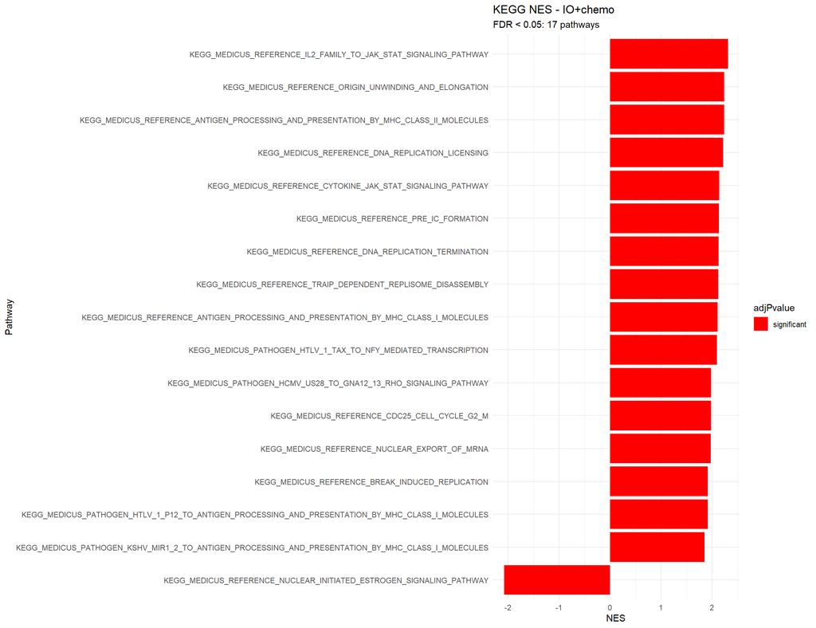

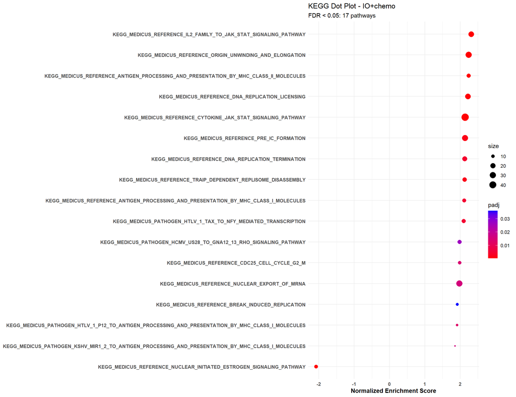

KEGG GSEA results - IO+chemo

| pathway | pval | padj | log2err | ES | NES | size | leadingEdge | adjPvalue |
| --- | --- | --- | --- | --- | --- | --- | --- | --- |
| KEGG_MEDICUS_REFERENCE_IL2_FAMILY_TO_JAK_STAT_SIGNALING_PATHWAY | 0.0000018 | 0.0004238 | 0.6435518 | 0.8043145 | 2.3119087 | 23 | IL21R;STAT1;IL2RB;IL7R;IL15;IL2RG;IL2RA;STAT5A;IL15RA;STAT3;IL21;JAK3;IL7 | significant |
| KEGG_MEDICUS_REFERENCE_ORIGIN_UNWINDING_AND_ELONGATION | 0.0000036 | 0.0005137 | 0.6272567 | 0.7357555 | 2.2390730 | 30 | MCM10;MCM2;MCM4;GINS4;RFC2;MCM5;MCM3;CDC45;RFC4;MCM6;RPA2;RFC5;MCM7;PCNA;PRIM2;GINS3;POLE3;POLA2;WDHD1;RPA1;GINS1;RFC3 | significant |
| KEGG_MEDICUS_REFERENCE_ANTIGEN_PROCESSING_AND_PRESENTATION_BY_MHC_CLASS_II_MOLECULES | 0.0000017 | 0.0004238 | 0.6435518 | 0.8918513 | 2.2383303 | 13 | HLA-DOB;HLA-DQA1;CD74;HLA-DPB1;HLA-DPA1;HLA-DMA;HLA-DRB5;HLA-DRB1;HLA-DQA2;HLA-DQB1;HLA-DRA | significant |
| KEGG_MEDICUS_REFERENCE_DNA_REPLICATION_LICENSING | 0.0000081 | 0.0008356 | 0.5933255 | 0.7598085 | 2.2167120 | 24 | CCNE1;MCM2;CCNA2;MCM4;MCM5;MCM3;CDT1;ORC6;CDC45;CDC7;MCM6;TICRR;MCM7;ORC1;CCNA1;MTBP;ORC3;DBF4 | significant |
| KEGG_MEDICUS_REFERENCE_CYTOKINE_JAK_STAT_SIGNALING_PATHWAY | 0.0000041 | 0.0005137 | 0.6105269 | 0.6511423 | 2.1421902 | 44 | IL12RB2;STAT1;IFNG;IL2RB;IL7R;IL15;PIM1;IL2RG;IL2RA;STAT5A;IFNAR2;IL15RA;JAK2;IL23A;STAT3;IL13;IL3RA;STAT4;IL6;JAK3;IFNGR1;IL7;IL12A | significant |
| KEGG_MEDICUS_REFERENCE_PRE_IC_FORMATION | 0.0000203 | 0.0017988 | 0.5756103 | 0.7145344 | 2.1364587 | 27 | MCM2;MCM4;GINS4;MCM5;MCM3;CDT1;ORC6;CDC45;MCM6;TICRR;MCM7;ORC1;GINS3;POLE3;MTBP;ORC3;GINS1;TOPBP1 | significant |
| KEGG_MEDICUS_REFERENCE_DNA_REPLICATION_TERMINATION | 0.0000631 | 0.0043377 | 0.5384341 | 0.7827012 | 2.1297720 | 18 | MCM2;MCM4;GINS4;MCM5;MCM3;CDC45;PIF1;MCM6;VCP;MCM7;GINS3 | significant |
| KEGG_MEDICUS_REFERENCE_TRAIP_DEPENDENT_REPLISOME_DISASSEMBLY | 0.0000273 | 0.0021143 | 0.5756103 | 0.8192209 | 2.1227911 | 15 | MCM2;MCM4;GINS4;MCM5;MCM3;CDC45;MCM6;VCP;MCM7;GINS3;TRAIP | significant |
| KEGG_MEDICUS_REFERENCE_ANTIGEN_PROCESSING_AND_PRESENTATION_BY_MHC_CLASS_I_MOLECULES | 0.0000840 | 0.0048611 | 0.5384341 | 0.8545582 | 2.1109943 | 12 | TAP1;HLA-F;HLA-E;HLA-C;HLA-A;B2M;HLA-G;TAPBP;TAP2;HLA-B | significant |
| KEGG_MEDICUS_PATHOGEN_HTLV_1_TAX_TO_NFY_MEDIATED_TRANSCRIPTION | 0.0000864 | 0.0048611 | 0.5384341 | 0.8363963 | 2.0991516 | 13 | HLA-DOB;HLA-DQA1;HLA-DPB1;HLA-DPA1;HLA-DMA;HLA-DRB5;HLA-DRB1;HLA-DQA2;HLA-DQB1;HLA-DRA | significant |
| KEGG_MEDICUS_PATHOGEN_HCMV_US28_TO_GNA12_13_RHO_SIGNALING_PATHWAY | 0.0006910 | 0.0267323 | 0.4772708 | 0.7903832 | 1.9836699 | 13 | CCL5;CX3CL1;CCL2;CCL4;CCL3 | significant |
| KEGG_MEDICUS_REFERENCE_CDC25_CELL_CYCLE_G2_M | 0.0003024 | 0.0144005 | 0.4984931 | 0.8427229 | 1.9823338 | 10 | CHEK1;CHEK2;CDC25B;CDK1;CCNB2;ATM;ATR | significant |
| KEGG_MEDICUS_REFERENCE_NUCLEAR_EXPORT_OF_MRNA | 0.0003613 | 0.0159749 | 0.4984931 | 0.6551020 | 1.9756477 | 29 | NUP205;SEH1L;NXT2;NUP210;NUP93;NUP155;NUP88;NDC1;NXT1;NUP62;NUP214;NUP160;DDX19B;NXF1;NUP37 | significant |
| KEGG_MEDICUS_REFERENCE_BREAK_INDUCED_REPLICATION | 0.0009878 | 0.0359677 | 0.4550599 | 0.8639958 | 1.9193012 | 8 | MCM2;MCM4;MCM5;MCM3;PIF1;MCM6;MCM7 | significant |
| KEGG_MEDICUS_PATHOGEN_HTLV_1_P12_TO_ANTIGEN_PROCESSING_AND_PRESENTATION_BY_MHC_CLASS_I_MOLECULES | 0.0002460 | 0.0126882 | 0.4984931 | 0.9087229 | 1.9154360 | 7 | HLA-F;HLA-E;HLA-C;HLA-A;B2M;HLA-G;HLA-B | significant |
| KEGG_MEDICUS_REFERENCE_ORGANIZATION_OF_THE_OUTER_KINETOCHORE | 0.0026837 | 0.0830605 | 0.4317077 | 0.7176124 | 1.8993072 | 16 | NDC80;CDCA8;CENPW;NUF2;AURKB;INCENP;BIRC5;PMF1 | non-significant |
| KEGG_MEDICUS_REFERENCE_TCR_PLCG_ITPR_SIGNALING_PATHWAY | 0.0024667 | 0.0803636 | 0.4317077 | 0.6909091 | 1.8890586 | 19 | LCK;CD3D;PLCG2;ZAP70;CD247;CD3G;VAV1;LCP2;LAT | non-significant |
| KEGG_MEDICUS_REFERENCE_ATR_P21_CELL_CYCLE_G2_M | 0.0033025 | 0.0916009 | 0.4317077 | 0.8135528 | 1.8568206 | 9 | CHEK1;CDK1;CCNB2;ATM;ATR | non-significant |
| KEGG_MEDICUS_PATHOGEN_KSHV_MIR1_2_TO_ANTIGEN_PROCESSING_AND_PRESENTATION_BY_MHC_CLASS_I_MOLECULES | 0.0004036 | 0.0166570 | 0.4984931 | 0.9086711 | 1.8518898 | 6 | HLA-F;HLA-E;HLA-C;HLA-A;HLA-G;HLA-B | significant |
| KEGG_MEDICUS_REFERENCE_RECRUITMENT_AND_FORMATION_OF_THE_MCC | 0.0035128 | 0.0916009 | 0.4317077 | 0.8105788 | 1.8500330 | 9 | CDC20;NDC80;TTK;BUB1;BUB1B;AURKB;MAD2L1 | non-significant |
| KEGG_MEDICUS_PATHOGEN_EBV_EBNA3C_TO_P27_CELL_CYCLE_G1_S_N00264 | 0.0036727 | 0.0916009 | 0.4317077 | 0.7653155 | 1.8382039 | 11 | CCNE1;CCNA2;E2F3;SKP2;E2F2;E2F1;CCNA1 | non-significant |
| KEGG_MEDICUS_REFERENCE_FANCONI_ANEMIA_PATHWAY | 0.0052360 | 0.1080368 | 0.4070179 | 0.7153796 | 1.8356187 | 14 | FANCE;FANCA;FANCG;UBE2T;FANCC;ATR;FANCL;TOPBP1;FANCB | non-significant |
| KEGG_MEDICUS_REFERENCE_MDM2_P21_CELL_CYCLE_G1_S_N00536 | 0.0038406 | 0.0916009 | 0.4317077 | 0.7634484 | 1.8337193 | 11 | CDKN2A;CCNE1;E2F3;E2F2;E2F1 | non-significant |
| KEGG_MEDICUS_REFERENCE_KINETOCHORE_MICROTUBULE_ATTACHMENT | 0.0047036 | 0.1003972 | 0.4070179 | 0.6631685 | 1.8132112 | 19 | TUBB2B;CENPF;TUBB;TUBB3;CENPE;TUBB6;BUB1B;TUBB2A;TUBA1C;TUBA1A;TUBA4A | non-significant |
| KEGG_MEDICUS_REFERENCE_CENPE_INTERACTION_WITH_NDC80_COMPLEX | 0.0056945 | 0.1101537 | 0.4070179 | 0.7485380 | 1.7979062 | 11 | NDC80;NUF2;CENPE;AURKB;AURKA;SPAG5;PPP1CA;PPP1CC;PPP1CB;SPC25 | non-significant |
| KEGG_MEDICUS_PATHOGEN_EBV_EBNA3C_TO_P27_CELL_CYCLE_G1_S_N00482 | 0.0085823 | 0.1257051 | 0.3807304 | 0.7856265 | 1.7930828 | 9 | CCNE1;CCNA2;E2F3;E2F2;E2F1;CCNA1 | non-significant |
| KEGG_MEDICUS_PATHOGEN_SARS_COV_2_S_TO_CLASSICAL_PATHWAY_OF_COMPLEMENT_CASCADE | 0.0021691 | 0.0745919 | 0.4317077 | 0.9055980 | 1.7909206 | 5 | C1QA;C1QB;C1QC;C1S;C1R | non-significant |
| KEGG_MEDICUS_PATHOGEN_HTLV_1_TAX_TO_P21_CELL_CYCLE_G1_S_N00497 | 0.0094320 | 0.1326917 | 0.3807304 | 0.7832480 | 1.7876541 | 9 | CCNE1;E2F3;E2F2;E2F1 | non-significant |
| KEGG_MEDICUS_PATHOGEN_HIV_VPR_TO_CDC25_CELL_CYCLE_G2M | 0.0072974 | 0.1240430 | 0.4070179 | 0.7587663 | 1.7848431 | 10 | CHEK1;CDK1;CCNB2;ATR | non-significant |
| KEGG_MEDICUS_REFERENCE_IFN_RIPK1_3_SIGNALING_PATHWAY | 0.0100104 | 0.1347056 | 0.3807304 | 0.5953129 | 1.7765240 | 26 | STAT1;IFNG;STAT5A;IFNAR2;JAK2;STAT3;STAT4;JAK3;IFNGR1;TYK2;IFNGR2;STAT2 | non-significant |

[output cut: 589 more lines]

[output not shown]

No significant KEGG pathways for targeted

KEGG GSEA results - targeted

| pathway | pval | padj | log2err | ES | NES | size | leadingEdge | adjPvalue |
| --- | --- | --- | --- | --- | --- | --- | --- | --- |
| KEGG_MEDICUS_PATHOGEN_SARS_COV_2_S_TO_ANGII_AT1R_NOX2_SIGNALING_PATHWAY | 0.0003379 | 0.0796642 | 0.4984931 | 0.8088672 | 2.0616068 | 13 | MMP1;ACE2;MMP3;IL12A;CCL2;CYBB;IL6;IL1B | non-significant |
| KEGG_MEDICUS_PATHOGEN_HCMV_US28_TO_GNA12_13_RHO_SIGNALING_PATHWAY | 0.0033910 | 0.1166121 | 0.4317077 | 0.7500257 | 1.9116340 | 13 | CCL3;CCL4;CCL2;CCL5 | non-significant |
| KEGG_MEDICUS_REFERENCE_ATR_P21_CELL_CYCLE_G2_M | 0.0005324 | 0.0823930 | 0.4772708 | 0.8369124 | 1.9080539 | 9 | CDK1;CCNB2;CCNB3;CCNB1;CHEK1 | non-significant |
| KEGG_MEDICUS_REFERENCE_CROSSTALK_BETWEEN_EXTRINSIC_AND_INTRINSIC_APOPTOTIC_PATHWAYS | 0.0014244 | 0.1102104 | 0.4550599 | 0.7202251 | 1.9041504 | 15 | TNFSF10;CASP7;FASLG;BID;CASP8;CASP3;CASP10 | non-significant |
| KEGG_MEDICUS_PATHOGEN_HIV_VPR_TO_CDC25_CELL_CYCLE_G2M | 0.0003832 | 0.0796642 | 0.4984931 | 0.8137620 | 1.8998255 | 10 | CDK1;CCNB2;CCNB3;CCNB1;CHEK1 | non-significant |
| KEGG_MEDICUS_REFERENCE_MDM2_P21_CELL_CYCLE_G1_S_N00536 | 0.0008544 | 0.0932391 | 0.4772708 | 0.7835811 | 1.8973823 | 11 | CCNE1;E2F1;CCNE2;E2F2;E2F3 | non-significant |
| KEGG_MEDICUS_PATHOGEN_EBV_EBNA3C_TO_P27_CELL_CYCLE_G1_S_N00264 | 0.0010030 | 0.0932391 | 0.4550599 | 0.7799189 | 1.8885147 | 11 | CCNE1;E2F1;CCNE2;SKP2;CCNA2;E2F2;E2F3 | non-significant |
| KEGG_MEDICUS_REFERENCE_WEE1_CELL_CYCLE_G2_M | 0.0003861 | 0.0796642 | 0.4984931 | 0.8808840 | 1.8879635 | 7 | CDK1;CCNB2;CCNB3;CCNB1;CHEK1 | non-significant |
| KEGG_MEDICUS_REFERENCE_NAD_BIOSYNTHESIS | 0.0023733 | 0.1137953 | 0.4317077 | 0.7598298 | 1.8844099 | 12 | KMO;KYNU;TDO2;IDO1;QPRT | non-significant |
| KEGG_MEDICUS_REFERENCE_ANTIGEN_PROCESSING_AND_PRESENTATION_BY_MHC_CLASS_I_MOLECULES | 0.0026682 | 0.1137953 | 0.4317077 | 0.7541528 | 1.8703308 | 12 | HLA-E;HLA-C;HLA-B;CALR;TAP1;HLA-G;B2M;HLA-F;HLA-A;PDIA3 | non-significant |
| KEGG_MEDICUS_REFERENCE_CDC25_CELL_CYCLE_G2_M | 0.0010544 | 0.0932391 | 0.4550599 | 0.7907350 | 1.8460663 | 10 | CDK1;CCNB2;CCNB3;CHEK2;CCNB1;CHEK1 | non-significant |
| KEGG_MEDICUS_PATHOGEN_HTLV_1_TAX_TO_P21_CELL_CYCLE_G1_S_N00497 | 0.0019372 | 0.1137953 | 0.4550599 | 0.8085437 | 1.8433769 | 9 | CCNE1;E2F1;CCNE2;E2F2;E2F3 | non-significant |
| KEGG_MEDICUS_VARIANT_AMPLIFIED_MYC_TO_P27_CELL_CYCLE_G1_S | 0.0031252 | 0.1137953 | 0.4317077 | 0.6965906 | 1.8416649 | 15 | CCNE1;E2F1;CCNE2;CKS1B;SKP2;RBX1;E2F2;E2F3 | non-significant |
| KEGG_MEDICUS_REFERENCE_DEPHOSPHORYLATION_OF_KINETOCHORE | 0.0046516 | 0.1251893 | 0.4070179 | 0.7367972 | 1.8272881 | 12 | TTK;SKA3;NDC80;NUF2;AURKB;SKA2;SPC25;SKA1;SPC24 | non-significant |
| KEGG_MEDICUS_PATHOGEN_EBV_EBNA3C_TO_P27_CELL_CYCLE_G1_S_N00482 | 0.0027304 | 0.1137953 | 0.4317077 | 0.7981953 | 1.8197839 | 9 | CCNE1;E2F1;CCNE2;CCNA2;E2F2;E2F3 | non-significant |
| KEGG_MEDICUS_REFERENCE_P27_CELL_CYCLE_G1_S | 0.0056052 | 0.1278001 | 0.4070179 | 0.6953757 | 1.8139441 | 14 | CCNE1;E2F1;CCNE2;SKP2;RBX1;CCNA2;E2F2;E2F3 | non-significant |
| KEGG_MEDICUS_REFERENCE_CENPE_INTERACTION_WITH_NDC80_COMPLEX | 0.0030313 | 0.1137953 | 0.4317077 | 0.7455273 | 1.8052379 | 11 | SPAG5;AURKA;NDC80;NUF2;CENPE;AURKB;SPC25;SPC24 | non-significant |
| KEGG_MEDICUS_VARIANT_ERBB2_OVEREXPRESSION_TO_EGF_JAK_STAT_SIGNALING_PATHWAY | 0.0028801 | 0.1137953 | 0.4317077 | 0.8399880 | 1.8003128 | 7 | ERBB2;STAT1;VEGFA;EGF | non-significant |
| KEGG_MEDICUS_PATHOGEN_HTLV_1_TAX_TO_P21_CELL_CYCLE_G1_S_N00498 | 0.0040498 | 0.1251893 | 0.4070179 | 0.8086184 | 1.7963958 | 8 | CCNE1;E2F1;CCNE2;E2F2;E2F3 | non-significant |
| KEGG_MEDICUS_REFERENCE_ORGANIZATION_OF_THE_OUTER_KINETOCHORE | 0.0075371 | 0.1504993 | 0.4070179 | 0.6550176 | 1.7779675 | 16 | ZWINT;CDCA8;BIRC5;NDC80;NUF2;AURKB;INCENP;SPC25;SPC24 | non-significant |
| KEGG_MEDICUS_PATHOGEN_HPV_E7_TO_P27_CELL_CYCLE_G1_S | 0.0045095 | 0.1251893 | 0.4070179 | 0.8294369 | 1.7776990 | 7 | CCNE1;E2F1;CCNE2;E2F2;E2F3 | non-significant |
| KEGG_MEDICUS_PATHOGEN_HTLV_1_P12_TO_ANTIGEN_PROCESSING_AND_PRESENTATION_BY_MHC_CLASS_I_MOLECULES | 0.0051491 | 0.1274919 | 0.4070179 | 0.8262258 | 1.7708168 | 7 | HLA-E;HLA-C;HLA-B;HLA-G;B2M;HLA-F;HLA-A | non-significant |
| KEGG_MEDICUS_VARIANT_LOSS_OF_CDKN1B_TO_P27_CELL_CYCLE_G1_S | 0.0057809 | 0.1278001 | 0.4070179 | 0.7962770 | 1.7689785 | 8 | CCNE1;E2F1;CCNE2;E2F2;E2F3 | non-significant |
| KEGG_MEDICUS_REFERENCE_RECRUITMENT_AND_FORMATION_OF_THE_MCC | 0.0065933 | 0.1407333 | 0.4070179 | 0.7724751 | 1.7611450 | 9 | CDC20;BUB1;TTK;NDC80;AURKB;BUB1B;MAD2L1 | non-significant |
| KEGG_MEDICUS_PATHOGEN_HPV_E5_TO_ANTIGEN_PROCESSING_AND_PRESENTATION_BY_MHC_CLASS_I_MOLECULES | 0.0085493 | 0.1603633 | 0.3807304 | 0.8112163 | 1.7386475 | 7 | HLA-E;HLA-C;HLA-B;HLA-G;HLA-F;HLA-A | non-significant |
| KEGG_MEDICUS_REFERENCE_TESTOSTERONE_BIOSYNTHESIS | 0.0046218 | 0.1251893 | 0.4070179 | 0.7442364 | 1.7375096 | 10 | HSD17B2;SRD5A3;HSD17B6;HSD3B1;SRD5A1;HSD3B2 | non-significant |
| KEGG_MEDICUS_REFERENCE_TRANSLATION_INITIATION | 0.0016716 | 0.1137953 | 0.4550599 | 0.4595694 | 1.7321962 | 81 | RPL23A;RPL23;RPL18A;RPS5;RPS8;RPSA;RPL36A;RPL7A;RPL38;RPLP2;RPL30;RPS12;RPS19;RPS13;RPLP1;RPL36;RPL19;RPL10A;RPL31;RPL24;RPS6;RPS20;RPS10;RPS4Y2;RPL37A;RPS17;RPS27;RPL9;RPL12;RPS16;RPL35A;RPL35;RPS4X;… | non-significant |
| KEGG_MEDICUS_VARIANT_ERBB2_OVEREXPRESSION_TO_PI3K_SIGNALING_PATHWAY | 0.0135246 | 0.2089075 | 0.3807304 | 0.6955688 | 1.7250400 | 12 | ERBB2;RPS6KB2;EGF;RPS6KB1 | non-significant |
| KEGG_MEDICUS_REFERENCE_INACTIVATION_OF_CONDENSIN_I | 0.0070066 | 0.1445687 | 0.4070179 | 0.8317481 | 1.6926682 | 6 | NCAPD2;NCAPG;SMC4;NCAPH | non-significant |
| KEGG_MEDICUS_REFERENCE_DNA_REPLICATION_TERMINATION | 0.0209830 | 0.2464413 | 0.3524879 | 0.6033481 | 1.6815289 | 18 | CDC45;PIF1;VCP;MCM4;GINS1;RBX1;MCM5 | non-significant |

[output cut: 589 more lines]

[output not shown]

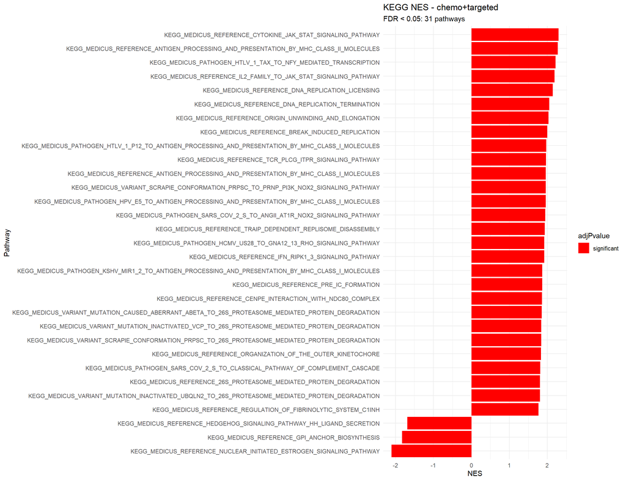

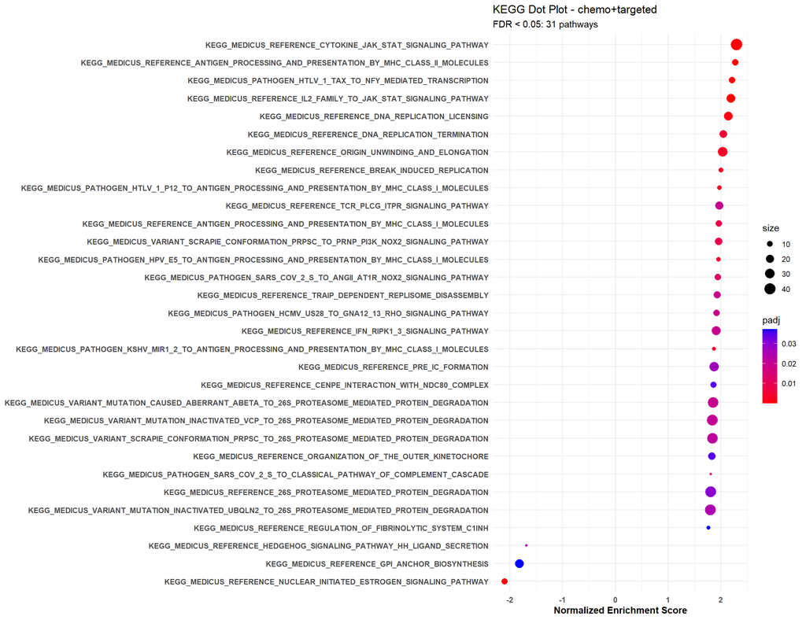

KEGG GSEA results - chemo+targeted

| pathway | pval | padj | log2err | ES | NES | size | leadingEdge | adjPvalue |
| --- | --- | --- | --- | --- | --- | --- | --- | --- |
| KEGG_MEDICUS_REFERENCE_CYTOKINE_JAK_STAT_SIGNALING_PATHWAY | 0.0000000 | 0.0000080 | 0.7195128 | 0.7299846 | 2.2979427 | 44 | IL2RB;STAT1;IL12RB2;IFNG;IL2RG;PIM1;IL7R;IL2RA;IL15;IL15RA;IL23A;JAK3;IL6;IFNGR1;IL6R;IL3RA;STAT5A;IFNAR2;IL7;JAK2;STAT4;STAT2;IL4R;IFNGR2 | significant |
| KEGG_MEDICUS_REFERENCE_ANTIGEN_PROCESSING_AND_PRESENTATION_BY_MHC_CLASS_II_MOLECULES | 0.0000000 | 0.0000006 | 0.8012156 | 0.9426258 | 2.2740171 | 13 | HLA-DRA;HLA-DPA1;HLA-DRB1;HLA-DRB5;HLA-DQA2;CD74;HLA-DMA;HLA-DPB1;HLA-DQA1;HLA-DOB;HLA-DQB1;HLA-DMB;HLA-DOA | significant |
| KEGG_MEDICUS_PATHOGEN_HTLV_1_TAX_TO_NFY_MEDIATED_TRANSCRIPTION | 0.0000000 | 0.0000080 | 0.7195128 | 0.9175572 | 2.2135410 | 13 | HLA-DRA;HLA-DPA1;HLA-DRB1;HLA-DRB5;HLA-DQA2;HLA-DMA;HLA-DPB1;HLA-DQA1;HLA-DOB;HLA-DQB1;HLA-DMB;HLA-DOA | significant |
| KEGG_MEDICUS_REFERENCE_IL2_FAMILY_TO_JAK_STAT_SIGNALING_PATHWAY | 0.0000019 | 0.0002306 | 0.6435518 | 0.7927872 | 2.1868852 | 23 | IL21R;IL2RB;STAT1;IL2RG;IL7R;IL2RA;IL15;IL15RA;JAK3;STAT5A;IL7;IL4R | significant |
| KEGG_MEDICUS_REFERENCE_DNA_REPLICATION_LICENSING | 0.0000110 | 0.0011344 | 0.5933255 | 0.7677257 | 2.1400615 | 24 | CCNE1;CDC45;CDT1;MCM2;MCM5;MCM6;MCM3;MCM4;CCNA2;CCNE2;TICRR;ORC6;MCM7;CDC7;CDC6;ORC3 | significant |
| KEGG_MEDICUS_REFERENCE_DNA_REPLICATION_TERMINATION | 0.0001036 | 0.0053433 | 0.5384341 | 0.7776543 | 2.0494053 | 18 | CDC45;MCM2;MCM5;MCM6;MCM3;MCM4;PIF1;MCM7;VCP;GINS1;GINS2;LRR1;CUL2;GINS3;GINS4 | significant |
| KEGG_MEDICUS_REFERENCE_ORIGIN_UNWINDING_AND_ELONGATION | 0.0000437 | 0.0033836 | 0.5573322 | 0.6958115 | 2.0341128 | 30 | CDC45;MCM10;MCM2;MCM5;MCM6;MCM3;MCM4;RFC4;MCM7;PCNA;WDHD1;PRIM2;RFC2;GINS1;GINS2;POLA2;RFC3;RPA2;RPA1;POLE2;GINS3;GINS4;POLE3 | significant |
| KEGG_MEDICUS_REFERENCE_BREAK_INDUCED_REPLICATION | 0.0000589 | 0.0040528 | 0.5573322 | 0.9201977 | 1.9990453 | 8 | MCM2;MCM5;MCM6;MCM3;MCM4;PIF1;MCM7 | significant |
| KEGG_MEDICUS_PATHOGEN_HTLV_1_P12_TO_ANTIGEN_PROCESSING_AND_PRESENTATION_BY_MHC_CLASS_I_MOLECULES | 0.0000380 | 0.0033615 | 0.5573322 | 0.9402509 | 1.9719918 | 7 | HLA-F;HLA-E;HLA-A;HLA-C;HLA-B;B2M;HLA-G | significant |
| KEGG_MEDICUS_REFERENCE_TCR_PLCG_ITPR_SIGNALING_PATHWAY | 0.0006322 | 0.0195679 | 0.4772708 | 0.7385714 | 1.9675076 | 19 | CD3D;LCK;CD3G;CD247;PLCG2;ZAP70;LCP2;VAV1;LAT;FYN;ITPR3 | significant |
| KEGG_MEDICUS_REFERENCE_ANTIGEN_PROCESSING_AND_PRESENTATION_BY_MHC_CLASS_I_MOLECULES | 0.0001890 | 0.0083561 | 0.5188481 | 0.8322507 | 1.9600001 | 12 | TAP1;HLA-F;HLA-E;HLA-A;HLA-C;HLA-B;B2M;HLA-G;TAP2;CALR;TAPBP | significant |
| KEGG_MEDICUS_VARIANT_SCRAPIE_CONFORMATION_PRPSC_TO_PRNP_PI3K_NOX2_SIGNALING_PATHWAY | 0.0001747 | 0.0083197 | 0.5188481 | 0.7660215 | 1.9581359 | 16 | CYBB;NCF1;NCF2;RAC2;NCF4;FYN;CYBA;PIK3CD | significant |
| KEGG_MEDICUS_PATHOGEN_HPV_E5_TO_ANTIGEN_PROCESSING_AND_PRESENTATION_BY_MHC_CLASS_I_MOLECULES | 0.0000867 | 0.0048813 | 0.5384341 | 0.9322385 | 1.9551876 | 7 | HLA-F;HLA-E;HLA-A;HLA-C;HLA-B;HLA-G | significant |
| KEGG_MEDICUS_PATHOGEN_SARS_COV_2_S_TO_ANGII_AT1R_NOX2_SIGNALING_PATHWAY | 0.0003205 | 0.0132255 | 0.4984931 | 0.8069369 | 1.9466776 | 13 | MMP1;CCL2;MMP3;ACE2;CYBB;IL1B;TNF;IL6 | significant |
| KEGG_MEDICUS_REFERENCE_TRAIP_DEPENDENT_REPLISOME_DISASSEMBLY | 0.0005495 | 0.0188974 | 0.4772708 | 0.7709981 | 1.9306526 | 15 | CDC45;MCM2;MCM5;MCM6;MCM3;MCM4;MCM7;VCP;GINS1;GINS2;GINS3;GINS4 | significant |
| KEGG_MEDICUS_PATHOGEN_HCMV_US28_TO_GNA12_13_RHO_SIGNALING_PATHWAY | 0.0006060 | 0.0195679 | 0.4772708 | 0.7946764 | 1.9170999 | 13 | CCL5;CCL4;CCL2;CCL3;CX3CL1 | significant |
| KEGG_MEDICUS_REFERENCE_IFN_RIPK1_3_SIGNALING_PATHWAY | 0.0005311 | 0.0188974 | 0.4772708 | 0.6731846 | 1.9156471 | 26 | STAT1;IFNG;JAK3;IFNGR1;STAT5A;IFNAR2;JAK2;STAT4;STAT2;IFNGR2 | significant |
| KEGG_MEDICUS_PATHOGEN_KSHV_MIR1_2_TO_ANTIGEN_PROCESSING_AND_PRESENTATION_BY_MHC_CLASS_I_MOLECULES | 0.0000838 | 0.0048813 | 0.5384341 | 0.9401973 | 1.8688570 | 6 | HLA-F;HLA-E;HLA-A;HLA-C;HLA-B;HLA-G | significant |
| KEGG_MEDICUS_REFERENCE_PRE_IC_FORMATION | 0.0011299 | 0.0269011 | 0.4550599 | 0.6584822 | 1.8683005 | 27 | CDC45;CDT1;MCM2;MCM5;MCM6;MCM3;MCM4;TICRR;ORC6;MCM7;CDC6;ORC3;GINS1;GINS2;ORC1;POLE2;GINS3;GINS4;POLE3 | significant |
| KEGG_MEDICUS_REFERENCE_CENPE_INTERACTION_WITH_NDC80_COMPLEX | 0.0016219 | 0.0348122 | 0.4550599 | 0.8025874 | 1.8594021 | 11 | NUF2;NDC80;SPAG5;AURKA;SPC25;AURKB;CENPE;PPP1CB | significant |
| KEGG_MEDICUS_VARIANT_MUTATION_CAUSED_ABERRANT_ABETA_TO_26S_PROTEASOME_MEDIATED_PROTEIN_DEGRADATION | 0.0006711 | 0.0197810 | 0.4772708 | 0.6140080 | 1.8510532 | 35 | PSMD3;PSMB3;PSMB2;PSMD11;APP;PSMD2;PSMA3;PSMB4;PSMB5;PSMA4;PSMC2;PSMD7;PSMD14;ADRM1;PSMA7;PSMC4;PSMB7;PSMD12;PSMB6;PSMD8;PSMA5;PSMB1;PSMC1;PSMA6 | significant |
| KEGG_MEDICUS_VARIANT_MUTATION_INACTIVATED_VCP_TO_26S_PROTEASOME_MEDIATED_PROTEIN_DEGRADATION | 0.0007383 | 0.0207732 | 0.4772708 | 0.5950252 | 1.8419476 | 39 | PSMD3;PSMB3;PSMB2;PSMD11;PSMD2;VCP;PSMA3;PSMB4;PSMB5;PSMA4;PSMC2;PSMD7;PSMD14;ADRM1;PSMA7;PSMC4;PSMB7;PSMD12;PSMB6;PSMD8;PSMA5;PSMB1;PSMC1;PSMA6 | significant |
| KEGG_MEDICUS_VARIANT_SCRAPIE_CONFORMATION_PRPSC_TO_26S_PROTEASOME_MEDIATED_PROTEIN_DEGRADATION | 0.0008213 | 0.0221025 | 0.4772708 | 0.6106846 | 1.8410343 | 35 | PSMD3;PSMB3;PSMB2;PSMD11;PSMD2;PSMA3;PSMB4;PSMB5;PSMA4;PSMC2;PSMD7;PSMD14;ADRM1;PSMA7;PSMC4;PSMB7;PSMD12;PSMB6;PSMD8;PSMA5;PRNP;PSMB1;PSMC1;PSMA6 | significant |
| KEGG_MEDICUS_PATHOGEN_HTLV_1_P12_TO_JAK_STAT_SIGNALING_PATHWAY | 0.0030711 | 0.0569475 | 0.4317077 | 0.8738290 | 1.8326850 | 7 | IL2RB;IL2RG;JAK3;STAT5A | non-significant |
| KEGG_MEDICUS_REFERENCE_ORGANIZATION_OF_THE_OUTER_KINETOCHORE | 0.0016309 | 0.0348122 | 0.4550599 | 0.7158902 | 1.8299880 | 16 | CENPW;NUF2;NDC80;CDCA8;BIRC5;SPC25;INCENP;AURKB;ZWINT;PMF1 | significant |
| KEGG_MEDICUS_REFERENCE_NON_CANONICAL_INFLAMMASOME_SIGNALING_PATHWAY | 0.0039005 | 0.0670664 | 0.4317077 | 0.8639833 | 1.8120356 | 7 | CASP1;IL1B;CASP5;CASP4;IL18;NLRP3 | non-significant |
| KEGG_MEDICUS_PATHOGEN_SARS_COV_2_S_TO_CLASSICAL_PATHWAY_OF_COMPLEMENT_CASCADE | 0.0003553 | 0.0137469 | 0.4984931 | 0.9482385 | 1.8110520 | 5 | C1QB;C1QA;C1QC;C1S;C1R | significant |
| KEGG_MEDICUS_REFERENCE_26S_PROTEASOME_MEDIATED_PROTEIN_DEGRADATION | 0.0013138 | 0.0301194 | 0.4550599 | 0.5898594 | 1.8072751 | 38 | PSMD3;PSMB3;PSMB2;PSMD11;PSMD2;PSMA3;PSMB4;PSMB5;PSMA4;PSMC2;PSMD7;PSMD14;ADRM1;PSMA7;PSMC4;PSMB7;PSMD12;PSMB6;PSMD8;PSMA5;PSMB1;PSMC1;PSMA6 | significant |
| KEGG_MEDICUS_VARIANT_MUTATION_INACTIVATED_UBQLN2_TO_26S_PROTEASOME_MEDIATED_PROTEIN_DEGRADATION | 0.0009924 | 0.0245724 | 0.4550599 | 0.5830043 | 1.8047360 | 39 | PSMD3;PSMB3;PSMB2;PSMD11;PSMD2;PSMA3;PSMB4;PSMB5;PSMA4;PSMC2;PSMD7;PSMD14;ADRM1;PSMA7;PSMC4;PSMB7;PSMD12;PSMB6;PSMD8;PSMA5;PSMB1;PSMC1;PSMA6 | significant |
| KEGG_MEDICUS_PATHOGEN_ESCHERICHIA_EAE_TIR_TO_ACTIN_SIGNALING_PATHWAY | 0.0038722 | 0.0670664 | 0.4317077 | 0.6930733 | 1.7985329 | 17 | WIPF1;ACTR3;ARPC5L;NCK1;ARPC1B;ACTR2;ACTB;NCK2;WIPF2;ARPC2;ARPC5;WIPF3;ARPC4 | non-significant |

[output cut: 589 more lines]

#### Over-Representation Analysis (per-treatment)

```r
ora_hallmark_result_list <- list()
ora_keggmed_result_list <- list()

for (treatment in sub_treat) {
  message("Running ORA for: ", treatment)

  top_treat <- top_table_list[[treatment]]
  deGenes <- rownames(top_treat)[top_treat$pval < 0.05]
  geneUniverse <- rownames(expr_data)

  # ORA Hallmark
  oraHallmark <- fora(pathways = pathwaysH, genes = deGenes, universe = geneUniverse, minSize = 15, maxSize = 500)
  oraHallmark$Pathway_Set <- "Hallmark"
  oraHallmark$Significance <- ifelse(oraHallmark$pval < 0.05, "Significant", "Not Significant")
  oraHallmark$Treatment <- treatment
  ora_hallmark_result_list[[treatment]] <- oraHallmark

  # ORA KEGG_MEDICUS
  oraKeggMed <- fora(pathways = pathwaysKEGG_MED, genes = deGenes, universe = geneUniverse, minSize = 15, maxSize = 500)
  oraKeggMed$Pathway_Set <- "KEGG_MEDICUS"
  oraKeggMed$Significance <- ifelse(oraKeggMed$pval < 0.05, "Significant", "Not Significant")
  oraKeggMed$Treatment <- treatment
  ora_keggmed_result_list[[treatment]] <- oraKeggMed

  # Save
  write.table(transform(oraHallmark, overlapGenes = sapply(overlapGenes, paste, collapse = ",")),
    file = file.path(output_dir, "pathway_analysis", paste0(gsub("\\+", "_", treatment), "_Hallmark_ORA.tsv")),
    sep = "\t", row.names = FALSE, quote = FALSE)

  write.table(transform(oraKeggMed, overlapGenes = sapply(overlapGenes, paste, collapse = ",")),
    file = file.path(output_dir, "pathway_analysis", paste0(gsub("\\+", "_", treatment), "_KeggMed_ORA.tsv")),
    sep = "\t", row.names = FALSE, quote = FALSE)

  print(kable(head(oraHallmark, 10), caption = paste("Top Hallmark ORA -", treatment)) %>%
    kable_styling(bootstrap_options = c("striped", "hover", "condensed"), full_width = FALSE))
}
```

Top Hallmark ORA - IO+chemo

| pathway | pval | padj | overlap | size | overlapGenes | Pathway_Set | Significance | Treatment |
| --- | --- | --- | --- | --- | --- | --- | --- | --- |
| HALLMARK_ADIPOGENESIS | 1 | 1 | 0 | 192 |  | Hallmark | Not Significant | IO+chemo |
| HALLMARK_ALLOGRAFT_REJECTION | 1 | 1 | 0 | 195 |  | Hallmark | Not Significant | IO+chemo |
| HALLMARK_ANDROGEN_RESPONSE | 1 | 1 | 0 | 96 |  | Hallmark | Not Significant | IO+chemo |
| HALLMARK_ANGIOGENESIS | 1 | 1 | 0 | 36 |  | Hallmark | Not Significant | IO+chemo |
| HALLMARK_APICAL_JUNCTION | 1 | 1 | 0 | 190 |  | Hallmark | Not Significant | IO+chemo |
| HALLMARK_APICAL_SURFACE | 1 | 1 | 0 | 43 |  | Hallmark | Not Significant | IO+chemo |
| HALLMARK_APOPTOSIS | 1 | 1 | 0 | 159 |  | Hallmark | Not Significant | IO+chemo |
| HALLMARK_BILE_ACID_METABOLISM | 1 | 1 | 0 | 112 |  | Hallmark | Not Significant | IO+chemo |
| HALLMARK_CHOLESTEROL_HOMEOSTASIS | 1 | 1 | 0 | 72 |  | Hallmark | Not Significant | IO+chemo |
| HALLMARK_COAGULATION | 1 | 1 | 0 | 137 |  | Hallmark | Not Significant | IO+chemo |

Top Hallmark ORA - targeted

| pathway | pval | padj | overlap | size | overlapGenes | Pathway_Set | Significance | Treatment |
| --- | --- | --- | --- | --- | --- | --- | --- | --- |
| HALLMARK_ADIPOGENESIS | 1 | 1 | 0 | 192 |  | Hallmark | Not Significant | targeted |
| HALLMARK_ALLOGRAFT_REJECTION | 1 | 1 | 0 | 195 |  | Hallmark | Not Significant | targeted |
| HALLMARK_ANDROGEN_RESPONSE | 1 | 1 | 0 | 96 |  | Hallmark | Not Significant | targeted |
| HALLMARK_ANGIOGENESIS | 1 | 1 | 0 | 36 |  | Hallmark | Not Significant | targeted |
| HALLMARK_APICAL_JUNCTION | 1 | 1 | 0 | 190 |  | Hallmark | Not Significant | targeted |
| HALLMARK_APICAL_SURFACE | 1 | 1 | 0 | 43 |  | Hallmark | Not Significant | targeted |
| HALLMARK_APOPTOSIS | 1 | 1 | 0 | 159 |  | Hallmark | Not Significant | targeted |
| HALLMARK_BILE_ACID_METABOLISM | 1 | 1 | 0 | 112 |  | Hallmark | Not Significant | targeted |
| HALLMARK_CHOLESTEROL_HOMEOSTASIS | 1 | 1 | 0 | 72 |  | Hallmark | Not Significant | targeted |
| HALLMARK_COAGULATION | 1 | 1 | 0 | 137 |  | Hallmark | Not Significant | targeted |

Top Hallmark ORA - chemo+targeted

| pathway | pval | padj | overlap | size | overlapGenes | Pathway_Set | Significance | Treatment |
| --- | --- | --- | --- | --- | --- | --- | --- | --- |
| HALLMARK_ADIPOGENESIS | 1 | 1 | 0 | 192 |  | Hallmark | Not Significant | chemo+targeted |
| HALLMARK_ALLOGRAFT_REJECTION | 1 | 1 | 0 | 195 |  | Hallmark | Not Significant | chemo+targeted |
| HALLMARK_ANDROGEN_RESPONSE | 1 | 1 | 0 | 96 |  | Hallmark | Not Significant | chemo+targeted |
| HALLMARK_ANGIOGENESIS | 1 | 1 | 0 | 36 |  | Hallmark | Not Significant | chemo+targeted |
| HALLMARK_APICAL_JUNCTION | 1 | 1 | 0 | 190 |  | Hallmark | Not Significant | chemo+targeted |
| HALLMARK_APICAL_SURFACE | 1 | 1 | 0 | 43 |  | Hallmark | Not Significant | chemo+targeted |
| HALLMARK_APOPTOSIS | 1 | 1 | 0 | 159 |  | Hallmark | Not Significant | chemo+targeted |
| HALLMARK_BILE_ACID_METABOLISM | 1 | 1 | 0 | 112 |  | Hallmark | Not Significant | chemo+targeted |
| HALLMARK_CHOLESTEROL_HOMEOSTASIS | 1 | 1 | 0 | 72 |  | Hallmark | Not Significant | chemo+targeted |
| HALLMARK_COAGULATION | 1 | 1 | 0 | 137 |  | Hallmark | Not Significant | chemo+targeted |

### 8. Gene–Response Correlation

**Candidate genes from two sources:**

**1. DE Significant Genes (from Section 6):** * **IO+Chemo:** 47 genes at |logFC| ≥ 1.5 (143 at |logFC| ≥ 1.0) * **Targeted:** 3 genes at |logFC| ≥ 1.5 (5 at |logFC| ≥ 1.0) * Gene-response correlation uses the broader |logFC| ≥ 1.0 list to capture moderate but real effects

**2. Key Biological Candidates (from literature):** * **Immune:** CD8A, CD8B, PDCD1 (PD-1), CD274 (PD-L1), IFNG, GZMB, PRF1, CXCL9 * **Luminal/Resistance:** ESR1, PGR, ERBB2

> **Note:** CD8A/CD8B were selected based on [Sun et al. (PMID: 30120041)](https://pubmed.ncbi.nlm.nih.gov/30120041/), which used CD8B to build a radiomic-immune signature linking CT features to CD8 cell infiltration. PDCD1/CD274 are the direct targets of the IO drugs (pembrolizumab) used in I-SPY2. ESR1/PGR/ERBB2 connect to the estrogen response and HER2 pathways identified in Sections 5–7.

**PredictIO Signatures (from Section 3):** * 55 curated immune-oncology RNA signatures — used as **validation only** * Not included as candidate source (derived from other studies/cancers) * Used to check: do known IO signatures overlap with our DE-derived candidates?

```r
# DE genes at |logFC| >= 1.0 from IO+chemo and targeted
de_genes_fc1 <- c()
for (treatment in c("IO+chemo", "targeted")) {
  tt <- top_table_list[[treatment]]
  genes <- rownames(tt)[tt$adj.P.Val < p_cutoff & abs(tt$logFC) >= 1.0]
  de_genes_fc1 <- c(de_genes_fc1, genes)
}
de_genes_fc1 <- unique(de_genes_fc1)

#  Literature genes
literature_genes <- c("CD8A", "CD8B", "PDCD1", "CD274", "IFNG", "GZMB", "PRF1",
                       "CXCL9", "ESR1", "PGR", "ERBB2")

# Combine
candidate_genes <- unique(c(de_genes_fc1, literature_genes))
candidate_genes <- candidate_genes[candidate_genes %in% rownames(expr_data)]

cat("Candidate genes:\n")
```

Candidate genes:

```r
cat("  DE |logFC| >= 1.5 (IO+chemo + targeted):",
    length(unique(c(sig_gene_list[["IO+chemo"]], sig_gene_list[["targeted"]]))), "\n")
```

DE |logFC| >= 1.5 (IO+chemo + targeted): 50

```r
cat("  DE |logFC| >= 1.0 (IO+chemo + targeted):", length(de_genes_fc1), "\n")
```

DE |logFC| >= 1.0 (IO+chemo + targeted): 147

```r
cat("  Literature:", length(literature_genes), "\n")
```

Literature: 11

```r
cat("  Total unique:", length(candidate_genes), "\n")
```

Total unique: 154

```r
# Source tracking table
source_df <- data.frame(
  Gene = candidate_genes,
  DE_FC1.5 = ifelse(candidate_genes %in% unique(c(sig_gene_list[["IO+chemo"]], sig_gene_list[["targeted"]])), "Yes", ""),
  DE_FC1.0 = ifelse(candidate_genes %in% de_genes_fc1, "Yes", ""),
  Literature = ifelse(candidate_genes %in% literature_genes, "Yes", ""),
  stringsAsFactors = FALSE
)
source_df <- source_df[order(source_df$DE_FC1.5, decreasing = TRUE), ]

kable(source_df, caption = "Candidate Gene Sources (|logFC| >= 1.0 for correlation)",
      row.names = FALSE) %>%
  kable_styling(bootstrap_options = c("striped", "hover", "condensed"), full_width = FALSE) %>%
  scroll_box(height = "400px")
```

Candidate Gene Sources (|logFC| >= 1.0 for correlation)

| Gene | DE_FC1.5 | DE_FC1.0 | Literature |
| --- | --- | --- | --- |
| CA12 | Yes | Yes |  |
| SLC7A2 | Yes | Yes |  |
| LAMP3 | Yes | Yes |  |
| CCDC74B | Yes | Yes |  |
| CCL13 | Yes | Yes |  |
| ACOX2 | Yes | Yes |  |
| AGR2 | Yes | Yes |  |
| SCUBE2 | Yes | Yes |  |
| GDF15 | Yes | Yes |  |
| CRABP1 | Yes | Yes |  |
| TNNT1 | Yes | Yes |  |
| ELF5 | Yes | Yes |  |
| ANXA9 | Yes | Yes |  |
| AGR3 | Yes | Yes |  |
| ROPN1 | Yes | Yes |  |
| IDO1 | Yes | Yes |  |
| FOXA1 | Yes | Yes |  |
| PROM1 | Yes | Yes |  |
| TFF1 | Yes | Yes |  |
| TFF3 | Yes | Yes |  |
| DYNLRB2 | Yes | Yes |  |
| CHI3L1 | Yes | Yes |  |
| DNALI1 | Yes | Yes |  |
| FSIP1 | Yes | Yes |  |
| DHRS2 | Yes | Yes |  |
| CLSTN2 | Yes | Yes |  |
| EEF1A2 | Yes | Yes |  |
| CHI3L2 | Yes | Yes |  |
| KRT23 | Yes | Yes |  |
| GABRP | Yes | Yes |  |

[output cut: 124 more lines]

```r
write.csv(source_df,
          file = file.path(output_dir, "DEG_analysis", "candidate_gene_sources.csv"),
          row.names = FALSE)
```

#### Step 1: Single Gene–Response Correlation

Test each candidate gene individually using Wilcoxon rank-sum test (R vs NR) per treatment arm.

```r
results <- list()
for (treat in sub_treat) {
  clin_sub <- clin_data[clin_data$treatment == treat, ]
  ids <- clin_sub$patientid[clin_sub$patientid %in% colnames(expr_data)]

  for (gene in candidate_genes) {
    expr_vals <- as.numeric(expr_data[gene, ids])
    response <- clin_sub$response[clin_sub$patientid %in% ids]

    wt <- wilcox.test(expr_vals ~ response)

    results[[paste(treat, gene)]] <- data.frame(
      Treatment = treat,
      Gene = gene,
      p_value = wt$p.value,
      mean_R = mean(expr_vals[response == "R"], na.rm = TRUE),
      mean_NR = mean(expr_vals[response == "NR"], na.rm = TRUE)
    )
  }
}

gene_response_df <- do.call(rbind, results)
gene_response_df$FDR <- p.adjust(gene_response_df$p_value, method = "BH")
gene_response_df$Direction <- ifelse(gene_response_df$mean_R > gene_response_df$mean_NR, "Up in R", "Up in NR")
gene_response_df <- gene_response_df[order(gene_response_df$p_value), ]

kable(gene_response_df, caption = "Gene-Response Correlation (Single Genes)") %>%
  kable_styling(bootstrap_options = c("striped", "hover", "condensed"), full_width = FALSE) %>%
  scroll_box(height = "400px")
```

Gene-Response Correlation (Single Genes)

|  | Treatment | Gene | p_value | mean_R | mean_NR | FDR | Direction |
| --- | --- | --- | --- | --- | --- | --- | --- |
| chemo+targeted CD38 | chemo+targeted | CD38 | 0.0000000 | 8.626720 | 7.693851 | 0.0000000 | Up in R |
| chemo+targeted ESR1 | chemo+targeted | ESR1 | 0.0000000 | 6.478895 | 7.302788 | 0.0000000 | Up in NR |
| chemo+targeted IL21R | chemo+targeted | IL21R | 0.0000000 | 9.102143 | 8.440971 | 0.0000000 | Up in R |
| chemo+targeted THSD4 | chemo+targeted | THSD4 | 0.0000000 | 6.711464 | 7.468924 | 0.0000000 | Up in NR |
| chemo+targeted SLC39A6 | chemo+targeted | SLC39A6 | 0.0000000 | 8.542672 | 9.382781 | 0.0000000 | Up in NR |
| chemo+targeted GZMB | chemo+targeted | GZMB | 0.0000000 | 10.217086 | 9.327281 | 0.0000000 | Up in R |
| chemo+targeted GBP5 | chemo+targeted | GBP5 | 0.0000000 | 11.568002 | 10.623954 | 0.0000000 | Up in R |
| chemo+targeted CCDC74B | chemo+targeted | CCDC74B | 0.0000000 | 8.231734 | 9.115383 | 0.0000000 | Up in NR |
| chemo+targeted FAM134B | chemo+targeted | FAM134B | 0.0000000 | 7.951646 | 8.655580 | 0.0000000 | Up in NR |
| chemo+targeted SCUBE2 | chemo+targeted | SCUBE2 | 0.0000000 | 7.266232 | 8.462953 | 0.0000000 | Up in NR |
| chemo+targeted AIM2 | chemo+targeted | AIM2 | 0.0000000 | 8.234938 | 7.553594 | 0.0000000 | Up in R |
| chemo+targeted CXCL13 | chemo+targeted | CXCL13 | 0.0000000 | 9.582859 | 8.575685 | 0.0000000 | Up in R |
| chemo+targeted GBP1 | chemo+targeted | GBP1 | 0.0000000 | 9.581483 | 8.906429 | 0.0000000 | Up in R |
| chemo+targeted KRT86 | chemo+targeted | KRT86 | 0.0000000 | 10.202575 | 9.351593 | 0.0000000 | Up in R |
| chemo+targeted IDO1 | chemo+targeted | IDO1 | 0.0000000 | 10.436543 | 9.433527 | 0.0000000 | Up in R |
| chemo+targeted AGR3 | chemo+targeted | AGR3 | 0.0000000 | 6.973243 | 8.480884 | 0.0000000 | Up in NR |
| chemo+targeted SYBU | chemo+targeted | SYBU | 0.0000000 | 7.594053 | 8.246913 | 0.0000000 | Up in NR |
| chemo+targeted RARRES1 | chemo+targeted | RARRES1 | 0.0000000 | 9.920445 | 9.034819 | 0.0000000 | Up in R |
| chemo+targeted FAM26F | chemo+targeted | FAM26F | 0.0000000 | 11.281237 | 10.605040 | 0.0000000 | Up in R |
| chemo+targeted LRRC56 | chemo+targeted | LRRC56 | 0.0000000 | 8.544549 | 9.135867 | 0.0000000 | Up in NR |
| chemo+targeted LAMP3 | chemo+targeted | LAMP3 | 0.0000000 | 10.428633 | 9.594847 | 0.0000000 | Up in R |
| chemo+targeted CXCL9 | chemo+targeted | CXCL9 | 0.0000000 | 12.761833 | 11.674756 | 0.0000000 | Up in R |
| chemo+targeted CCL13 | chemo+targeted | CCL13 | 0.0000000 | 8.385530 | 7.579823 | 0.0000000 | Up in R |
| chemo+targeted CXCL10 | chemo+targeted | CXCL10 | 0.0000000 | 9.878068 | 9.113205 | 0.0000000 | Up in R |
| chemo+targeted CA12 | chemo+targeted | CA12 | 0.0000000 | 8.035553 | 9.054387 | 0.0000000 | Up in NR |
| chemo+targeted PDCD1 | chemo+targeted | PDCD1 | 0.0000000 | 9.150812 | 8.566047 | 0.0000000 | Up in R |
| chemo+targeted PARD6B | chemo+targeted | PARD6B | 0.0000000 | 8.559800 | 9.257023 | 0.0000000 | Up in NR |
| chemo+targeted GATA3 | chemo+targeted | GATA3 | 0.0000000 | 9.247310 | 10.258508 | 0.0000000 | Up in NR |
| chemo+targeted NAT1 | chemo+targeted | NAT1 | 0.0000000 | 8.607942 | 9.659987 | 0.0000000 | Up in NR |
| chemo+targeted LONRF2 | chemo+targeted | LONRF2 | 0.0000000 | 6.650446 | 7.365533 | 0.0000000 | Up in NR |

[output cut: 432 more lines]

```r
write.csv(gene_response_df,
          file = file.path(output_dir, "DEG_analysis", "gene_response_correlation.csv"),
          row.names = FALSE)
```